# Project: Wrangle and Analyze WeRateDogs Twitter Data

The aim of this project is to study and analyze the WeRateDogs Twitter account by gathering different features from multiple sources, then assess at least 8 quality issues and 2 tidiness issues and clean them. Afterwards, the data will be analyzed to produce at least 3 insights and illustrations.

## Gather Datasets

```python
# Load required libraries
import pandas as pd
import numpy as np
import matplotlib.pyplot as plt
import matplotlib.dates as mdates
import seaborn as sns
import time
import requests
import tweepy
import json
from IPython.display import Image
from IPython.core.display import HTML
```

### Enhanced WeRateDogs Twitter Archive Dataset

An enhanced version of WeRateDogs Twitter Archive data was provided as csv file. The file will be read locally and stored as a data frame 'df_archive'.

```python
# Load WeRateDogs Twitter archive
df_archive = pd.read_csv('twitter-archive-enhanced.csv')
```

The first few records are displayed along with structure information.

```python
# display full text columns
pd.set_option('display.max_colwidth', -1)

#View first few records
df_archive.head()
```

|  | tweet_id | in_reply_to_status_id | in_reply_to_user_id | timestamp | source | text | retweeted_status_id | retweeted_status_user_id | retweeted_status_timestamp | expanded_urls | rating_numerator | rating_denominator | name | doggo | floofer | pupper | puppo |
| --- | --- | --- | --- | --- | --- | --- | --- | --- | --- | --- | --- | --- | --- | --- | --- | --- | --- |
| 0 | 892420643555336193 | NaN | NaN | 2017-08-01 16:23:56 +0000 | <a href="http://twitter.com/download/iphone" rel="nofollow">Twitter for iPhone</a> | This is Phineas. He's a mystical boy. Only ever appears in the hole of a donut. 13/10 https://t.co/MgUWQ76dJU | NaN | NaN | NaN | https://twitter.com/dog_rates/status/892420643555336193/photo/1 | 13 | 10 | Phineas | None | None | None | None |
| 1 | 892177421306343426 | NaN | NaN | 2017-08-01 00:17:27 +0000 | <a href="http://twitter.com/download/iphone" rel="nofollow">Twitter for iPhone</a> | This is Tilly. She's just checking pup on you. Hopes you're doing ok. If not, she's available for pats, snugs, boops, the whole bit. 13/10 https://t.co/0Xxu71qeIV | NaN | NaN | NaN | https://twitter.com/dog_rates/status/892177421306343426/photo/1 | 13 | 10 | Tilly | None | None | None | None |
| 2 | 891815181378084864 | NaN | NaN | 2017-07-31 00:18:03 +0000 | <a href="http://twitter.com/download/iphone" rel="nofollow">Twitter for iPhone</a> | This is Archie. He is a rare Norwegian Pouncing Corgo. Lives in the tall grass. You never know when one may strike. 12/10 https://t.co/wUnZnhtVJB | NaN | NaN | NaN | https://twitter.com/dog_rates/status/891815181378084864/photo/1 | 12 | 10 | Archie | None | None | None | None |
| 3 | 891689557279858688 | NaN | NaN | 2017-07-30 15:58:51 +0000 | <a href="http://twitter.com/download/iphone" rel="nofollow">Twitter for iPhone</a> | This is Darla. She commenced a snooze mid meal. 13/10 happens to the best of us https://t.co/tD36da7qLQ | NaN | NaN | NaN | https://twitter.com/dog_rates/status/891689557279858688/photo/1 | 13 | 10 | Darla | None | None | None | None |
| 4 | 891327558926688256 | NaN | NaN | 2017-07-29 16:00:24 +0000 | <a href="http://twitter.com/download/iphone" rel="nofollow">Twitter for iPhone</a> | This is Franklin. He would like you to stop calling him "cute." He is a very fierce shark and should be respected as such. 12/10 #BarkWeek https://t.co/AtUZn91f7f | NaN | NaN | NaN | https://twitter.com/dog_rates/status/891327558926688256/photo/1,https://twitter.com/dog_rates/status/891327558926688256/photo/1 | 12 | 10 | Franklin | None | None | None | None |

```python
df_archive.info()
```

```
<class 'pandas.core.frame.DataFrame'>
RangeIndex: 2356 entries, 0 to 2355
Data columns (total 17 columns):
tweet_id                      2356 non-null int64
in_reply_to_status_id         78 non-null float64
in_reply_to_user_id           78 non-null float64
timestamp                     2356 non-null object
source                        2356 non-null object
text                          2356 non-null object
retweeted_status_id           181 non-null float64
retweeted_status_user_id      181 non-null float64
retweeted_status_timestamp    181 non-null object
expanded_urls                 2297 non-null object
rating_numerator              2356 non-null int64
rating_denominator            2356 non-null int64
name                          2356 non-null object
doggo                         2356 non-null object
floofer                       2356 non-null object
pupper                        2356 non-null object
puppo                         2356 non-null object
dtypes: float64(4), int64(3), object(10)
memory usage: 313.0+ KB
```

### The Tweet Image Predictions Dataset

This dataset has what breed of dog (or another object, animal, etc.) is present in each tweet according to a neural network. The file is stored in Udacity's server as tsv file. The file will be downloaded programmatically and saved locally for further analysis.

```python
# Download image predictions from a url
url = 'https://d17h27t6h515a5.cloudfront.net/topher/2017/August/599fd2ad_image-predictions/image-predictions.tsv'
response = requests.get(url)
```

```python
# Save remote tsv file locally
with open("image-predictions.tsv",mode='wb') as file:
    file.write(response.content)

# Read image predictions from the local tsv file
df_predictions = pd.read_csv('image-predictions.tsv', sep='\t')
```

The first few records are displayed along with structure information.

```python
#View first few records
df_predictions.head()
```

|  | tweet_id | jpg_url | img_num | p1 | p1_conf | p1_dog | p2 | p2_conf | p2_dog | p3 | p3_conf | p3_dog |
| --- | --- | --- | --- | --- | --- | --- | --- | --- | --- | --- | --- | --- |
| 0 | 666020888022790149 | https://pbs.twimg.com/media/CT4udn0WwAA0aMy.jpg | 1 | Welsh_springer_spaniel | 0.465074 | True | collie | 0.156665 | True | Shetland_sheepdog | 0.061428 | True |
| 1 | 666029285002620928 | https://pbs.twimg.com/media/CT42GRgUYAA5iDo.jpg | 1 | redbone | 0.506826 | True | miniature_pinscher | 0.074192 | True | Rhodesian_ridgeback | 0.072010 | True |
| 2 | 666033412701032449 | https://pbs.twimg.com/media/CT4521TWwAEvMyu.jpg | 1 | German_shepherd | 0.596461 | True | malinois | 0.138584 | True | bloodhound | 0.116197 | True |
| 3 | 666044226329800704 | https://pbs.twimg.com/media/CT5Dr8HUEAA-lEu.jpg | 1 | Rhodesian_ridgeback | 0.408143 | True | redbone | 0.360687 | True | miniature_pinscher | 0.222752 | True |
| 4 | 666049248165822465 | https://pbs.twimg.com/media/CT5IQmsXIAAKY4A.jpg | 1 | miniature_pinscher | 0.560311 | True | Rottweiler | 0.243682 | True | Doberman | 0.154629 | True |

```python
df_predictions.info()
```

```
<class 'pandas.core.frame.DataFrame'>
RangeIndex: 2075 entries, 0 to 2074
Data columns (total 12 columns):
tweet_id    2075 non-null int64
jpg_url     2075 non-null object
img_num     2075 non-null int64
p1          2075 non-null object
p1_conf     2075 non-null float64
p1_dog      2075 non-null bool
p2          2075 non-null object
p2_conf     2075 non-null float64
p2_dog      2075 non-null bool
p3          2075 non-null object
p3_conf     2075 non-null float64
p3_dog      2075 non-null bool
dtypes: bool(3), float64(3), int64(2), object(4)
memory usage: 152.1+ KB
```

### Extra Tweet Information Dataset

Extra tweet's features such as retweet count and favorite ("like") count are fetched from Twitter using an API for each tweet ID in the WeRateDogs Twitter archive. Then, the data will be stored locally as txt file to be wrangled and analyzed later.

**Notes:**

- The Twitter API keys, secrets, and tokens in this project are omitted.

- The dataset is fetched and saved locally as 'tweet_json.txt' for convenience.

- Please use your own keys to fetch required data again using python Tweepy API (code provided below, commented)

```python
# # Replace with your own key, token and secret values
# # Create an app in https://apps.twitter.com/app/
# # Reference: http://tweepy.readthedocs.io/en/v3.5.0/auth_tutorial.html
# consumer_key = ''
# consumer_secret = ''
# access_token = ''
# access_token_secret = ''

# # configration
# auth = tweepy.OAuthHandler(consumer_key, consumer_secret)
# auth.set_access_token(access_token, access_token_secret)
# api = tweepy.API(auth) #, parser = tweepy.parsers.JSONParser(), wait_on_rate_limit = True, wait_on_rate_limit_notify = True)

# # For loop which will add each available tweet to a new line of tweet_json.txt
# tic = time.time()
# with open('tweet_json.txt', 'a', encoding='utf8') as f:
#     for tweet_id in df_archive['tweet_id']:
#         try:
#             tweet = api.get_status(tweet_id, tweet_mode='extended')
#             json.dump(tweet._json, f)
#             f.write('\n')
#         except:
#             continue
# toc = time.time()
# print(toc - tic, ' seconds')
# #2278.305524110794  seconds (best)
```

```python
# For loop to append each tweet in 'tweet_json.txt' into a list 'list_json_tweets'
tic = time.time()
list_json_tweets = []

tweet_file = open('tweet_json.txt', "r")

for line in tweet_file:
    try:
        tweet = json.loads(line)
        list_json_tweets.append(tweet)
    except:
        continue

tweet_file.close()

toc = time.time()
print(toc - tic, ' seconds')
# 0.4938828945159912  seconds
```

```
2.7797436714172363  seconds
```

```python
#Take a look at first tweet json structure
list_json_tweets[0].keys()
```

```
dict_keys(['created_at', 'id', 'id_str', 'full_text', 'truncated', 'display_text_range', 'entities', 'extended_entities', 'source', 'in_reply_to_status_id', 'in_reply_to_status_id_str', 'in_reply_to_user_id', 'in_reply_to_user_id_str', 'in_reply_to_screen_name', 'user', 'geo', 'coordinates', 'place'…
```

```python
# Construct df_info dataframe that includes: tweet id, retweet_count, favorite_count
df_info = pd.DataFrame()
df_info['tweet_id'] = list(map(lambda tweet: tweet['id'], list_json_tweets))
df_info['retweet_count'] = list(map(lambda tweet: tweet['retweet_count'], list_json_tweets))
df_info['favorite_count'] = list(map(lambda tweet: tweet['favorite_count'], list_json_tweets))

# View first few tweets
df_info.head()
```

|  | tweet_id | retweet_count | favorite_count |
| --- | --- | --- | --- |
| 0 | 892420643555336193 | 8640 | 38962 |
| 1 | 892177421306343426 | 6347 | 33352 |
| 2 | 891815181378084864 | 4212 | 25138 |
| 3 | 891689557279858688 | 8758 | 42296 |
| 4 | 891327558926688256 | 9520 | 40463 |

```python
# View df_info structure
df_info.info()
```

```
<class 'pandas.core.frame.DataFrame'>
RangeIndex: 2345 entries, 0 to 2344
Data columns (total 3 columns):
tweet_id          2345 non-null int64
retweet_count     2345 non-null int64
favorite_count    2345 non-null int64
dtypes: int64(3)
memory usage: 55.0 KB
```

```python
# some statistics of df_info dataset
df_info.describe()
```

|  | tweet_id | retweet_count | favorite_count |
| --- | --- | --- | --- |
| count | 2.345000e+03 | 2345.000000 | 2345.000000 |
| mean | 7.422940e+17 | 3041.879744 | 8096.715565 |
| std | 6.833642e+16 | 5057.312067 | 12179.304482 |
| min | 6.660209e+17 | 0.000000 | 0.000000 |
| 25% | 6.783802e+17 | 609.000000 | 1407.000000 |
| 50% | 7.189392e+17 | 1423.000000 | 3549.000000 |
| 75% | 7.986979e+17 | 3546.000000 | 10012.000000 |
| max | 8.924206e+17 | 77712.000000 | 143931.000000 |

## Assess Datasets

There are three data sets to be assessed based on quality and tidiness:

- df_archive: The WeRateDogs Twitter archive
- df_predictions: The tweet image predictions, i.e., what breed of dog (or another object, animal, etc.) is present in each tweet according to a neural network.
- df_info: Each tweet's retweet count and favorite ("like") count

Each dataset will be assessed visually and programmatically as follows:

### Assessment of Enhanced WeRateDogs Twitter Archive Dataset

The data have 2356 rows and 17 columns. The timestamp column have wrong data type. Also, there are some columns that are not of interest.

```python
#More information about structure
df_archive.info()
```

```
<class 'pandas.core.frame.DataFrame'>
RangeIndex: 2356 entries, 0 to 2355
Data columns (total 17 columns):
tweet_id                      2356 non-null int64
in_reply_to_status_id         78 non-null float64
in_reply_to_user_id           78 non-null float64
timestamp                     2356 non-null object
source                        2356 non-null object
text                          2356 non-null object
retweeted_status_id           181 non-null float64
retweeted_status_user_id      181 non-null float64
retweeted_status_timestamp    181 non-null object
expanded_urls                 2297 non-null object
rating_numerator              2356 non-null int64
rating_denominator            2356 non-null int64
name                          2356 non-null object
doggo                         2356 non-null object
floofer                       2356 non-null object
pupper                        2356 non-null object
puppo                         2356 non-null object
dtypes: float64(4), int64(3), object(10)
memory usage: 313.0+ KB
```

Below, we see that there is a tidiness issue on how dog stages were separated into unnecessary four columns: doggo, floofer, pupper and puppo.

```python
#Visually explore first 20 records
df_archive.head(20)
```

|  | tweet_id | in_reply_to_status_id | in_reply_to_user_id | timestamp | source | text | retweeted_status_id | retweeted_status_user_id | retweeted_status_timestamp | expanded_urls | rating_numerator | rating_denominator | name | doggo | floofer | pupper | puppo |
| --- | --- | --- | --- | --- | --- | --- | --- | --- | --- | --- | --- | --- | --- | --- | --- | --- | --- |
| 0 | 892420643555336193 | NaN | NaN | 2017-08-01 16:23:56 +0000 | <a href="http://twitter.com/download/iphone" rel="nofollow">Twitter for iPhone</a> | This is Phineas. He's a mystical boy. Only ever appears in the hole of a donut. 13/10 https://t.co/MgUWQ76dJU | NaN | NaN | NaN | https://twitter.com/dog_rates/status/892420643555336193/photo/1 | 13 | 10 | Phineas | None | None | None | None |
| 1 | 892177421306343426 | NaN | NaN | 2017-08-01 00:17:27 +0000 | <a href="http://twitter.com/download/iphone" rel="nofollow">Twitter for iPhone</a> | This is Tilly. She's just checking pup on you. Hopes you're doing ok. If not, she's available for pats, snugs, boops, the whole bit. 13/10 https://t.co/0Xxu71qeIV | NaN | NaN | NaN | https://twitter.com/dog_rates/status/892177421306343426/photo/1 | 13 | 10 | Tilly | None | None | None | None |
| 2 | 891815181378084864 | NaN | NaN | 2017-07-31 00:18:03 +0000 | <a href="http://twitter.com/download/iphone" rel="nofollow">Twitter for iPhone</a> | This is Archie. He is a rare Norwegian Pouncing Corgo. Lives in the tall grass. You never know when one may strike. 12/10 https://t.co/wUnZnhtVJB | NaN | NaN | NaN | https://twitter.com/dog_rates/status/891815181378084864/photo/1 | 12 | 10 | Archie | None | None | None | None |
| 3 | 891689557279858688 | NaN | NaN | 2017-07-30 15:58:51 +0000 | <a href="http://twitter.com/download/iphone" rel="nofollow">Twitter for iPhone</a> | This is Darla. She commenced a snooze mid meal. 13/10 happens to the best of us https://t.co/tD36da7qLQ | NaN | NaN | NaN | https://twitter.com/dog_rates/status/891689557279858688/photo/1 | 13 | 10 | Darla | None | None | None | None |
| 4 | 891327558926688256 | NaN | NaN | 2017-07-29 16:00:24 +0000 | <a href="http://twitter.com/download/iphone" rel="nofollow">Twitter for iPhone</a> | This is Franklin. He would like you to stop calling him "cute." He is a very fierce shark and should be respected as such. 12/10 #BarkWeek https://t.co/AtUZn91f7f | NaN | NaN | NaN | https://twitter.com/dog_rates/status/891327558926688256/photo/1,https://twitter.com/dog_rates/status/891327558926688256/photo/1 | 12 | 10 | Franklin | None | None | None | None |
| 5 | 891087950875897856 | NaN | NaN | 2017-07-29 00:08:17 +0000 | <a href="http://twitter.com/download/iphone" rel="nofollow">Twitter for iPhone</a> | Here we have a majestic great white breaching off South Africa's coast. Absolutely h*ckin breathtaking. 13/10 (IG: tucker_marlo) #BarkWeek https://t.co/kQ04fDDRmh | NaN | NaN | NaN | https://twitter.com/dog_rates/status/891087950875897856/photo/1 | 13 | 10 | None | None | None | None | None |
| 6 | 890971913173991426 | NaN | NaN | 2017-07-28 16:27:12 +0000 | <a href="http://twitter.com/download/iphone" rel="nofollow">Twitter for iPhone</a> | Meet Jax. He enjoys ice cream so much he gets nervous around it. 13/10 help Jax enjoy more things by clicking below\n\nhttps://t.co/Zr4hWfAs1H https://t.co/tVJBRMnhxl | NaN | NaN | NaN | https://gofundme.com/ydvmve-surgery-for-jax,https://twitter.com/dog_rates/status/890971913173991426/photo/1 | 13 | 10 | Jax | None | None | None | None |
| 7 | 890729181411237888 | NaN | NaN | 2017-07-28 00:22:40 +0000 | <a href="http://twitter.com/download/iphone" rel="nofollow">Twitter for iPhone</a> | When you watch your owner call another dog a good boy but then they turn back to you and say you're a great boy. 13/10 https://t.co/v0nONBcwxq | NaN | NaN | NaN | https://twitter.com/dog_rates/status/890729181411237888/photo/1,https://twitter.com/dog_rates/status/890729181411237888/photo/1 | 13 | 10 | None | None | None | None | None |
| 8 | 890609185150312448 | NaN | NaN | 2017-07-27 16:25:51 +0000 | <a href="http://twitter.com/download/iphone" rel="nofollow">Twitter for iPhone</a> | This is Zoey. She doesn't want to be one of the scary sharks. Just wants to be a snuggly pettable boatpet. 13/10 #BarkWeek https://t.co/9TwLuAGH0b | NaN | NaN | NaN | https://twitter.com/dog_rates/status/890609185150312448/photo/1 | 13 | 10 | Zoey | None | None | None | None |
| 9 | 890240255349198849 | NaN | NaN | 2017-07-26 15:59:51 +0000 | <a href="http://twitter.com/download/iphone" rel="nofollow">Twitter for iPhone</a> | This is Cassie. She is a college pup. Studying international doggo communication and stick theory. 14/10 so elegant much sophisticate https://t.co/t1bfwz5S2A | NaN | NaN | NaN | https://twitter.com/dog_rates/status/890240255349198849/photo/1 | 14 | 10 | Cassie | doggo | None | None | None |
| 10 | 890006608113172480 | NaN | NaN | 2017-07-26 00:31:25 +0000 | <a href="http://twitter.com/download/iphone" rel="nofollow">Twitter for iPhone</a> | This is Koda. He is a South Australian deckshark. Deceptively deadly. Frighteningly majestic. 13/10 would risk a petting #BarkWeek https://t.co/dVPW0B0Mme | NaN | NaN | NaN | https://twitter.com/dog_rates/status/890006608113172480/photo/1,https://twitter.com/dog_rates/status/890006608113172480/photo/1 | 13 | 10 | Koda | None | None | None | None |
| 11 | 889880896479866881 | NaN | NaN | 2017-07-25 16:11:53 +0000 | <a href="http://twitter.com/download/iphone" rel="nofollow">Twitter for iPhone</a> | This is Bruno. He is a service shark. Only gets out of the water to assist you. 13/10 terrifyingly good boy https://t.co/u1XPQMl29g | NaN | NaN | NaN | https://twitter.com/dog_rates/status/889880896479866881/photo/1 | 13 | 10 | Bruno | None | None | None | None |
| 12 | 889665388333682689 | NaN | NaN | 2017-07-25 01:55:32 +0000 | <a href="http://twitter.com/download/iphone" rel="nofollow">Twitter for iPhone</a> | Here's a puppo that seems to be on the fence about something haha no but seriously someone help her. 13/10 https://t.co/BxvuXk0UCm | NaN | NaN | NaN | https://twitter.com/dog_rates/status/889665388333682689/photo/1 | 13 | 10 | None | None | None | None | puppo |
| 13 | 889638837579907072 | NaN | NaN | 2017-07-25 00:10:02 +0000 | <a href="http://twitter.com/download/iphone" rel="nofollow">Twitter for iPhone</a> | This is Ted. He does his best. Sometimes that's not enough. But it's ok. 12/10 would assist https://t.co/f8dEDcrKSR | NaN | NaN | NaN | https://twitter.com/dog_rates/status/889638837579907072/photo/1,https://twitter.com/dog_rates/status/889638837579907072/photo/1 | 12 | 10 | Ted | None | None | None | None |
| 14 | 889531135344209921 | NaN | NaN | 2017-07-24 17:02:04 +0000 | <a href="http://twitter.com/download/iphone" rel="nofollow">Twitter for iPhone</a> | This is Stuart. He's sporting his favorite fanny pack. Secretly filled with bones only. 13/10 puppared puppo #BarkWeek https://t.co/y70o6h3isq | NaN | NaN | NaN | https://twitter.com/dog_rates/status/889531135344209921/photo/1 | 13 | 10 | Stuart | None | None | None | puppo |
| 15 | 889278841981685760 | NaN | NaN | 2017-07-24 00:19:32 +0000 | <a href="http://twitter.com/download/iphone" rel="nofollow">Twitter for iPhone</a> | This is Oliver. You're witnessing one of his many brutal attacks. Seems to be playing with his victim. 13/10 fr*ckin frightening #BarkWeek https://t.co/WpHvrQedPb | NaN | NaN | NaN | https://twitter.com/dog_rates/status/889278841981685760/video/1 | 13 | 10 | Oliver | None | None | None | None |
| 16 | 888917238123831296 | NaN | NaN | 2017-07-23 00:22:39 +0000 | <a href="http://twitter.com/download/iphone" rel="nofollow">Twitter for iPhone</a> | This is Jim. He found a fren. Taught him how to sit like the good boys. 12/10 for both https://t.co/chxruIOUJN | NaN | NaN | NaN | https://twitter.com/dog_rates/status/888917238123831296/photo/1 | 12 | 10 | Jim | None | None | None | None |
| 17 | 888804989199671297 | NaN | NaN | 2017-07-22 16:56:37 +0000 | <a href="http://twitter.com/download/iphone" rel="nofollow">Twitter for iPhone</a> | This is Zeke. He has a new stick. Very proud of it. Would like you to throw it for him without taking it. 13/10 would do my best https://t.co/HTQ77yNQ5K | NaN | NaN | NaN | https://twitter.com/dog_rates/status/888804989199671297/photo/1,https://twitter.com/dog_rates/status/888804989199671297/photo/1 | 13 | 10 | Zeke | None | None | None | None |
| 18 | 888554962724278272 | NaN | NaN | 2017-07-22 00:23:06 +0000 | <a href="http://twitter.com/download/iphone" rel="nofollow">Twitter for iPhone</a> | This is Ralphus. He's powering up. Attempting maximum borkdrive. 13/10 inspirational af https://t.co/YnYAFCTTiK | NaN | NaN | NaN | https://twitter.com/dog_rates/status/888554962724278272/photo/1,https://twitter.com/dog_rates/status/888554962724278272/photo/1,https://twitter.com/dog_rates/status/888554962724278272/photo/1,https://… | 13 | 10 | Ralphus | None | None | None | None |
| 19 | 888202515573088257 | NaN | NaN | 2017-07-21 01:02:36 +0000 | <a href="http://twitter.com/download/iphone" rel="nofollow">Twitter for iPhone</a> | RT @dog_rates: This is Canela. She attempted some fancy porch pics. They were unsuccessful. 13/10 someone help her https://t.co/cLyzpcUcMX | 8.874740e+17 | 4.196984e+09 | 2017-07-19 00:47:34 +0000 | https://twitter.com/dog_rates/status/887473957103951883/photo/1,https://twitter.com/dog_rates/status/887473957103951883/photo/1,https://twitter.com/dog_rates/status/887473957103951883/photo/1,https://… | 13 | 10 | Canela | None | None | None | None |

```python
#Visually explore last 20 records
df_archive.tail(20)
```

|  | tweet_id | in_reply_to_status_id | in_reply_to_user_id | timestamp | source | text | retweeted_status_id | retweeted_status_user_id | retweeted_status_timestamp | expanded_urls | rating_numerator | rating_denominator | name | doggo | floofer | pupper | puppo |
| --- | --- | --- | --- | --- | --- | --- | --- | --- | --- | --- | --- | --- | --- | --- | --- | --- | --- |
| 2336 | 666273097616637952 | NaN | NaN | 2015-11-16 15:14:19 +0000 | <a href="http://twitter.com/download/iphone" rel="nofollow">Twitter for iPhone</a> | Can take selfies 11/10 https://t.co/ws2AMaNwPW | NaN | NaN | NaN | https://twitter.com/dog_rates/status/666273097616637952/photo/1 | 11 | 10 | None | None | None | None | None |
| 2337 | 666268910803644416 | NaN | NaN | 2015-11-16 14:57:41 +0000 | <a href="http://twitter.com/download/iphone" rel="nofollow">Twitter for iPhone</a> | Very concerned about fellow dog trapped in computer. 10/10 https://t.co/0yxApIikpk | NaN | NaN | NaN | https://twitter.com/dog_rates/status/666268910803644416/photo/1 | 10 | 10 | None | None | None | None | None |
| 2338 | 666104133288665088 | NaN | NaN | 2015-11-16 04:02:55 +0000 | <a href="http://twitter.com/download/iphone" rel="nofollow">Twitter for iPhone</a> | Not familiar with this breed. No tail (weird). Only 2 legs. Doesn't bark. Surprisingly quick. Shits eggs. 1/10 https://t.co/Asgdc6kuLX | NaN | NaN | NaN | https://twitter.com/dog_rates/status/666104133288665088/photo/1 | 1 | 10 | None | None | None | None | None |
| 2339 | 666102155909144576 | NaN | NaN | 2015-11-16 03:55:04 +0000 | <a href="http://twitter.com/download/iphone" rel="nofollow">Twitter for iPhone</a> | Oh my. Here you are seeing an Adobe Setter giving birth to twins!!! The world is an amazing place. 11/10 https://t.co/11LvqN4WLq | NaN | NaN | NaN | https://twitter.com/dog_rates/status/666102155909144576/photo/1 | 11 | 10 | None | None | None | None | None |
| 2340 | 666099513787052032 | NaN | NaN | 2015-11-16 03:44:34 +0000 | <a href="http://twitter.com/download/iphone" rel="nofollow">Twitter for iPhone</a> | Can stand on stump for what seems like a while. Built that birdhouse? Impressive. Made friends with a squirrel. 8/10 https://t.co/Ri4nMTLq5C | NaN | NaN | NaN | https://twitter.com/dog_rates/status/666099513787052032/photo/1 | 8 | 10 | None | None | None | None | None |
| 2341 | 666094000022159362 | NaN | NaN | 2015-11-16 03:22:39 +0000 | <a href="http://twitter.com/download/iphone" rel="nofollow">Twitter for iPhone</a> | This appears to be a Mongolian Presbyterian mix. Very tired. Tongue slip confirmed. 9/10 would lie down with https://t.co/mnioXo3IfP | NaN | NaN | NaN | https://twitter.com/dog_rates/status/666094000022159362/photo/1 | 9 | 10 | None | None | None | None | None |
| 2342 | 666082916733198337 | NaN | NaN | 2015-11-16 02:38:37 +0000 | <a href="http://twitter.com/download/iphone" rel="nofollow">Twitter for iPhone</a> | Here we have a well-established sunblockerspaniel. Lost his other flip-flop. 6/10 not very waterproof https://t.co/3RU6x0vHB7 | NaN | NaN | NaN | https://twitter.com/dog_rates/status/666082916733198337/photo/1 | 6 | 10 | None | None | None | None | None |
| 2343 | 666073100786774016 | NaN | NaN | 2015-11-16 01:59:36 +0000 | <a href="http://twitter.com/download/iphone" rel="nofollow">Twitter for iPhone</a> | Let's hope this flight isn't Malaysian (lol). What a dog! Almost completely camouflaged. 10/10 I trust this pilot https://t.co/Yk6GHE9tOY | NaN | NaN | NaN | https://twitter.com/dog_rates/status/666073100786774016/photo/1 | 10 | 10 | None | None | None | None | None |
| 2344 | 666071193221509120 | NaN | NaN | 2015-11-16 01:52:02 +0000 | <a href="http://twitter.com/download/iphone" rel="nofollow">Twitter for iPhone</a> | Here we have a northern speckled Rhododendron. Much sass. Gives 0 fucks. Good tongue. 9/10 would caress sensually https://t.co/ZoL8kq2XFx | NaN | NaN | NaN | https://twitter.com/dog_rates/status/666071193221509120/photo/1 | 9 | 10 | None | None | None | None | None |
| 2345 | 666063827256086533 | NaN | NaN | 2015-11-16 01:22:45 +0000 | <a href="http://twitter.com/download/iphone" rel="nofollow">Twitter for iPhone</a> | This is the happiest dog you will ever see. Very committed owner. Nice couch. 10/10 https://t.co/RhUEAloehK | NaN | NaN | NaN | https://twitter.com/dog_rates/status/666063827256086533/photo/1 | 10 | 10 | the | None | None | None | None |
| 2346 | 666058600524156928 | NaN | NaN | 2015-11-16 01:01:59 +0000 | <a href="http://twitter.com/download/iphone" rel="nofollow">Twitter for iPhone</a> | Here is the Rand Paul of retrievers folks! He's probably good at poker. Can drink beer (lol rad). 8/10 good dog https://t.co/pYAJkAe76p | NaN | NaN | NaN | https://twitter.com/dog_rates/status/666058600524156928/photo/1 | 8 | 10 | the | None | None | None | None |
| 2347 | 666057090499244032 | NaN | NaN | 2015-11-16 00:55:59 +0000 | <a href="http://twitter.com/download/iphone" rel="nofollow">Twitter for iPhone</a> | My oh my. This is a rare blond Canadian terrier on wheels. Only $8.98. Rather docile. 9/10 very rare https://t.co/yWBqbrzy8O | NaN | NaN | NaN | https://twitter.com/dog_rates/status/666057090499244032/photo/1 | 9 | 10 | a | None | None | None | None |
| 2348 | 666055525042405380 | NaN | NaN | 2015-11-16 00:49:46 +0000 | <a href="http://twitter.com/download/iphone" rel="nofollow">Twitter for iPhone</a> | Here is a Siberian heavily armored polar bear mix. Strong owner. 10/10 I would do unspeakable things to pet this dog https://t.co/rdivxLiqEt | NaN | NaN | NaN | https://twitter.com/dog_rates/status/666055525042405380/photo/1 | 10 | 10 | a | None | None | None | None |
| 2349 | 666051853826850816 | NaN | NaN | 2015-11-16 00:35:11 +0000 | <a href="http://twitter.com/download/iphone" rel="nofollow">Twitter for iPhone</a> | This is an odd dog. Hard on the outside but loving on the inside. Petting still fun. Doesn't play catch well. 2/10 https://t.co/v5A4vzSDdc | NaN | NaN | NaN | https://twitter.com/dog_rates/status/666051853826850816/photo/1 | 2 | 10 | an | None | None | None | None |
| 2350 | 666050758794694657 | NaN | NaN | 2015-11-16 00:30:50 +0000 | <a href="http://twitter.com/download/iphone" rel="nofollow">Twitter for iPhone</a> | This is a truly beautiful English Wilson Staff retriever. Has a nice phone. Privileged. 10/10 would trade lives with https://t.co/fvIbQfHjIe | NaN | NaN | NaN | https://twitter.com/dog_rates/status/666050758794694657/photo/1 | 10 | 10 | a | None | None | None | None |
| 2351 | 666049248165822465 | NaN | NaN | 2015-11-16 00:24:50 +0000 | <a href="http://twitter.com/download/iphone" rel="nofollow">Twitter for iPhone</a> | Here we have a 1949 1st generation vulpix. Enjoys sweat tea and Fox News. Cannot be phased. 5/10 https://t.co/4B7cOc1EDq | NaN | NaN | NaN | https://twitter.com/dog_rates/status/666049248165822465/photo/1 | 5 | 10 | None | None | None | None | None |
| 2352 | 666044226329800704 | NaN | NaN | 2015-11-16 00:04:52 +0000 | <a href="http://twitter.com/download/iphone" rel="nofollow">Twitter for iPhone</a> | This is a purebred Piers Morgan. Loves to Netflix and chill. Always looks like he forgot to unplug the iron. 6/10 https://t.co/DWnyCjf2mx | NaN | NaN | NaN | https://twitter.com/dog_rates/status/666044226329800704/photo/1 | 6 | 10 | a | None | None | None | None |
| 2353 | 666033412701032449 | NaN | NaN | 2015-11-15 23:21:54 +0000 | <a href="http://twitter.com/download/iphone" rel="nofollow">Twitter for iPhone</a> | Here is a very happy pup. Big fan of well-maintained decks. Just look at that tongue. 9/10 would cuddle af https://t.co/y671yMhoiR | NaN | NaN | NaN | https://twitter.com/dog_rates/status/666033412701032449/photo/1 | 9 | 10 | a | None | None | None | None |
| 2354 | 666029285002620928 | NaN | NaN | 2015-11-15 23:05:30 +0000 | <a href="http://twitter.com/download/iphone" rel="nofollow">Twitter for iPhone</a> | This is a western brown Mitsubishi terrier. Upset about leaf. Actually 2 dogs here. 7/10 would walk the shit out of https://t.co/r7mOb2m0UI | NaN | NaN | NaN | https://twitter.com/dog_rates/status/666029285002620928/photo/1 | 7 | 10 | a | None | None | None | None |
| 2355 | 666020888022790149 | NaN | NaN | 2015-11-15 22:32:08 +0000 | <a href="http://twitter.com/download/iphone" rel="nofollow">Twitter for iPhone</a> | Here we have a Japanese Irish Setter. Lost eye in Vietnam (?). Big fan of relaxing on stair. 8/10 would pet https://t.co/BLDqew2Ijj | NaN | NaN | NaN | https://twitter.com/dog_rates/status/666020888022790149/photo/1 | 8 | 10 | None | None | None | None | None |

It seems that 'name' column contain many errors in extracting dog names from tweet text. This a potential quality issue fix to know what are the most popular dog names mentioned.

```python
# Frequency of unique dog names
df_archive['name'].value_counts()
```

```
None         745
a            55
Charlie      12
Cooper       11
Lucy         11
Oliver       11
Tucker       10
Penny        10
Lola         10
Winston      9
Bo           9
Sadie        8
the          8
an           7
Daisy        7
Bailey       7
Toby         7
Buddy        7
Dave         6
Jax          6
Scout        6
Oscar        6
Koda         6
Stanley      6
Milo         6
Jack         6
Bella        6
Leo          6
Rusty        6
George       5
            ..
Stormy       1
Chase        1
Tango        1
Ozzie        1
Pumpkin      1
Halo         1
Finnegus     1
Ike          1
Cheesy       1
Buddah       1
Tanner       1
Huck         1
Aubie        1
Sonny        1
Molly        1
Randall      1
Josep        1
Sid          1
Chadrick     1
Jazzy        1
Loomis       1
Erik         1
Rorie        1
Vinscent     1
Brat         1
Mark         1
Shnuggles    1
Brudge       1
Strider      1
Brockly      1
Name: name, Length: 957, dtype: int64
```

```python
# Identify dog names with lowercase names -- incorrect
df_archive.loc[(df_archive['name'].str.islower())]
```

|  | tweet_id | in_reply_to_status_id | in_reply_to_user_id | timestamp | source | text | retweeted_status_id | retweeted_status_user_id | retweeted_status_timestamp | expanded_urls | rating_numerator | rating_denominator | name | doggo | floofer | pupper | puppo |
| --- | --- | --- | --- | --- | --- | --- | --- | --- | --- | --- | --- | --- | --- | --- | --- | --- | --- |
| 22 | 887517139158093824 | NaN | NaN | 2017-07-19 03:39:09 +0000 | <a href="http://twitter.com/download/iphone" rel="nofollow">Twitter for iPhone</a> | I've yet to rate a Venezuelan Hover Wiener. This is such an honor. 14/10 paw-inspiring af (IG: roxy.thedoxy) https://t.co/20VrLAA8ba | NaN | NaN | NaN | https://twitter.com/dog_rates/status/887517139158093824/video/1 | 14 | 10 | such | None | None | None | None |
| 56 | 881536004380872706 | NaN | NaN | 2017-07-02 15:32:16 +0000 | <a href="http://twitter.com/download/iphone" rel="nofollow">Twitter for iPhone</a> | Here is a pupper approaching maximum borkdrive. Zooming at never before seen speeds. 14/10 paw-inspiring af \n(IG: puffie_the_chow) https://t.co/ghXBIIeQZF | NaN | NaN | NaN | https://twitter.com/dog_rates/status/881536004380872706/video/1 | 14 | 10 | a | None | None | pupper | None |
| 118 | 869988702071779329 | NaN | NaN | 2017-05-31 18:47:24 +0000 | <a href="http://twitter.com/download/iphone" rel="nofollow">Twitter for iPhone</a> | RT @dog_rates: We only rate dogs. This is quite clearly a smol broken polar bear. We'd appreciate if you only send dogs. Thank you... 12/10… | 8.591970e+17 | 4.196984e+09 | 2017-05-02 00:04:57 +0000 | https://twitter.com/dog_rates/status/859196978902773760/video/1 | 12 | 10 | quite | None | None | None | None |
| 169 | 859196978902773760 | NaN | NaN | 2017-05-02 00:04:57 +0000 | <a href="http://twitter.com/download/iphone" rel="nofollow">Twitter for iPhone</a> | We only rate dogs. This is quite clearly a smol broken polar bear. We'd appreciate if you only send dogs. Thank you... 12/10 https://t.co/g2nSyGenG9 | NaN | NaN | NaN | https://twitter.com/dog_rates/status/859196978902773760/video/1 | 12 | 10 | quite | None | None | None | None |
| 193 | 855459453768019968 | NaN | NaN | 2017-04-21 16:33:22 +0000 | <a href="http://twitter.com/download/iphone" rel="nofollow">Twitter for iPhone</a> | Guys, we only rate dogs. This is quite clearly a bulbasaur. Please only send dogs. Thank you... 12/10 human used pet, it's super effective https://t.co/Xc7uj1C64x | NaN | NaN | NaN | https://twitter.com/dog_rates/status/855459453768019968/photo/1,https://twitter.com/dog_rates/status/855459453768019968/photo/1 | 12 | 10 | quite | None | None | None | None |
| 335 | 832645525019123713 | NaN | NaN | 2017-02-17 17:38:57 +0000 | <a href="http://twitter.com" rel="nofollow">Twitter Web Client</a> | There's going to be a dog terminal at JFK Airport. This is not a drill. 10/10 \nhttps://t.co/dp5h9bCwU7 | NaN | NaN | NaN | http://us.blastingnews.com/news/2017/02/jfk-announces-its-first-ever-ark-oasis-animal-terminal-001480161.html?sbdht=_pM1QUzk3wsdTxcmMoRPV7FWYYlsNKcFRcYSY7OmeHnOXA4NtUM6PLQ2_ | 10 | 10 | not | None | None | None | None |
| 369 | 828650029636317184 | NaN | NaN | 2017-02-06 17:02:17 +0000 | <a href="http://twitter.com/download/iphone" rel="nofollow">Twitter for iPhone</a> | Occasionally, we're sent fantastic stories. This is one of them. 14/10 for Grace https://t.co/bZ4axuH6OK | NaN | NaN | NaN | https://twitter.com/dog_rates/status/828650029636317184/photo/1,https://twitter.com/dog_rates/status/828650029636317184/photo/1,https://twitter.com/dog_rates/status/828650029636317184/photo/1 | 14 | 10 | one | None | None | None | None |
| 542 | 806219024703037440 | NaN | NaN | 2016-12-06 19:29:28 +0000 | <a href="http://twitter.com/download/iphone" rel="nofollow">Twitter for iPhone</a> | We only rate dogs. Please stop sending in non-canines like this Freudian Poof Lion. This is incredibly frustrating... 11/10 https://t.co/IZidSrBvhi | NaN | NaN | NaN | https://twitter.com/dog_rates/status/806219024703037440/photo/1 | 11 | 10 | incredibly | None | None | None | None |
| 649 | 792913359805018113 | NaN | NaN | 2016-10-31 02:17:31 +0000 | <a href="http://twitter.com/download/iphone" rel="nofollow">Twitter for iPhone</a> | Here is a perfect example of someone who has their priorities in order. 13/10 for both owner and Forrest https://t.co/LRyMrU7Wfq | NaN | NaN | NaN | https://twitter.com/dog_rates/status/792913359805018113/photo/1,https://twitter.com/dog_rates/status/792913359805018113/photo/1,https://twitter.com/dog_rates/status/792913359805018113/photo/1,https://… | 13 | 10 | a | None | None | None | None |
| 682 | 788552643979468800 | NaN | NaN | 2016-10-19 01:29:35 +0000 | <a href="http://twitter.com/download/iphone" rel="nofollow">Twitter for iPhone</a> | RT @dog_rates: Say hello to mad pupper. You know what you did. 13/10 would pet until no longer furustrated https://t.co/u1ulQ5heLX | 7.363926e+17 | 4.196984e+09 | 2016-05-28 03:04:00 +0000 | https://vine.co/v/iEggaEOiLO3,https://vine.co/v/iEggaEOiLO3 | 13 | 10 | mad | None | None | pupper | None |
| 759 | 778396591732486144 | NaN | NaN | 2016-09-21 00:53:04 +0000 | <a href="http://twitter.com/download/iphone" rel="nofollow">Twitter for iPhone</a> | RT @dog_rates: This is an East African Chalupa Seal. We only rate dogs. Please only send in dogs. Thank you... 10/10 https://t.co/iHe6liLwWR | 7.030419e+17 | 4.196984e+09 | 2016-02-26 02:20:37 +0000 | https://twitter.com/dog_rates/status/703041949650034688/photo/1,https://twitter.com/dog_rates/status/703041949650034688/photo/1 | 10 | 10 | an | None | None | None | None |
| 773 | 776249906839351296 | NaN | NaN | 2016-09-15 02:42:54 +0000 | <a href="http://twitter.com/download/iphone" rel="nofollow">Twitter for iPhone</a> | RT @dog_rates: We only rate dogs. Pls stop sending in non-canines like this Mongolian grass snake. This is very frustrating. 11/10 https://… | 7.007478e+17 | 4.196984e+09 | 2016-02-19 18:24:26 +0000 | https://twitter.com/dog_rates/status/700747788515020802/photo/1 | 11 | 10 | very | None | None | None | None |
| 801 | 772581559778025472 | NaN | NaN | 2016-09-04 23:46:12 +0000 | <a href="http://twitter.com/download/iphone" rel="nofollow">Twitter for iPhone</a> | Guys this is getting so out of hand. We only rate dogs. This is a Galapagos Speed Panda. Pls only send dogs... 10/10 https://t.co/8lpAGaZRFn | NaN | NaN | NaN | https://twitter.com/dog_rates/status/772581559778025472/photo/1,https://twitter.com/dog_rates/status/772581559778025472/photo/1,https://twitter.com/dog_rates/status/772581559778025472/photo/1 | 10 | 10 | a | None | None | None | None |
| 819 | 770655142660169732 | NaN | NaN | 2016-08-30 16:11:18 +0000 | <a href="http://twitter.com/download/iphone" rel="nofollow">Twitter for iPhone</a> | We only rate dogs. Pls stop sending in non-canines like this Arctic Floof Kangaroo. This is very frustrating. 11/10 https://t.co/qlUDuPoE3d | NaN | NaN | NaN | https://twitter.com/dog_rates/status/770655142660169732/photo/1 | 11 | 10 | very | None | None | None | None |
| 822 | 770093767776997377 | NaN | NaN | 2016-08-29 03:00:36 +0000 | <a href="http://twitter.com/download/iphone" rel="nofollow">Twitter for iPhone</a> | RT @dog_rates: This is just downright precious af. 12/10 for both pupper and doggo https://t.co/o5J479bZUC | 7.410673e+17 | 4.196984e+09 | 2016-06-10 00:39:48 +0000 | https://twitter.com/dog_rates/status/741067306818797568/photo/1,https://twitter.com/dog_rates/status/741067306818797568/photo/1 | 12 | 10 | just | doggo | None | pupper | None |
| 852 | 765395769549590528 | NaN | NaN | 2016-08-16 03:52:26 +0000 | <a href="http://twitter.com/download/iphone" rel="nofollow">Twitter for iPhone</a> | This is my dog. Her name is Zoey. She knows I've been rating other dogs. She's not happy. 13/10 no bias at all https://t.co/ep1NkYoiwB | NaN | NaN | NaN | https://twitter.com/dog_rates/status/765395769549590528/photo/1 | 13 | 10 | my | None | None | None | None |
| 924 | 755206590534418437 | NaN | NaN | 2016-07-19 01:04:16 +0000 | <a href="http://twitter.com/download/iphone" rel="nofollow">Twitter for iPhone</a> | This is one of the most inspirational stories I've ever come across. I have no words. 14/10 for both doggo and owner https://t.co/I5ld3eKD5k | NaN | NaN | NaN | https://twitter.com/dog_rates/status/755206590534418437/photo/1,https://twitter.com/dog_rates/status/755206590534418437/photo/1,https://twitter.com/dog_rates/status/755206590534418437/photo/1,https://… | 14 | 10 | one | doggo | None | None | None |
| 988 | 748977405889503236 | NaN | NaN | 2016-07-01 20:31:43 +0000 | <a href="http://twitter.com/download/iphone" rel="nofollow">Twitter for iPhone</a> | What jokester sent in a pic without a dog in it? This is not @rock_rates. This is @dog_rates. Thank you ...10/10 https://t.co/nDPaYHrtNX | NaN | NaN | NaN | https://twitter.com/dog_rates/status/748977405889503236/photo/1 | 10 | 10 | not | None | None | None | None |
| 992 | 748692773788876800 | NaN | NaN | 2016-07-01 01:40:41 +0000 | <a href="http://twitter.com/download/iphone" rel="nofollow">Twitter for iPhone</a> | That is Quizno. This is his beach. He does not tolerate human shenanigans on his beach. 10/10 reclaim ur land doggo https://t.co/vdr7DaRSa7 | NaN | NaN | NaN | https://twitter.com/dog_rates/status/748692773788876800/photo/1 | 10 | 10 | his | doggo | None | None | None |
| 993 | 748575535303884801 | NaN | NaN | 2016-06-30 17:54:50 +0000 | <a href="http://twitter.com/download/iphone" rel="nofollow">Twitter for iPhone</a> | This is one of the most reckless puppers I've ever seen. How she got a license in the first place is beyond me. 6/10 https://t.co/z5bAdtn9kd | NaN | NaN | NaN | https://twitter.com/dog_rates/status/748575535303884801/photo/1 | 6 | 10 | one | None | None | None | None |
| 1002 | 747885874273214464 | NaN | NaN | 2016-06-28 20:14:22 +0000 | <a href="http://twitter.com/download/iphone" rel="nofollow">Twitter for iPhone</a> | This is a mighty rare blue-tailed hammer sherk. Human almost lost a limb trying to take these. Be careful guys. 8/10 https://t.co/TGenMeXreW | NaN | NaN | NaN | https://twitter.com/dog_rates/status/747885874273214464/photo/1,https://twitter.com/dog_rates/status/747885874273214464/photo/1 | 8 | 10 | a | None | None | None | None |
| 1004 | 747816857231626240 | NaN | NaN | 2016-06-28 15:40:07 +0000 | <a href="http://twitter.com/download/iphone" rel="nofollow">Twitter for iPhone</a> | Viewer discretion is advised. This is a terrible attack in progress. Not even in water (tragic af). 4/10 bad sherk https://t.co/L3U0j14N5R | NaN | NaN | NaN | https://twitter.com/dog_rates/status/747816857231626240/photo/1 | 4 | 10 | a | None | None | None | None |
| 1017 | 746872823977771008 | NaN | NaN | 2016-06-26 01:08:52 +0000 | <a href="http://twitter.com/download/iphone" rel="nofollow">Twitter for iPhone</a> | This is a carrot. We only rate dogs. Please only send in dogs. You all really should know this by now ...11/10 https://t.co/9e48aPrBm2 | NaN | NaN | NaN | https://twitter.com/dog_rates/status/746872823977771008/photo/1,https://twitter.com/dog_rates/status/746872823977771008/photo/1 | 11 | 10 | a | None | None | None | None |
| 1025 | 746369468511756288 | NaN | NaN | 2016-06-24 15:48:42 +0000 | <a href="http://twitter.com/download/iphone" rel="nofollow">Twitter for iPhone</a> | This is an Iraqi Speed Kangaroo. It is not a dog. Please only send in dogs. I'm very angry with all of you ...9/10 https://t.co/5qpBTTpgUt | NaN | NaN | NaN | https://twitter.com/dog_rates/status/746369468511756288/photo/1 | 9 | 10 | an | None | None | None | None |
| 1031 | 745422732645535745 | NaN | NaN | 2016-06-22 01:06:43 +0000 | <a href="http://twitter.com/download/iphone" rel="nofollow">Twitter for iPhone</a> | We only rate dogs. Pls stop sending in non-canines like this Jamaican Flop Seal. This is very very frustrating. 9/10 https://t.co/nc53zEN0hZ | NaN | NaN | NaN | https://twitter.com/dog_rates/status/745422732645535745/photo/1 | 9 | 10 | very | None | None | None | None |
| 1040 | 744223424764059648 | NaN | NaN | 2016-06-18 17:41:06 +0000 | <a href="http://twitter.com/download/iphone" rel="nofollow">Twitter for iPhone</a> | This is actually a pupper and I'd pet it so well. 12/10\nhttps://t.co/RNqS7C4Y4N | NaN | NaN | NaN | https://twitter.com/strange_animals/status/672108316018024452 | 12 | 10 | actually | None | None | pupper | None |
| 1049 | 743222593470234624 | NaN | NaN | 2016-06-15 23:24:09 +0000 | <a href="http://twitter.com/download/iphone" rel="nofollow">Twitter for iPhone</a> | This is a very rare Great Alaskan Bush Pupper. Hard to stumble upon without spooking. 12/10 would pet passionately https://t.co/xOBKCdpzaa | NaN | NaN | NaN | https://twitter.com/dog_rates/status/743222593470234624/photo/1 | 12 | 10 | a | None | None | pupper | None |
| 1063 | 741067306818797568 | NaN | NaN | 2016-06-10 00:39:48 +0000 | <a href="http://twitter.com/download/iphone" rel="nofollow">Twitter for iPhone</a> | This is just downright precious af. 12/10 for both pupper and doggo https://t.co/o5J479bZUC | NaN | NaN | NaN | https://twitter.com/dog_rates/status/741067306818797568/photo/1 | 12 | 10 | just | doggo | None | pupper | None |
| 1071 | 740214038584557568 | NaN | NaN | 2016-06-07 16:09:13 +0000 | <a href="http://twitter.com/download/iphone" rel="nofollow">Twitter for iPhone</a> | This is getting incredibly frustrating. This is a Mexican Golden Beaver. We only rate dogs. Only send dogs ...10/10 https://t.co/0yolOOyD3X | NaN | NaN | NaN | https://twitter.com/dog_rates/status/740214038584557568/photo/1 | 10 | 10 | getting | None | None | None | None |
| 1095 | 736392552031657984 | NaN | NaN | 2016-05-28 03:04:00 +0000 | <a href="http://vine.co" rel="nofollow">Vine - Make a Scene</a> | Say hello to mad pupper. You know what you did. 13/10 would pet until no longer furustrated https://t.co/u1ulQ5heLX | NaN | NaN | NaN | https://vine.co/v/iEggaEOiLO3 | 13 | 10 | mad | None | None | pupper | None |
| ... | ... | ... | ... | ... | ... | ... | ... | ... | ... | ... | ... | ... | ... | ... | ... | ... | ... |
| 2191 | 668955713004314625 | NaN | NaN | 2015-11-24 00:54:05 +0000 | <a href="http://twitter.com/download/iphone" rel="nofollow">Twitter for iPhone</a> | This is a Slovakian Helter Skelter Feta named Leroi. Likes to skip on roofs. Good traction. Much balance. 10/10 wow! https://t.co/Dmy2mY2Qj5 | NaN | NaN | NaN | https://twitter.com/dog_rates/status/668955713004314625/photo/1 | 10 | 10 | a | None | None | None | None |
| 2198 | 668815180734689280 | NaN | NaN | 2015-11-23 15:35:39 +0000 | <a href="http://twitter.com/download/iphone" rel="nofollow">Twitter for iPhone</a> | This is a wild Toblerone from Papua New Guinea. Mouth always open. Addicted to hay. Acts blind. 7/10 handsome dog https://t.co/IGmVbz07tZ | NaN | NaN | NaN | https://twitter.com/dog_rates/status/668815180734689280/photo/1 | 7 | 10 | a | None | None | None | None |
| 2204 | 668636665813057536 | NaN | NaN | 2015-11-23 03:46:18 +0000 | <a href="http://twitter.com/download/iphone" rel="nofollow">Twitter for iPhone</a> | This is an Irish Rigatoni terrier named Berta. Completely made of rope. No eyes. Quite large. Loves to dance. 10/10 https://t.co/EM5fDykrJg | NaN | NaN | NaN | https://twitter.com/dog_rates/status/668636665813057536/photo/1 | 10 | 10 | an | None | None | None | None |
| 2211 | 668614819948453888 | NaN | NaN | 2015-11-23 02:19:29 +0000 | <a href="http://twitter.com/download/iphone" rel="nofollow">Twitter for iPhone</a> | Here is a horned dog. Much grace. Can jump over moons (dam!). Paws not soft. Bad at barking. 7/10 can still pet tho https://t.co/2Su7gmsnZm | NaN | NaN | NaN | https://twitter.com/dog_rates/status/668614819948453888/photo/1 | 7 | 10 | a | None | None | None | None |
| 2212 | 668587383441514497 | NaN | NaN | 2015-11-23 00:30:28 +0000 | <a href="http://vine.co" rel="nofollow">Vine - Make a Scene</a> | Never forget this vine. You will not stop watching for at least 15 minutes. This is the second coveted.. 13/10 https://t.co/roqIxCvEB3 | NaN | NaN | NaN | https://vine.co/v/ea0OwvPTx9l | 13 | 10 | the | None | None | None | None |
| 2218 | 668507509523615744 | NaN | NaN | 2015-11-22 19:13:05 +0000 | <a href="http://twitter.com/download/iphone" rel="nofollow">Twitter for iPhone</a> | This is a Birmingham Quagmire named Chuk. Loves to relax and watch the game while sippin on that iced mocha. 10/10 https://t.co/HvNg9JWxFt | NaN | NaN | NaN | https://twitter.com/dog_rates/status/668507509523615744/photo/1 | 10 | 10 | a | None | None | None | None |
| 2222 | 668466899341221888 | NaN | NaN | 2015-11-22 16:31:42 +0000 | <a href="http://twitter.com/download/iphone" rel="nofollow">Twitter for iPhone</a> | Here is a mother dog caring for her pups. Snazzy red mohawk. Doesn't wag tail. Pups look confused. Overall 4/10 https://t.co/YOHe6lf09m | NaN | NaN | NaN | https://twitter.com/dog_rates/status/668466899341221888/photo/1 | 4 | 10 | a | None | None | None | None |
| 2235 | 668171859951755264 | NaN | NaN | 2015-11-21 20:59:20 +0000 | <a href="http://twitter.com/download/iphone" rel="nofollow">Twitter for iPhone</a> | This is a Trans Siberian Kellogg named Alfonso. Huge ass eyeballs. Actually Dobby from Harry Potter. 7/10 https://t.co/XpseHBlAAb | NaN | NaN | NaN | https://twitter.com/dog_rates/status/668171859951755264/photo/1 | 7 | 10 | a | None | None | None | None |
| 2249 | 667861340749471744 | NaN | NaN | 2015-11-21 00:25:26 +0000 | <a href="http://twitter.com/download/iphone" rel="nofollow">Twitter for iPhone</a> | This is a Shotokon Macadamia mix named Cheryl. Sophisticated af. Looks like a disappointed librarian. Shh (lol) 9/10 https://t.co/J4GnJ5Swba | NaN | NaN | NaN | https://twitter.com/dog_rates/status/667861340749471744/photo/1 | 9 | 10 | a | None | None | None | None |
| 2255 | 667773195014021121 | NaN | NaN | 2015-11-20 18:35:10 +0000 | <a href="http://twitter.com" rel="nofollow">Twitter Web Client</a> | This is a rare Hungarian Pinot named Jessiga. She is either mid-stroke or got stuck in the washing machine. 8/10 https://t.co/ZU0i0KJyqD | NaN | NaN | NaN | https://twitter.com/dog_rates/status/667773195014021121/photo/1 | 8 | 10 | a | None | None | None | None |
| 2264 | 667538891197542400 | NaN | NaN | 2015-11-20 03:04:08 +0000 | <a href="http://twitter.com" rel="nofollow">Twitter Web Client</a> | This is a southwest Coriander named Klint. Hat looks expensive. Still on house arrest :(\n9/10 https://t.co/IQTOMqDUIe | NaN | NaN | NaN | https://twitter.com/dog_rates/status/667538891197542400/photo/1 | 9 | 10 | a | None | None | None | None |
| 2273 | 667470559035432960 | NaN | NaN | 2015-11-19 22:32:36 +0000 | <a href="http://twitter.com" rel="nofollow">Twitter Web Client</a> | This is a northern Wahoo named Kohl. He runs this town. Chases tumbleweeds. Draws gun wicked fast. 11/10 legendary https://t.co/J4vn2rOYFk | NaN | NaN | NaN | https://twitter.com/dog_rates/status/667470559035432960/photo/1 | 11 | 10 | a | None | None | None | None |
| 2287 | 667177989038297088 | NaN | NaN | 2015-11-19 03:10:02 +0000 | <a href="http://twitter.com/download/iphone" rel="nofollow">Twitter for iPhone</a> | This is a Dasani Kingfisher from Maine. His name is Daryl. Daryl doesn't like being swallowed by a panda. 8/10 https://t.co/jpaeu6LNmW | NaN | NaN | NaN | https://twitter.com/dog_rates/status/667177989038297088/photo/1 | 8 | 10 | a | None | None | None | None |
| 2304 | 666983947667116034 | NaN | NaN | 2015-11-18 14:18:59 +0000 | <a href="http://twitter.com/download/iphone" rel="nofollow">Twitter for iPhone</a> | This is a curly Ticonderoga named Pepe. No feet. Loves to jet ski. 11/10 would hug until forever https://t.co/cyDfaK8NBc | NaN | NaN | NaN | https://twitter.com/dog_rates/status/666983947667116034/photo/1 | 11 | 10 | a | None | None | None | None |
| 2311 | 666781792255496192 | NaN | NaN | 2015-11-18 00:55:42 +0000 | <a href="http://twitter.com/download/iphone" rel="nofollow">Twitter for iPhone</a> | This is a purebred Bacardi named Octaviath. Can shoot spaghetti out of mouth. 10/10 https://t.co/uEvsGLOFHa | NaN | NaN | NaN | https://twitter.com/dog_rates/status/666781792255496192/photo/1 | 10 | 10 | a | None | None | None | None |
| 2314 | 666701168228331520 | NaN | NaN | 2015-11-17 19:35:19 +0000 | <a href="http://twitter.com/download/iphone" rel="nofollow">Twitter for iPhone</a> | This is a golden Buckminsterfullerene named Johm. Drives trucks. Lumberjack (?). Enjoys wall. 8/10 would hug softly https://t.co/uQbZJM2DQB | NaN | NaN | NaN | https://twitter.com/dog_rates/status/666701168228331520/photo/1 | 8 | 10 | a | None | None | None | None |
| 2326 | 666411507551481857 | NaN | NaN | 2015-11-17 00:24:19 +0000 | <a href="http://twitter.com/download/iphone" rel="nofollow">Twitter for iPhone</a> | This is quite the dog. Gets really excited when not in water. Not very soft tho. Bad at fetch. Can't do tricks. 2/10 https://t.co/aMCTNWO94t | NaN | NaN | NaN | https://twitter.com/dog_rates/status/666411507551481857/photo/1 | 2 | 10 | quite | None | None | None | None |
| 2327 | 666407126856765440 | NaN | NaN | 2015-11-17 00:06:54 +0000 | <a href="http://twitter.com/download/iphone" rel="nofollow">Twitter for iPhone</a> | This is a southern Vesuvius bumblegruff. Can drive a truck (wow). Made friends with 5 other nifty dogs (neat). 7/10 https://t.co/LopTBkKa8h | NaN | NaN | NaN | https://twitter.com/dog_rates/status/666407126856765440/photo/1 | 7 | 10 | a | None | None | None | None |
| 2333 | 666337882303524864 | NaN | NaN | 2015-11-16 19:31:45 +0000 | <a href="http://twitter.com/download/iphone" rel="nofollow">Twitter for iPhone</a> | This is an extremely rare horned Parthenon. Not amused. Wears shoes. Overall very nice. 9/10 would pet aggressively https://t.co/QpRjllzWAL | NaN | NaN | NaN | https://twitter.com/dog_rates/status/666337882303524864/photo/1 | 9 | 10 | an | None | None | None | None |
| 2334 | 666293911632134144 | NaN | NaN | 2015-11-16 16:37:02 +0000 | <a href="http://twitter.com/download/iphone" rel="nofollow">Twitter for iPhone</a> | This is a funny dog. Weird toes. Won't come down. Loves branch. Refuses to eat his food. Hard to cuddle with. 3/10 https://t.co/IIXis0zta0 | NaN | NaN | NaN | https://twitter.com/dog_rates/status/666293911632134144/photo/1 | 3 | 10 | a | None | None | None | None |
| 2335 | 666287406224695296 | NaN | NaN | 2015-11-16 16:11:11 +0000 | <a href="http://twitter.com/download/iphone" rel="nofollow">Twitter for iPhone</a> | This is an Albanian 3 1/2 legged Episcopalian. Loves well-polished hardwood flooring. Penis on the collar. 9/10 https://t.co/d9NcXFKwLv | NaN | NaN | NaN | https://twitter.com/dog_rates/status/666287406224695296/photo/1 | 1 | 2 | an | None | None | None | None |
| 2345 | 666063827256086533 | NaN | NaN | 2015-11-16 01:22:45 +0000 | <a href="http://twitter.com/download/iphone" rel="nofollow">Twitter for iPhone</a> | This is the happiest dog you will ever see. Very committed owner. Nice couch. 10/10 https://t.co/RhUEAloehK | NaN | NaN | NaN | https://twitter.com/dog_rates/status/666063827256086533/photo/1 | 10 | 10 | the | None | None | None | None |
| 2346 | 666058600524156928 | NaN | NaN | 2015-11-16 01:01:59 +0000 | <a href="http://twitter.com/download/iphone" rel="nofollow">Twitter for iPhone</a> | Here is the Rand Paul of retrievers folks! He's probably good at poker. Can drink beer (lol rad). 8/10 good dog https://t.co/pYAJkAe76p | NaN | NaN | NaN | https://twitter.com/dog_rates/status/666058600524156928/photo/1 | 8 | 10 | the | None | None | None | None |
| 2347 | 666057090499244032 | NaN | NaN | 2015-11-16 00:55:59 +0000 | <a href="http://twitter.com/download/iphone" rel="nofollow">Twitter for iPhone</a> | My oh my. This is a rare blond Canadian terrier on wheels. Only $8.98. Rather docile. 9/10 very rare https://t.co/yWBqbrzy8O | NaN | NaN | NaN | https://twitter.com/dog_rates/status/666057090499244032/photo/1 | 9 | 10 | a | None | None | None | None |
| 2348 | 666055525042405380 | NaN | NaN | 2015-11-16 00:49:46 +0000 | <a href="http://twitter.com/download/iphone" rel="nofollow">Twitter for iPhone</a> | Here is a Siberian heavily armored polar bear mix. Strong owner. 10/10 I would do unspeakable things to pet this dog https://t.co/rdivxLiqEt | NaN | NaN | NaN | https://twitter.com/dog_rates/status/666055525042405380/photo/1 | 10 | 10 | a | None | None | None | None |
| 2349 | 666051853826850816 | NaN | NaN | 2015-11-16 00:35:11 +0000 | <a href="http://twitter.com/download/iphone" rel="nofollow">Twitter for iPhone</a> | This is an odd dog. Hard on the outside but loving on the inside. Petting still fun. Doesn't play catch well. 2/10 https://t.co/v5A4vzSDdc | NaN | NaN | NaN | https://twitter.com/dog_rates/status/666051853826850816/photo/1 | 2 | 10 | an | None | None | None | None |
| 2350 | 666050758794694657 | NaN | NaN | 2015-11-16 00:30:50 +0000 | <a href="http://twitter.com/download/iphone" rel="nofollow">Twitter for iPhone</a> | This is a truly beautiful English Wilson Staff retriever. Has a nice phone. Privileged. 10/10 would trade lives with https://t.co/fvIbQfHjIe | NaN | NaN | NaN | https://twitter.com/dog_rates/status/666050758794694657/photo/1 | 10 | 10 | a | None | None | None | None |
| 2352 | 666044226329800704 | NaN | NaN | 2015-11-16 00:04:52 +0000 | <a href="http://twitter.com/download/iphone" rel="nofollow">Twitter for iPhone</a> | This is a purebred Piers Morgan. Loves to Netflix and chill. Always looks like he forgot to unplug the iron. 6/10 https://t.co/DWnyCjf2mx | NaN | NaN | NaN | https://twitter.com/dog_rates/status/666044226329800704/photo/1 | 6 | 10 | a | None | None | None | None |
| 2353 | 666033412701032449 | NaN | NaN | 2015-11-15 23:21:54 +0000 | <a href="http://twitter.com/download/iphone" rel="nofollow">Twitter for iPhone</a> | Here is a very happy pup. Big fan of well-maintained decks. Just look at that tongue. 9/10 would cuddle af https://t.co/y671yMhoiR | NaN | NaN | NaN | https://twitter.com/dog_rates/status/666033412701032449/photo/1 | 9 | 10 | a | None | None | None | None |
| 2354 | 666029285002620928 | NaN | NaN | 2015-11-15 23:05:30 +0000 | <a href="http://twitter.com/download/iphone" rel="nofollow">Twitter for iPhone</a> | This is a western brown Mitsubishi terrier. Upset about leaf. Actually 2 dogs here. 7/10 would walk the shit out of https://t.co/r7mOb2m0UI | NaN | NaN | NaN | https://twitter.com/dog_rates/status/666029285002620928/photo/1 | 7 | 10 | a | None | None | None | None |

109 rows × 17 columns

We see that dog stages columns are extracted correectly from text. However, there few cases such as below need to be corrected manually.

```python
# random check for texts, names, ratings and dog stages
x = 200
print(df_archive['text'][x])
print("Name: ", df_archive['name'][x])
print('URL: ', df_archive['expanded_urls'][x])
print('Rating: ', df_archive['rating_numerator'][x],'/',df_archive['rating_denominator'][x])
print('Dog Stage: ', df_archive['doggo'][x], df_archive['floofer'][x], df_archive['pupper'][x], df_archive['puppo'][x])
```

```
At first I thought this was a shy doggo, but it's actually a Rare Canadian Floofer Owl. Amateurs would confuse the two. 11/10 only send dogs https://t.co/TXdT3tmuYk
Name:  None
URL:  https://twitter.com/dog_rates/status/854010172552949760/photo/1,https://twitter.com/dog_rates/status/854010172552949760/photo/1
Rating:  11 / 10
Dog Stage:  doggo floofer None None
```

```python
df_archive.loc[df_archive['doggo']=='doggo']
```

|  | tweet_id | in_reply_to_status_id | in_reply_to_user_id | timestamp | source | text | retweeted_status_id | retweeted_status_user_id | retweeted_status_timestamp | expanded_urls | rating_numerator | rating_denominator | name | doggo | floofer | pupper | puppo |
| --- | --- | --- | --- | --- | --- | --- | --- | --- | --- | --- | --- | --- | --- | --- | --- | --- | --- |
| 9 | 890240255349198849 | NaN | NaN | 2017-07-26 15:59:51 +0000 | <a href="http://twitter.com/download/iphone" rel="nofollow">Twitter for iPhone</a> | This is Cassie. She is a college pup. Studying international doggo communication and stick theory. 14/10 so elegant much sophisticate https://t.co/t1bfwz5S2A | NaN | NaN | NaN | https://twitter.com/dog_rates/status/890240255349198849/photo/1 | 14 | 10 | Cassie | doggo | None | None | None |
| 43 | 884162670584377345 | NaN | NaN | 2017-07-09 21:29:42 +0000 | <a href="http://twitter.com/download/iphone" rel="nofollow">Twitter for iPhone</a> | Meet Yogi. He doesn't have any important dog meetings today he just enjoys looking his best at all times. 12/10 for dangerously dapper doggo https://t.co/YSI00BzTBZ | NaN | NaN | NaN | https://twitter.com/dog_rates/status/884162670584377345/photo/1 | 12 | 10 | Yogi | doggo | None | None | None |
| 99 | 872967104147763200 | NaN | NaN | 2017-06-09 00:02:31 +0000 | <a href="http://twitter.com/download/iphone" rel="nofollow">Twitter for iPhone</a> | Here's a very large dog. He has a date later. Politely asked this water person to check if his breath is bad. 12/10 good to go doggo https://t.co/EMYIdoblMR | NaN | NaN | NaN | https://twitter.com/dog_rates/status/872967104147763200/photo/1,https://twitter.com/dog_rates/status/872967104147763200/photo/1 | 12 | 10 | None | doggo | None | None | None |
| 108 | 871515927908634625 | NaN | NaN | 2017-06-04 23:56:03 +0000 | <a href="http://twitter.com/download/iphone" rel="nofollow">Twitter for iPhone</a> | This is Napolean. He's a Raggedy East Nicaraguan Zoom Zoom. Runs on one leg. Built for deception. No eyes. Good with kids. 12/10 great doggo https://t.co/PR7B7w1rUw | NaN | NaN | NaN | https://twitter.com/dog_rates/status/871515927908634625/photo/1,https://twitter.com/dog_rates/status/871515927908634625/photo/1 | 12 | 10 | Napolean | doggo | None | None | None |
| 110 | 871102520638267392 | NaN | NaN | 2017-06-03 20:33:19 +0000 | <a href="http://twitter.com/download/iphone" rel="nofollow">Twitter for iPhone</a> | Never doubt a doggo 14/10 https://t.co/AbBLh2FZCH | NaN | NaN | NaN | https://twitter.com/animalcog/status/871075758080503809 | 14 | 10 | None | doggo | None | None | None |
| 121 | 869596645499047938 | NaN | NaN | 2017-05-30 16:49:31 +0000 | <a href="http://twitter.com/download/iphone" rel="nofollow">Twitter for iPhone</a> | This is Scout. He just graduated. Officially a doggo now. Have fun with taxes and losing sight of your ambitions. 12/10 would throw cap for https://t.co/DsA2hwXAJo | NaN | NaN | NaN | https://twitter.com/dog_rates/status/869596645499047938/photo/1,https://twitter.com/dog_rates/status/869596645499047938/photo/1 | 12 | 10 | Scout | doggo | None | None | None |
| 172 | 858843525470990336 | NaN | NaN | 2017-05-01 00:40:27 +0000 | <a href="http://twitter.com/download/iphone" rel="nofollow">Twitter for iPhone</a> | I have stumbled puppon a doggo painting party. They're looking to be the next Pupcasso or Puppollock. All 13/10 would put it on the fridge https://t.co/cUeDMlHJbq | NaN | NaN | NaN | https://twitter.com/dog_rates/status/858843525470990336/photo/1 | 13 | 10 | None | doggo | None | None | None |
| 191 | 855851453814013952 | NaN | NaN | 2017-04-22 18:31:02 +0000 | <a href="http://twitter.com/download/iphone" rel="nofollow">Twitter for iPhone</a> | Here's a puppo participating in the #ScienceMarch. Cleverly disguising her own doggo agenda. 13/10 would keep the planet habitable for https://t.co/cMhq16isel | NaN | NaN | NaN | https://twitter.com/dog_rates/status/855851453814013952/photo/1 | 13 | 10 | None | doggo | None | None | puppo |
| 200 | 854010172552949760 | NaN | NaN | 2017-04-17 16:34:26 +0000 | <a href="http://twitter.com/download/iphone" rel="nofollow">Twitter for iPhone</a> | At first I thought this was a shy doggo, but it's actually a Rare Canadian Floofer Owl. Amateurs would confuse the two. 11/10 only send dogs https://t.co/TXdT3tmuYk | NaN | NaN | NaN | https://twitter.com/dog_rates/status/854010172552949760/photo/1,https://twitter.com/dog_rates/status/854010172552949760/photo/1 | 11 | 10 | None | doggo | floofer | None | None |
| 211 | 851953902622658560 | NaN | NaN | 2017-04-12 00:23:33 +0000 | <a href="http://twitter.com/download/iphone" rel="nofollow">Twitter for iPhone</a> | RT @dog_rates: This is Astrid. She's a guide doggo in training. 13/10 would follow anywhere https://t.co/xo7FZFIAao | 8.293743e+17 | 4.196984e+09 | 2017-02-08 17:00:26 +0000 | https://twitter.com/dog_rates/status/829374341691346946/photo/1,https://twitter.com/dog_rates/status/829374341691346946/photo/1,https://twitter.com/dog_rates/status/829374341691346946/photo/1,https://… | 13 | 10 | Astrid | doggo | None | None | None |
| 240 | 846514051647705089 | NaN | NaN | 2017-03-28 00:07:32 +0000 | <a href="http://twitter.com/download/iphone" rel="nofollow">Twitter for iPhone</a> | This is Barney. He's an elder doggo. Hitches a ride when he gets tired. Waves goodbye before he leaves. 13/10 please come back soon https://t.co/cFAasDXauK | NaN | NaN | NaN | https://twitter.com/dog_rates/status/846514051647705089/photo/1,https://twitter.com/dog_rates/status/846514051647705089/photo/1,https://twitter.com/dog_rates/status/846514051647705089/photo/1 | 13 | 10 | Barney | doggo | None | None | None |
| 248 | 845397057150107648 | NaN | NaN | 2017-03-24 22:08:59 +0000 | <a href="http://twitter.com/download/iphone" rel="nofollow">Twitter for iPhone</a> | Say hello to Mimosa. She's an emotional support doggo who helps her owner with PTSD. 13/10, but she needs your help\n\nhttps://t.co/L6mLzrd7Mx https://t.co/jMutBFdw5o | NaN | NaN | NaN | https://www.gofundme.com/help-save-a-pup,https://twitter.com/dog_rates/status/845397057150107648/photo/1,https://twitter.com/dog_rates/status/845397057150107648/photo/1 | 13 | 10 | Mimosa | doggo | None | None | None |
| 300 | 836753516572119041 | NaN | NaN | 2017-03-01 01:42:39 +0000 | <a href="http://twitter.com/download/iphone" rel="nofollow">Twitter for iPhone</a> | This is Meera. She just heard about taxes and how much a doghouse in a nice area costs. Not pupared to be a doggo anymore. 12/10 https://t.co/GZmNEdyoJY | NaN | NaN | NaN | https://twitter.com/dog_rates/status/836753516572119041/photo/1 | 12 | 10 | Meera | doggo | None | None | None |
| 318 | 834574053763584002 | NaN | NaN | 2017-02-23 01:22:14 +0000 | <a href="http://twitter.com/download/iphone" rel="nofollow">Twitter for iPhone</a> | Here's a doggo fully pupared for a shower. H*ckin exquisite balance. Sneaky tongue slip too. 13/10 https://t.co/UtEVnQ1ZPg | NaN | NaN | NaN | https://twitter.com/dog_rates/status/834574053763584002/photo/1 | 13 | 10 | None | doggo | None | None | None |
| 323 | 834089966724603904 | NaN | NaN | 2017-02-21 17:18:39 +0000 | <a href="http://twitter.com/download/iphone" rel="nofollow">Twitter for iPhone</a> | DOGGO ON THE LOOSE I REPEAT DOGGO ON THE LOOSE 10/10 https://t.co/ffIH2WxwF0 | NaN | NaN | NaN | https://twitter.com/stevekopack/status/834086676934836224 | 10 | 10 | None | doggo | None | None | None |
| 331 | 832998151111966721 | NaN | NaN | 2017-02-18 17:00:10 +0000 | <a href="http://twitter.com/download/iphone" rel="nofollow">Twitter for iPhone</a> | This is Rhino. He arrived at a shelter with an elaborate doggo manual for his new family, written by someone who will always love him. 13/10 https://t.co/QX1h0oqMz0 | NaN | NaN | NaN | https://twitter.com/dog_rates/status/832998151111966721/photo/1,https://twitter.com/dog_rates/status/832998151111966721/photo/1 | 13 | 10 | Rhino | doggo | None | None | None |
| 339 | 832273440279240704 | NaN | NaN | 2017-02-16 17:00:25 +0000 | <a href="http://twitter.com/download/iphone" rel="nofollow">Twitter for iPhone</a> | Say hello to Smiley. He's a blind therapy doggo having a h*ckin blast high steppin around in the snow. 14/10 would follow anywhere https://t.co/SHAb1wHjMz | NaN | NaN | NaN | https://twitter.com/dog_rates/status/832273440279240704/video/1 | 14 | 10 | Smiley | doggo | None | None | None |
| 344 | 832032802820481025 | NaN | NaN | 2017-02-16 01:04:13 +0000 | <a href="http://twitter.com/download/iphone" rel="nofollow">Twitter for iPhone</a> | This is Miguel. He was the only remaining doggo at the adoption center after the weekend. Let's change that. 12/10\n\nhttps://t.co/P0bO8mCQwN https://t.co/SU4K34NT4M | NaN | NaN | NaN | https://www.petfinder.com/petdetail/34918210,https://twitter.com/dog_rates/status/832032802820481025/photo/1,https://twitter.com/dog_rates/status/832032802820481025/photo/1,https://twitter.com/dog_rat… | 12 | 10 | Miguel | doggo | None | None | None |
| 345 | 831939777352105988 | NaN | NaN | 2017-02-15 18:54:34 +0000 | <a href="http://twitter.com/download/iphone" rel="nofollow">Twitter for iPhone</a> | This is Emanuel. He's a h*ckin rare doggo. Dwells in a semi-urban environment. Round features make him extra collectible. 12/10 would so pet https://t.co/k9bzgyVdUT | NaN | NaN | NaN | https://twitter.com/dog_rates/status/831939777352105988/photo/1 | 12 | 10 | Emanuel | doggo | None | None | None |
| 351 | 831322785565769729 | NaN | NaN | 2017-02-14 02:02:51 +0000 | <a href="http://twitter.com/download/iphone" rel="nofollow">Twitter for iPhone</a> | This is Pete. He has no eyes. Needs a guide doggo. Also appears to be considerably fluffy af. 12/10 would hug softly https://t.co/Xc0gyovCtK | NaN | NaN | NaN | https://twitter.com/dog_rates/status/831322785565769729/photo/1 | 12 | 10 | Pete | doggo | None | None | None |
| 359 | 829878982036299777 | NaN | NaN | 2017-02-10 02:25:42 +0000 | <a href="http://twitter.com/download/iphone" rel="nofollow">Twitter for iPhone</a> | RT @dog_rates: This is Loki. He smiles like Elvis. Ain't nothin but a hound doggo. 12/10 https://t.co/QV5nx6otZR | 8.269587e+17 | 4.196984e+09 | 2017-02-02 01:01:21 +0000 | https://twitter.com/dog_rates/status/826958653328592898/photo/1,https://twitter.com/dog_rates/status/826958653328592898/photo/1 | 12 | 10 | Loki | doggo | None | None | None |
| 362 | 829449946868879360 | NaN | NaN | 2017-02-08 22:00:52 +0000 | <a href="http://twitter.com/download/iphone" rel="nofollow">Twitter for iPhone</a> | Here's a stressed doggo. Had a long day. Many things on her mind. The hat communicates these feelings exquisitely. 11/10 https://t.co/fmRS43mWQB | NaN | NaN | NaN | https://twitter.com/dog_rates/status/829449946868879360/photo/1 | 11 | 10 | None | doggo | None | None | None |
| 363 | 829374341691346946 | NaN | NaN | 2017-02-08 17:00:26 +0000 | <a href="http://twitter.com/download/iphone" rel="nofollow">Twitter for iPhone</a> | This is Astrid. She's a guide doggo in training. 13/10 would follow anywhere https://t.co/xo7FZFIAao | NaN | NaN | NaN | https://twitter.com/dog_rates/status/829374341691346946/photo/1,https://twitter.com/dog_rates/status/829374341691346946/photo/1 | 13 | 10 | Astrid | doggo | None | None | None |
| 372 | 828381636999917570 | NaN | NaN | 2017-02-05 23:15:47 +0000 | <a href="http://twitter.com/download/iphone" rel="nofollow">Twitter for iPhone</a> | Meet Doobert. He's a deaf doggo. Didn't stop him on the field tho. Absolute legend today. 14/10 would pat head approvingly https://t.co/iCk7zstRA9 | NaN | NaN | NaN | https://twitter.com/dog_rates/status/828381636999917570/photo/1 | 14 | 10 | Doobert | doggo | None | None | None |
| 384 | 826958653328592898 | NaN | NaN | 2017-02-02 01:01:21 +0000 | <a href="http://twitter.com/download/iphone" rel="nofollow">Twitter for iPhone</a> | This is Loki. He smiles like Elvis. Ain't nothin but a hound doggo. 12/10 https://t.co/QV5nx6otZR | NaN | NaN | NaN | https://twitter.com/dog_rates/status/826958653328592898/photo/1 | 12 | 10 | Loki | doggo | None | None | None |
| 385 | 826848821049180160 | NaN | NaN | 2017-02-01 17:44:55 +0000 | <a href="http://twitter.com/download/iphone" rel="nofollow">Twitter for iPhone</a> | This is Cupid. He was found in the trash. Now he's well on his way to prosthetic front legs and a long happy doggo life. 13/10 heroic af https://t.co/WS0Gha8vRh | NaN | NaN | NaN | https://twitter.com/dog_rates/status/826848821049180160/photo/1,https://twitter.com/dog_rates/status/826848821049180160/photo/1,https://twitter.com/dog_rates/status/826848821049180160/photo/1,https://… | 13 | 10 | Cupid | doggo | None | None | None |
| 389 | 826476773533745153 | NaN | NaN | 2017-01-31 17:06:32 +0000 | <a href="http://twitter.com/download/iphone" rel="nofollow">Twitter for iPhone</a> | This is Pilot. He has mastered the synchronized head tilt and sneaky tongue slip. Usually not unlocked until later doggo days. 12/10 https://t.co/YIV8sw8xkh | NaN | NaN | NaN | https://twitter.com/dog_rates/status/826476773533745153/photo/1 | 12 | 10 | Pilot | doggo | None | None | None |
| 391 | 826204788643753985 | NaN | NaN | 2017-01-30 23:05:46 +0000 | <a href="http://twitter.com/download/iphone" rel="nofollow">Twitter for iPhone</a> | Here's a little more info on Dew, your favorite roaming doggo that went h*ckin viral. 13/10 \nhttps://t.co/1httNYrCeW https://t.co/KvaM8j3jhX | NaN | NaN | NaN | http://us.blastingnews.com/news/2017/01/kentucky-teen-helps-lost-yellow-labrador-and-gets-a-huge-surprise-001431969.html?sbdht=_pM1QUzk3wsenGU1giO7UnJ5NGGiKRW9AD5xs2MkaDpYY13JxbtKE4w2_,https://twitter… | 13 | 10 | None | doggo | None | None | None |
| 423 | 821765923262631936 | NaN | NaN | 2017-01-18 17:07:18 +0000 | <a href="http://twitter.com/download/iphone" rel="nofollow">Twitter for iPhone</a> | This is Duchess. She uses dark doggo forces to levitate her toys. 13/10 magical af https://t.co/maDNMETA52 | NaN | NaN | NaN | https://twitter.com/dog_rates/status/821765923262631936/photo/1 | 13 | 10 | Duchess | doggo | None | None | None |
| 425 | 821421320206483457 | NaN | NaN | 2017-01-17 18:17:58 +0000 | <a href="http://twitter.com/download/iphone" rel="nofollow">Twitter for iPhone</a> | RT @dog_rates: This is Sampson. He just graduated. Ready to be a doggo now. Time for the real world. 12/10 have fun with taxes https://t.co… | 7.823059e+17 | 4.196984e+09 | 2016-10-01 19:47:08 +0000 | https://twitter.com/dog_rates/status/782305867769217024/photo/1,https://twitter.com/dog_rates/status/782305867769217024/photo/1,https://twitter.com/dog_rates/status/782305867769217024/photo/1 | 12 | 10 | Sampson | doggo | None | None | None |
| ... | ... | ... | ... | ... | ... | ... | ... | ... | ... | ... | ... | ... | ... | ... | ... | ... | ... |
| 857 | 763956972077010945 | 7.638652e+17 | 1.584641e+07 | 2016-08-12 04:35:10 +0000 | <a href="http://twitter.com/download/iphone" rel="nofollow">Twitter for iPhone</a> | @TheEllenShow I'm not sure if you know this but that doggo right there is a 12/10 | NaN | NaN | NaN | NaN | 12 | 10 | None | doggo | None | None | None |
| 877 | 760893934457552897 | NaN | NaN | 2016-08-03 17:43:45 +0000 | <a href="http://twitter.com/download/iphone" rel="nofollow">Twitter for iPhone</a> | This is Wishes. He has the day off. Daily struggles of being a doggo have finally caught up with him. 11/10 https://t.co/H9YgrUkYwa | NaN | NaN | NaN | https://twitter.com/dog_rates/status/760893934457552897/photo/1 | 11 | 10 | Wishes | doggo | None | None | None |
| 881 | 760521673607086080 | NaN | NaN | 2016-08-02 17:04:31 +0000 | <a href="http://vine.co" rel="nofollow">Vine - Make a Scene</a> | Doggo want what doggo cannot have. Temptation strong, dog stronger. 12/10 https://t.co/IqyTF6qik6 | NaN | NaN | NaN | https://vine.co/v/5ApKetxzmTB | 12 | 10 | None | doggo | None | None | None |
| 889 | 759793422261743616 | NaN | NaN | 2016-07-31 16:50:42 +0000 | <a href="http://twitter.com/download/iphone" rel="nofollow">Twitter for iPhone</a> | Meet Maggie &amp; Lila. Maggie is the doggo, Lila is the pupper. They are sisters. Both 12/10 would pet at the same time https://t.co/MYwR4DQKll | NaN | NaN | NaN | https://twitter.com/dog_rates/status/759793422261743616/photo/1,https://twitter.com/dog_rates/status/759793422261743616/photo/1 | 12 | 10 | Maggie | doggo | None | pupper | None |
| 899 | 758828659922702336 | NaN | NaN | 2016-07-29 00:57:05 +0000 | <a href="http://twitter.com/download/iphone" rel="nofollow">Twitter for iPhone</a> | This doggo is just waiting for someone to be proud of her and her accomplishment. 13/10 legendary af https://t.co/9T2h14yn4Q | NaN | NaN | NaN | https://twitter.com/dog_rates/status/758828659922702336/photo/1 | 13 | 10 | None | doggo | None | None | None |
| 914 | 757393109802180609 | NaN | NaN | 2016-07-25 01:52:43 +0000 | <a href="http://twitter.com/download/iphone" rel="nofollow">Twitter for iPhone</a> | Here's a doggo completely oblivious to the double rainbow behind him. 10/10 someone tell him https://t.co/OfvRoD6ndV | NaN | NaN | NaN | https://twitter.com/dog_rates/status/757393109802180609/photo/1,https://twitter.com/dog_rates/status/757393109802180609/photo/1,https://twitter.com/dog_rates/status/757393109802180609/photo/1,https://… | 10 | 10 | None | doggo | None | None | None |
| 919 | 756526248105566208 | NaN | NaN | 2016-07-22 16:28:07 +0000 | <a href="http://twitter.com/download/iphone" rel="nofollow">Twitter for iPhone</a> | All hail sky doggo. 13/10 would jump super high to pet https://t.co/CsLRpqdeTF | NaN | NaN | NaN | https://twitter.com/dog_rates/status/756526248105566208/photo/1 | 13 | 10 | None | doggo | None | None | None |
| 924 | 755206590534418437 | NaN | NaN | 2016-07-19 01:04:16 +0000 | <a href="http://twitter.com/download/iphone" rel="nofollow">Twitter for iPhone</a> | This is one of the most inspirational stories I've ever come across. I have no words. 14/10 for both doggo and owner https://t.co/I5ld3eKD5k | NaN | NaN | NaN | https://twitter.com/dog_rates/status/755206590534418437/photo/1,https://twitter.com/dog_rates/status/755206590534418437/photo/1,https://twitter.com/dog_rates/status/755206590534418437/photo/1,https://… | 14 | 10 | one | doggo | None | None | None |
| 944 | 752682090207055872 | NaN | NaN | 2016-07-12 01:52:49 +0000 | <a href="http://twitter.com/download/iphone" rel="nofollow">Twitter for iPhone</a> | Nothing better than a doggo and a sunset. 10/10 majestic af https://t.co/xVSodF19PS | NaN | NaN | NaN | https://twitter.com/dog_rates/status/752682090207055872/photo/1,https://twitter.com/dog_rates/status/752682090207055872/photo/1 | 10 | 10 | None | doggo | None | None | None |
| 945 | 752660715232722944 | NaN | NaN | 2016-07-12 00:27:52 +0000 | <a href="http://twitter.com/download/iphone" rel="nofollow">Twitter for iPhone</a> | Hooman used Pokeball\n*wiggle*\n*wiggle*\nDoggo broke free \n10/10 https://t.co/bWSgqnwSHr | NaN | NaN | NaN | https://twitter.com/dog_rates/status/752660715232722944/photo/1,https://twitter.com/dog_rates/status/752660715232722944/photo/1 | 10 | 10 | None | doggo | None | None | None |
| 948 | 752334515931054080 | NaN | NaN | 2016-07-11 02:51:40 +0000 | <a href="http://twitter.com/download/iphone" rel="nofollow">Twitter for iPhone</a> | Here's a doggo trying to catch some fish. 8/10 futile af (vid by @KellyBauerx) https://t.co/jwd0j6oWLE | NaN | NaN | NaN | https://twitter.com/dog_rates/status/752334515931054080/video/1 | 8 | 10 | None | doggo | None | None | None |
| 956 | 751583847268179968 | NaN | NaN | 2016-07-09 01:08:47 +0000 | <a href="http://twitter.com/download/iphone" rel="nofollow">Twitter for iPhone</a> | Please stop sending it pictures that don't even have a doggo or pupper in them. Churlish af. 5/10 neat couch tho https://t.co/u2c9c7qSg8 | NaN | NaN | NaN | https://twitter.com/dog_rates/status/751583847268179968/photo/1 | 5 | 10 | None | doggo | None | pupper | None |
| 967 | 750381685133418496 | 7.501805e+17 | 4.717297e+09 | 2016-07-05 17:31:49 +0000 | <a href="http://twitter.com/download/iphone" rel="nofollow">Twitter for iPhone</a> | 13/10 such a good doggo\n@spaghemily | NaN | NaN | NaN | NaN | 13 | 10 | None | doggo | None | None | None |
| 977 | 750011400160841729 | NaN | NaN | 2016-07-04 17:00:26 +0000 | <a href="https://about.twitter.com/products/tweetdeck" rel="nofollow">TweetDeck</a> | Meet Piper. She's an airport doggo. Please return your tray table to its full pupright and locked position. 11/10 https://t.co/D17IAcetmM | NaN | NaN | NaN | https://twitter.com/dog_rates/status/750011400160841729/photo/1 | 11 | 10 | Piper | doggo | None | None | None |
| 985 | 749075273010798592 | NaN | NaN | 2016-07-02 03:00:36 +0000 | <a href="http://vine.co" rel="nofollow">Vine - Make a Scene</a> | This is Boomer. He's self-baptizing. Other doggo not ready to renounce sins. 11/10 spiritually awakened af https://t.co/cRTJiQQk9o | NaN | NaN | NaN | https://vine.co/v/5ztZvHgI17r | 11 | 10 | Boomer | doggo | None | None | None |
| 989 | 748932637671223296 | NaN | NaN | 2016-07-01 17:33:49 +0000 | <a href="http://twitter.com/download/iphone" rel="nofollow">Twitter for iPhone</a> | Say hello to Divine Doggo. Must be magical af. 13/10 would be an honor to pet https://t.co/BbcABzohKb | NaN | NaN | NaN | https://twitter.com/dog_rates/status/748932637671223296/photo/1 | 13 | 10 | Divine | doggo | None | None | None |
| 992 | 748692773788876800 | NaN | NaN | 2016-07-01 01:40:41 +0000 | <a href="http://twitter.com/download/iphone" rel="nofollow">Twitter for iPhone</a> | That is Quizno. This is his beach. He does not tolerate human shenanigans on his beach. 10/10 reclaim ur land doggo https://t.co/vdr7DaRSa7 | NaN | NaN | NaN | https://twitter.com/dog_rates/status/748692773788876800/photo/1 | 10 | 10 | his | doggo | None | None | None |
| 1030 | 745433870967832576 | NaN | NaN | 2016-06-22 01:50:58 +0000 | <a href="http://twitter.com/download/iphone" rel="nofollow">Twitter for iPhone</a> | This is Lenox. She's in a wheelbarrow. Silly doggo. You don't belong there. 10/10 would push around https://t.co/oYbVR4nBsR | NaN | NaN | NaN | https://twitter.com/dog_rates/status/745433870967832576/photo/1,https://twitter.com/dog_rates/status/745433870967832576/photo/1,https://twitter.com/dog_rates/status/745433870967832576/photo/1 | 10 | 10 | Lenox | doggo | None | None | None |
| 1039 | 744234799360020481 | NaN | NaN | 2016-06-18 18:26:18 +0000 | <a href="http://twitter.com/download/iphone" rel="nofollow">Twitter for iPhone</a> | Here's a doggo realizing you can stand in a pool. 13/10 enlightened af (vid by Tina Conrad) https://t.co/7wE9LTEXC4 | NaN | NaN | NaN | https://twitter.com/dog_rates/status/744234799360020481/video/1 | 13 | 10 | None | doggo | None | None | None |
| 1051 | 742534281772302336 | NaN | NaN | 2016-06-14 01:49:03 +0000 | <a href="http://vine.co" rel="nofollow">Vine - Make a Scene</a> | For anyone who's wondering, this is what happens after a doggo catches it's tail... 11/10 https://t.co/G4fNhzelDv | NaN | NaN | NaN | https://vine.co/v/iLTZmtE1FTB | 11 | 10 | None | doggo | None | None | None |
| 1063 | 741067306818797568 | NaN | NaN | 2016-06-10 00:39:48 +0000 | <a href="http://twitter.com/download/iphone" rel="nofollow">Twitter for iPhone</a> | This is just downright precious af. 12/10 for both pupper and doggo https://t.co/o5J479bZUC | NaN | NaN | NaN | https://twitter.com/dog_rates/status/741067306818797568/photo/1 | 12 | 10 | just | doggo | None | pupper | None |
| 1075 | 739623569819336705 | NaN | NaN | 2016-06-06 01:02:55 +0000 | <a href="http://vine.co" rel="nofollow">Vine - Make a Scene</a> | Here's a doggo that don't need no human. 12/10 independent af (vid by @MichelleLiuCee) https://t.co/vdgtdb6rON | NaN | NaN | NaN | https://vine.co/v/iY9Fr1I31U6 | 12 | 10 | None | doggo | None | None | None |
| 1079 | 739238157791694849 | NaN | NaN | 2016-06-04 23:31:25 +0000 | <a href="http://twitter.com/download/iphone" rel="nofollow">Twitter for iPhone</a> | Here's a doggo blowing bubbles. It's downright legendary. 13/10 would watch on repeat forever (vid by Kent Duryee) https://t.co/YcXgHfp1EC | NaN | NaN | NaN | https://twitter.com/dog_rates/status/739238157791694849/video/1 | 13 | 10 | None | doggo | None | None | None |
| 1103 | 735256018284875776 | NaN | NaN | 2016-05-24 23:47:49 +0000 | <a href="http://twitter.com/download/iphone" rel="nofollow">Twitter for iPhone</a> | This is Kellogg. He accidentally opened the front facing camera. 8/10 get it together doggo https://t.co/MRYv7nDPyS | NaN | NaN | NaN | https://twitter.com/dog_rates/status/735256018284875776/photo/1 | 8 | 10 | Kellogg | doggo | None | None | None |
| 1113 | 733109485275860992 | NaN | NaN | 2016-05-19 01:38:16 +0000 | <a href="http://twitter.com/download/iphone" rel="nofollow">Twitter for iPhone</a> | Like father (doggo), like son (pupper). Both 12/10 https://t.co/pG2inLaOda | NaN | NaN | NaN | https://twitter.com/dog_rates/status/733109485275860992/photo/1 | 12 | 10 | None | doggo | None | pupper | None |
| 1117 | 732375214819057664 | NaN | NaN | 2016-05-17 01:00:32 +0000 | <a href="http://twitter.com/download/iphone" rel="nofollow">Twitter for iPhone</a> | This is Kyle (pronounced 'Mitch'). He strives to be the best doggo he can be. 11/10 would pat on head approvingly https://t.co/aA2GiTGvlE | NaN | NaN | NaN | https://twitter.com/dog_rates/status/732375214819057664/photo/1 | 11 | 10 | Kyle | doggo | None | None | None |
| 1141 | 727644517743104000 | NaN | NaN | 2016-05-03 23:42:26 +0000 | <a href="http://twitter.com/download/iphone" rel="nofollow">Twitter for iPhone</a> | Here's a doggo struggling to cope with the winds. 13/10 https://t.co/qv3aUwaouT | NaN | NaN | NaN | https://twitter.com/dog_rates/status/727644517743104000/photo/1,https://twitter.com/dog_rates/status/727644517743104000/photo/1 | 13 | 10 | None | doggo | None | None | None |
| 1156 | 724771698126512129 | NaN | NaN | 2016-04-26 01:26:53 +0000 | <a href="http://twitter.com/download/iphone" rel="nofollow">Twitter for iPhone</a> | Nothin better than a doggo and a sunset. 11/10 https://t.co/JlFqOhrHEs | NaN | NaN | NaN | https://twitter.com/dog_rates/status/724771698126512129/photo/1,https://twitter.com/dog_rates/status/724771698126512129/photo/1,https://twitter.com/dog_rates/status/724771698126512129/photo/1,https://… | 11 | 10 | None | doggo | None | None | None |
| 1176 | 719991154352222208 | NaN | NaN | 2016-04-12 20:50:42 +0000 | <a href="http://twitter.com/download/iphone" rel="nofollow">Twitter for iPhone</a> | This doggo was initially thrilled when she saw the happy cartoon pup but quickly realized she'd been deceived. 10/10 https://t.co/mvnBGaWULV | NaN | NaN | NaN | https://twitter.com/dog_rates/status/719991154352222208/photo/1,https://twitter.com/dog_rates/status/719991154352222208/photo/1 | 10 | 10 | None | doggo | None | None | None |
| 1204 | 716080869887381504 | NaN | NaN | 2016-04-02 01:52:38 +0000 | <a href="http://twitter.com/download/iphone" rel="nofollow">Twitter for iPhone</a> | Here's a super majestic doggo and a sunset 11/10 https://t.co/UACnoyi8zu | NaN | NaN | NaN | https://twitter.com/dog_rates/status/716080869887381504/photo/1,https://twitter.com/dog_rates/status/716080869887381504/photo/1 | 11 | 10 | None | doggo | None | None | None |

97 rows × 17 columns

It seems that there are some retweets among data which are not of interest.

```python
#consider removing retweets - about 181
df_archive.loc[df_archive['retweeted_status_id'].notnull()].shape[0]
```

```
181
```

```python
# this is a retweet
df_archive.iloc[1242]
```

```
tweet_id                      711998809858043904
in_reply_to_status_id         NaN
in_reply_to_user_id           NaN
timestamp                     2016-03-21 19:31:59 +0000
source                        <a href="http://twitter.com/download/iphone" rel="nofollow">Twitter for iPhone</a>
text                          RT @twitter: @dog_rates Awesome Tweet! 12/10. Would Retweet. #LoveTwitter https://t.co/j6FQGhxYuN
retweeted_status_id           7.11998e+17
retweeted_status_user_id      783214
retweeted_status_timestamp    2016-03-21 19:29:52 +0000
expanded_urls                 https://twitter.com/twitter/status/711998279773347841/photo/1,https://twitter.com/twitter/status/711998279773347841/photo/1
rating_numerator              12
rating_denominator            10
name                          None
doggo                         None
floofer                       None
pupper                        None
puppo                         None
Name: 1242, dtype: object
```

```python
# no duplicate tweet IDs
df_archive.loc[(df_archive['tweet_id'].duplicated())]
```

|  | tweet_id | in_reply_to_status_id | in_reply_to_user_id | timestamp | source | text | retweeted_status_id | retweeted_status_user_id | retweeted_status_timestamp | expanded_urls | rating_numerator | rating_denominator | name | doggo | floofer | pupper | puppo |
| --- | --- | --- | --- | --- | --- | --- | --- | --- | --- | --- | --- | --- | --- | --- | --- | --- | --- |

Records that have values in 'in_reply_to_status_id' column don't seem like original tweets and have many missing urls.

```python
#consider removing records that have in_reply_to_status_id values - about 78
df_archive.loc[df_archive['in_reply_to_status_id'].notnull()]
```

|  | tweet_id | in_reply_to_status_id | in_reply_to_user_id | timestamp | source | text | retweeted_status_id | retweeted_status_user_id | retweeted_status_timestamp | expanded_urls | rating_numerator | rating_denominator | name | doggo | floofer | pupper | puppo |
| --- | --- | --- | --- | --- | --- | --- | --- | --- | --- | --- | --- | --- | --- | --- | --- | --- | --- |
| 30 | 886267009285017600 | 8.862664e+17 | 2.281182e+09 | 2017-07-15 16:51:35 +0000 | <a href="http://twitter.com/download/iphone" rel="nofollow">Twitter for iPhone</a> | @NonWhiteHat @MayhewMayhem omg hello tanner you are a scary good boy 12/10 would pet with extreme caution | NaN | NaN | NaN | NaN | 12 | 10 | None | None | None | None | None |
| 55 | 881633300179243008 | 8.816070e+17 | 4.738443e+07 | 2017-07-02 21:58:53 +0000 | <a href="http://twitter.com/download/iphone" rel="nofollow">Twitter for iPhone</a> | @roushfenway These are good dogs but 17/10 is an emotional impulse rating. More like 13/10s | NaN | NaN | NaN | NaN | 17 | 10 | None | None | None | None | None |
| 64 | 879674319642796034 | 8.795538e+17 | 3.105441e+09 | 2017-06-27 12:14:36 +0000 | <a href="http://twitter.com/download/iphone" rel="nofollow">Twitter for iPhone</a> | @RealKentMurphy 14/10 confirmed | NaN | NaN | NaN | NaN | 14 | 10 | None | None | None | None | None |
| 113 | 870726314365509632 | 8.707262e+17 | 1.648776e+07 | 2017-06-02 19:38:25 +0000 | <a href="http://twitter.com/download/iphone" rel="nofollow">Twitter for iPhone</a> | @ComplicitOwl @ShopWeRateDogs &gt;10/10 is reserved for dogs | NaN | NaN | NaN | NaN | 10 | 10 | None | None | None | None | None |
| 148 | 863427515083354112 | 8.634256e+17 | 7.759620e+07 | 2017-05-13 16:15:35 +0000 | <a href="http://twitter.com/download/iphone" rel="nofollow">Twitter for iPhone</a> | @Jack_Septic_Eye I'd need a few more pics to polish a full analysis, but based on the good boy content above I'm leaning towards 12/10 | NaN | NaN | NaN | NaN | 12 | 10 | None | None | None | None | None |
| 149 | 863079547188785154 | 6.671522e+17 | 4.196984e+09 | 2017-05-12 17:12:53 +0000 | <a href="http://twitter.com/download/iphone" rel="nofollow">Twitter for iPhone</a> | Ladies and gentlemen... I found Pipsy. He may have changed his name to Pablo, but he never changed his love for the sea. Pupgraded to 14/10 https://t.co/lVU5GyNFen | NaN | NaN | NaN | https://twitter.com/dog_rates/status/863079547188785154/photo/1 | 14 | 10 | None | None | None | None | None |
| 179 | 857214891891077121 | 8.571567e+17 | 1.806710e+08 | 2017-04-26 12:48:51 +0000 | <a href="http://twitter.com/download/iphone" rel="nofollow">Twitter for iPhone</a> | @Marc_IRL pixelated af 12/10 | NaN | NaN | NaN | NaN | 12 | 10 | None | None | None | None | None |
| 184 | 856526610513747968 | 8.558181e+17 | 4.196984e+09 | 2017-04-24 15:13:52 +0000 | <a href="http://twitter.com/download/iphone" rel="nofollow">Twitter for iPhone</a> | THIS IS CHARLIE, MARK. HE DID JUST WANT TO SAY HI AFTER ALL. PUPGRADED TO A 14/10. WOULD BE AN HONOR TO FLY WITH https://t.co/p1hBHCmWnA | NaN | NaN | NaN | https://twitter.com/dog_rates/status/856526610513747968/photo/1 | 14 | 10 | None | None | None | None | None |
| 186 | 856288084350160898 | 8.562860e+17 | 2.792810e+08 | 2017-04-23 23:26:03 +0000 | <a href="http://twitter.com/download/iphone" rel="nofollow">Twitter for iPhone</a> | @xianmcguire @Jenna_Marbles Kardashians wouldn't be famous if as a society we didn't place enormous value on what they do. The dogs are very deserving of their 14/10 | NaN | NaN | NaN | NaN | 14 | 10 | None | None | None | None | None |
| 188 | 855862651834028034 | 8.558616e+17 | 1.943518e+08 | 2017-04-22 19:15:32 +0000 | <a href="http://twitter.com/download/iphone" rel="nofollow">Twitter for iPhone</a> | @dhmontgomery We also gave snoop dogg a 420/10 but I think that predated your research | NaN | NaN | NaN | NaN | 420 | 10 | None | None | None | None | None |
| 189 | 855860136149123072 | 8.558585e+17 | 1.361572e+07 | 2017-04-22 19:05:32 +0000 | <a href="http://twitter.com/download/iphone" rel="nofollow">Twitter for iPhone</a> | @s8n You tried very hard to portray this good boy as not so good, but you have ultimately failed. His goodness shines through. 666/10 | NaN | NaN | NaN | NaN | 666 | 10 | None | None | None | None | None |
| 218 | 850333567704068097 | 8.503288e+17 | 2.195506e+07 | 2017-04-07 13:04:55 +0000 | <a href="http://twitter.com/download/iphone" rel="nofollow">Twitter for iPhone</a> | @markhoppus MARK THAT DOG HAS SEEN AND EXPERIENCED MANY THINGS. PROBABLY LOST OTHER EAR DOING SOMETHING HEROIC. 13/10 HUG THE DOG HOPPUS | NaN | NaN | NaN | NaN | 13 | 10 | None | None | None | None | None |
| 228 | 848213670039564288 | 8.482121e+17 | 4.196984e+09 | 2017-04-01 16:41:12 +0000 | <a href="http://twitter.com/download/iphone" rel="nofollow">Twitter for iPhone</a> | Jerry just apuppologized to me. He said there was no ill-intent to the slippage. I overreacted I admit. Pupgraded to an 11/10 would pet | NaN | NaN | NaN | NaN | 11 | 10 | None | None | None | None | None |
| 234 | 847617282490613760 | 8.476062e+17 | 4.196984e+09 | 2017-03-31 01:11:22 +0000 | <a href="http://twitter.com/download/iphone" rel="nofollow">Twitter for iPhone</a> | .@breaannanicolee PUPDATE: Cannon has a heart on his nose. Pupgraded to a 13/10 | NaN | NaN | NaN | NaN | 13 | 10 | None | None | None | None | None |
| 251 | 844979544864018432 | 7.590995e+17 | 4.196984e+09 | 2017-03-23 18:29:57 +0000 | <a href="http://twitter.com/download/iphone" rel="nofollow">Twitter for iPhone</a> | PUPDATE: I'm proud to announce that Toby is 236 days sober. Pupgraded to a 13/10. We're all very proud of you, Toby https://t.co/a5OaJeRl9B | NaN | NaN | NaN | https://twitter.com/dog_rates/status/844979544864018432/photo/1,https://twitter.com/dog_rates/status/844979544864018432/photo/1,https://twitter.com/dog_rates/status/844979544864018432/photo/1 | 13 | 10 | None | None | None | None | None |
| 274 | 840698636975636481 | 8.406983e+17 | 8.405479e+17 | 2017-03-11 22:59:09 +0000 | <a href="http://twitter.com/download/iphone" rel="nofollow">Twitter for iPhone</a> | @0_kelvin_0 &gt;10/10 is reserved for puppos sorry Kevin | NaN | NaN | NaN | NaN | 10 | 10 | None | None | None | None | None |
| 290 | 838150277551247360 | 8.381455e+17 | 2.195506e+07 | 2017-03-04 22:12:52 +0000 | <a href="http://twitter.com/download/iphone" rel="nofollow">Twitter for iPhone</a> | @markhoppus 182/10 | NaN | NaN | NaN | NaN | 182 | 10 | None | None | None | None | None |
| 291 | 838085839343206401 | 8.380855e+17 | 2.894131e+09 | 2017-03-04 17:56:49 +0000 | <a href="http://twitter.com/download/iphone" rel="nofollow">Twitter for iPhone</a> | @bragg6of8 @Andy_Pace_ we are still looking for the first 15/10 | NaN | NaN | NaN | NaN | 15 | 10 | None | None | None | None | None |
| 313 | 835246439529840640 | 8.352460e+17 | 2.625958e+07 | 2017-02-24 21:54:03 +0000 | <a href="http://twitter.com/download/iphone" rel="nofollow">Twitter for iPhone</a> | @jonnysun @Lin_Manuel ok jomny I know you're excited but 960/00 isn't a valid rating, 13/10 is tho | NaN | NaN | NaN | NaN | 960 | 0 | None | None | None | None | None |
| 342 | 832088576586297345 | 8.320875e+17 | 3.058208e+07 | 2017-02-16 04:45:50 +0000 | <a href="http://twitter.com/download/iphone" rel="nofollow">Twitter for iPhone</a> | @docmisterio account started on 11/15/15 | NaN | NaN | NaN | NaN | 11 | 15 | None | None | None | None | None |
| 346 | 831926988323639298 | 8.319030e+17 | 2.068372e+07 | 2017-02-15 18:03:45 +0000 | <a href="http://twitter.com/download/iphone" rel="nofollow">Twitter for iPhone</a> | @UNC can confirm 12/10 | NaN | NaN | NaN | NaN | 12 | 10 | None | None | None | None | None |
| 387 | 826598799820865537 | 8.265984e+17 | 4.196984e+09 | 2017-02-01 01:11:25 +0000 | <a href="http://twitter.com/download/iphone" rel="nofollow">Twitter for iPhone</a> | I was going to do 007/10, but the joke wasn't worth the &lt;10 rating | NaN | NaN | NaN | NaN | 7 | 10 | None | None | None | None | None |
| 409 | 823333489516937216 | 8.233264e+17 | 1.582854e+09 | 2017-01-23 00:56:15 +0000 | <a href="http://twitter.com/download/iphone" rel="nofollow">Twitter for iPhone</a> | @HistoryInPics 13/10 | NaN | NaN | NaN | NaN | 13 | 10 | None | None | None | None | None |
| 427 | 821153421864615936 | 8.211526e+17 | 1.132119e+08 | 2017-01-17 00:33:26 +0000 | <a href="http://twitter.com/download/iphone" rel="nofollow">Twitter for iPhone</a> | @imgur for a polar bear tho I'd say 13/10 is appropriate | NaN | NaN | NaN | NaN | 13 | 10 | None | None | None | None | None |
| 498 | 813130366689148928 | 8.131273e+17 | 4.196984e+09 | 2016-12-25 21:12:41 +0000 | <a href="http://twitter.com/download/iphone" rel="nofollow">Twitter for iPhone</a> | I've been informed by multiple sources that this is actually a dog elf who's tired from helping Santa all night. Pupgraded to 12/10 | NaN | NaN | NaN | NaN | 12 | 10 | None | None | None | None | None |
| 513 | 811647686436880384 | 8.116272e+17 | 4.196984e+09 | 2016-12-21 19:01:02 +0000 | <a href="http://twitter.com/download/iphone" rel="nofollow">Twitter for iPhone</a> | PUPDATE: I've been informed that Augie was actually bringing his family these flowers when he tripped. Very good boy. Pupgraded to 11/10 | NaN | NaN | NaN | NaN | 11 | 10 | None | None | None | None | None |
| 565 | 802265048156610565 | 7.331095e+17 | 4.196984e+09 | 2016-11-25 21:37:47 +0000 | <a href="http://twitter.com/download/iphone" rel="nofollow">Twitter for iPhone</a> | Like doggo, like pupper version 2. Both 11/10 https://t.co/9IxWAXFqze | NaN | NaN | NaN | https://twitter.com/dog_rates/status/802265048156610565/photo/1 | 11 | 10 | None | doggo | None | pupper | None |
| 570 | 801854953262350336 | 8.018543e+17 | 1.185634e+07 | 2016-11-24 18:28:13 +0000 | <a href="http://twitter.com/download/iphone" rel="nofollow">Twitter for iPhone</a> | .@NBCSports OMG THE TINY HAT I'M GOING TO HAVE TO SAY 11/10 NBC | NaN | NaN | NaN | NaN | 11 | 10 | None | None | None | None | None |
| 576 | 800859414831898624 | 8.008580e+17 | 2.918590e+08 | 2016-11-22 00:32:18 +0000 | <a href="http://twitter.com/download/iphone" rel="nofollow">Twitter for iPhone</a> | @SkyWilliams doggo simply protecting you from evil that which you cannot see. 11/10 would give extra pets | NaN | NaN | NaN | NaN | 11 | 10 | None | doggo | None | None | None |
| 611 | 797165961484890113 | 7.971238e+17 | 2.916630e+07 | 2016-11-11 19:55:50 +0000 | <a href="http://twitter.com/download/iphone" rel="nofollow">Twitter for iPhone</a> | @JODYHiGHROLLER it may be an 11/10 but what do I know 😉 | NaN | NaN | NaN | NaN | 11 | 10 | None | None | None | None | None |
| ... | ... | ... | ... | ... | ... | ... | ... | ... | ... | ... | ... | ... | ... | ... | ... | ... | ... |
| 1479 | 693582294167244802 | 6.935722e+17 | 1.198989e+09 | 2016-01-30 23:51:19 +0000 | <a href="http://twitter.com/download/iphone" rel="nofollow">Twitter for iPhone</a> | Personally I'd give him an 11/10. Not sure why you think you're qualified to rate such a stellar pup.\n@CommonWhiteGirI | NaN | NaN | NaN | NaN | 11 | 10 | None | None | None | None | None |
| 1497 | 692423280028966913 | 6.924173e+17 | 4.196984e+09 | 2016-01-27 19:05:49 +0000 | <a href="http://twitter.com/download/iphone" rel="nofollow">Twitter for iPhone</a> | PUPDATE: just noticed this dog has some extra legs. Very advanced. Revolutionary af. Upgraded to a 9/10 | NaN | NaN | NaN | NaN | 9 | 10 | None | None | None | None | None |
| 1501 | 692142790915014657 | 6.920419e+17 | 4.196984e+09 | 2016-01-27 00:31:15 +0000 | <a href="http://twitter.com/download/iphone" rel="nofollow">Twitter for iPhone</a> | These are some pictures of Teddy that further justify his 13/10 rating. Please enjoy https://t.co/tDkJAnQsbQ | NaN | NaN | NaN | https://twitter.com/dog_rates/status/692142790915014657/photo/1,https://twitter.com/dog_rates/status/692142790915014657/photo/1,https://twitter.com/dog_rates/status/692142790915014657/photo/1,https://… | 13 | 10 | None | None | None | None | None |
| 1523 | 690607260360429569 | 6.903413e+17 | 4.670367e+08 | 2016-01-22 18:49:36 +0000 | <a href="http://twitter.com/download/iphone" rel="nofollow">Twitter for iPhone</a> | 12/10 @LightningHoltt | NaN | NaN | NaN | NaN | 12 | 10 | None | None | None | None | None |
| 1598 | 686035780142297088 | 6.860340e+17 | 4.196984e+09 | 2016-01-10 04:04:10 +0000 | <a href="http://twitter.com/download/iphone" rel="nofollow">Twitter for iPhone</a> | Yes I do realize a rating of 4/20 would've been fitting. However, it would be unjust to give these cooperative pups that low of a rating | NaN | NaN | NaN | NaN | 4 | 20 | None | None | None | None | None |
| 1605 | 685681090388975616 | 6.855479e+17 | 4.196984e+09 | 2016-01-09 04:34:45 +0000 | <a href="http://twitter.com/download/iphone" rel="nofollow">Twitter for iPhone</a> | Jack deserves another round of applause. If you missed this earlier today I strongly suggest reading it. Wonderful first 14/10 🐶❤️ | NaN | NaN | NaN | NaN | 14 | 10 | None | None | None | None | None |
| 1618 | 684969860808454144 | 6.849598e+17 | 4.196984e+09 | 2016-01-07 05:28:35 +0000 | <a href="http://twitter.com/download/iphone" rel="nofollow">Twitter for iPhone</a> | For those who claim this is a goat, u are wrong. It is not the Greatest Of All Time. The rating of 5/10 should have made that clear. Thank u | NaN | NaN | NaN | NaN | 5 | 10 | None | None | None | None | None |
| 1630 | 684538444857667585 | 6.844811e+17 | 4.196984e+09 | 2016-01-06 00:54:18 +0000 | <a href="http://twitter.com/download/iphone" rel="nofollow">Twitter for iPhone</a> | After watching this video, we've determined that Pippa will be upgraded to a 12/10. Please enjoy https://t.co/IKoRK4yoxV | NaN | NaN | NaN | https://twitter.com/dog_rates/status/684538444857667585/video/1 | 12 | 10 | None | None | None | None | None |
| 1634 | 684225744407494656 | 6.842229e+17 | 4.196984e+09 | 2016-01-05 04:11:44 +0000 | <a href="http://twitter.com/download/iphone" rel="nofollow">Twitter for iPhone</a> | Two sneaky puppers were not initially seen, moving the rating to 143/130. Please forgive us. Thank you https://t.co/kRK51Y5ac3 | NaN | NaN | NaN | https://twitter.com/dog_rates/status/684225744407494656/photo/1,https://twitter.com/dog_rates/status/684225744407494656/photo/1 | 143 | 130 | None | None | None | None | None |
| 1663 | 682808988178739200 | 6.827884e+17 | 4.196984e+09 | 2016-01-01 06:22:03 +0000 | <a href="http://twitter.com/download/iphone" rel="nofollow">Twitter for iPhone</a> | I'm aware that I could've said 20/16, but here at WeRateDogs we are very professional. An inconsistent rating scale is simply irresponsible | NaN | NaN | NaN | NaN | 20 | 16 | None | None | None | None | None |
| 1689 | 681340665377193984 | 6.813394e+17 | 4.196984e+09 | 2015-12-28 05:07:27 +0000 | <a href="http://twitter.com/download/iphone" rel="nofollow">Twitter for iPhone</a> | I've been told there's a slight possibility he's checking his mirror. We'll bump to 9.5/10. Still a menace | NaN | NaN | NaN | NaN | 5 | 10 | None | None | None | None | None |
| 1774 | 678023323247357953 | 6.780211e+17 | 4.196984e+09 | 2015-12-19 01:25:31 +0000 | <a href="http://twitter.com/download/iphone" rel="nofollow">Twitter for iPhone</a> | After getting lost in Reese's eyes for several minutes we're going to upgrade him to a 13/10 | NaN | NaN | NaN | NaN | 13 | 10 | None | None | None | None | None |
| 1819 | 676590572941893632 | 6.765883e+17 | 4.196984e+09 | 2015-12-15 02:32:17 +0000 | <a href="http://twitter.com/download/iphone" rel="nofollow">Twitter for iPhone</a> | After some outrage from the crowd. Bubbles is being upgraded to a 7/10. That's as high as I'm going. Thank you | NaN | NaN | NaN | NaN | 7 | 10 | None | None | None | None | None |
| 1842 | 675870721063669760 | 6.757073e+17 | 4.196984e+09 | 2015-12-13 02:51:51 +0000 | <a href="http://twitter.com/download/iphone" rel="nofollow">Twitter for iPhone</a> | &amp; this is Yoshi. Another world record contender 11/10 (what the hell is happening why are there so many contenders?) https://t.co/QG708dDNH6 | NaN | NaN | NaN | https://twitter.com/dog_rates/status/675870721063669760/photo/1 | 11 | 10 | None | None | None | None | None |
| 1844 | 675849018447167488 | 6.758457e+17 | 4.196984e+09 | 2015-12-13 01:25:37 +0000 | <a href="http://twitter.com/download/iphone" rel="nofollow">Twitter for iPhone</a> | This dog is being demoted to a 9/10 for not wearing a helmet while riding. Gotta stay safe out there. Thank you | NaN | NaN | NaN | NaN | 9 | 10 | None | None | None | None | None |
| 1852 | 675707330206547968 | 6.754971e+17 | 4.196984e+09 | 2015-12-12 16:02:36 +0000 | <a href="http://twitter.com/download/iphone" rel="nofollow">Twitter for iPhone</a> | We've got ourselves a battle here. Watch out Reggie. 11/10 https://t.co/ALJvbtcwf0 | NaN | NaN | NaN | https://twitter.com/dog_rates/status/675707330206547968/photo/1 | 11 | 10 | None | None | None | None | None |
| 1866 | 675349384339542016 | 6.749998e+17 | 4.196984e+09 | 2015-12-11 16:20:15 +0000 | <a href="http://twitter.com/download/iphone" rel="nofollow">Twitter for iPhone</a> | Yea I lied. Here's more. All 13/10 https://t.co/ZQZf2U4xCP | NaN | NaN | NaN | https://twitter.com/dog_rates/status/675349384339542016/photo/1,https://twitter.com/dog_rates/status/675349384339542016/photo/1,https://twitter.com/dog_rates/status/675349384339542016/photo/1,https://… | 13 | 10 | None | None | None | None | None |
| 1882 | 674999807681908736 | 6.747934e+17 | 4.196984e+09 | 2015-12-10 17:11:09 +0000 | <a href="http://twitter.com/download/iphone" rel="nofollow">Twitter for iPhone</a> | Ok last one of these. I may try to make some myself. Anyway here ya go. 13/10 https://t.co/i9CDd1oEu8 | NaN | NaN | NaN | https://twitter.com/dog_rates/status/674999807681908736/photo/1 | 13 | 10 | None | None | None | None | None |
| 1885 | 674793399141146624 | 6.717299e+17 | 4.196984e+09 | 2015-12-10 03:30:58 +0000 | <a href="http://twitter.com/download/iphone" rel="nofollow">Twitter for iPhone</a> | I have found another. 13/10 https://t.co/HwroPYv8pY | NaN | NaN | NaN | https://twitter.com/dog_rates/status/674793399141146624/photo/1 | 13 | 10 | None | None | None | None | None |
| 1892 | 674754018082705410 | 6.747522e+17 | 4.196984e+09 | 2015-12-10 00:54:28 +0000 | <a href="http://twitter.com/download/iphone" rel="nofollow">Twitter for iPhone</a> | Just received another perfect photo of dogs and the sunset. 12/10 https://t.co/9YmNcxA2Cc | NaN | NaN | NaN | https://twitter.com/dog_rates/status/674754018082705410/photo/1 | 12 | 10 | None | None | None | None | None |
| 1895 | 674742531037511680 | 6.747400e+17 | 4.196984e+09 | 2015-12-10 00:08:50 +0000 | <a href="http://twitter.com/download/iphone" rel="nofollow">Twitter for iPhone</a> | Some clarification is required. The dog is singing Cher and that is more than worthy of an 11/10. Thank you | NaN | NaN | NaN | NaN | 11 | 10 | None | None | None | None | None |
| 1905 | 674606911342424069 | 6.744689e+17 | 4.196984e+09 | 2015-12-09 15:09:55 +0000 | <a href="http://twitter.com/download/iphone" rel="nofollow">Twitter for iPhone</a> | The 13/10 also takes into account this impeccable yard. Louis is great but the future dad in me can't ignore that luscious green grass | NaN | NaN | NaN | NaN | 13 | 10 | None | None | None | None | None |
| 1914 | 674330906434379776 | 6.658147e+17 | 1.637468e+07 | 2015-12-08 20:53:11 +0000 | <a href="http://twitter.com/download/iphone" rel="nofollow">Twitter for iPhone</a> | 13/10\n@ABC7 | NaN | NaN | NaN | NaN | 13 | 10 | None | None | None | None | None |
| 1940 | 673716320723169284 | 6.737159e+17 | 4.196984e+09 | 2015-12-07 04:11:02 +0000 | <a href="http://twitter.com/download/iphone" rel="nofollow">Twitter for iPhone</a> | The millennials have spoken and we've decided to immediately demote to a 1/10. Thank you | NaN | NaN | NaN | NaN | 1 | 10 | None | None | None | None | None |
| 2036 | 671729906628341761 | 6.715610e+17 | 4.196984e+09 | 2015-12-01 16:37:44 +0000 | <a href="http://twitter.com/download/iphone" rel="nofollow">Twitter for iPhone</a> | I'm just going to leave this one here as well. 13/10 https://t.co/DaD5SyajWt | NaN | NaN | NaN | https://twitter.com/dog_rates/status/671729906628341761/photo/1 | 13 | 10 | None | None | None | None | None |
| 2038 | 671550332464455680 | 6.715449e+17 | 4.196984e+09 | 2015-12-01 04:44:10 +0000 | <a href="http://twitter.com/download/iphone" rel="nofollow">Twitter for iPhone</a> | After 22 minutes of careful deliberation this dog is being demoted to a 1/10. The longer you look at him the more terrifying he becomes | NaN | NaN | NaN | NaN | 1 | 10 | None | None | None | None | None |
| 2149 | 669684865554620416 | 6.693544e+17 | 4.196984e+09 | 2015-11-26 01:11:28 +0000 | <a href="http://twitter.com/download/iphone" rel="nofollow">Twitter for iPhone</a> | After countless hours of research and hundreds of formula alterations we have concluded that Dug should be bumped to an 11/10 | NaN | NaN | NaN | NaN | 11 | 10 | None | None | None | None | None |
| 2169 | 669353438988365824 | 6.678065e+17 | 4.196984e+09 | 2015-11-25 03:14:30 +0000 | <a href="http://twitter.com/download/iphone" rel="nofollow">Twitter for iPhone</a> | This is Tessa. She is also very pleased after finally meeting her biological father. 10/10 https://t.co/qDS1aCqppv | NaN | NaN | NaN | https://twitter.com/dog_rates/status/669353438988365824/photo/1 | 10 | 10 | Tessa | None | None | None | None |
| 2189 | 668967877119254528 | 6.689207e+17 | 2.143566e+07 | 2015-11-24 01:42:25 +0000 | <a href="http://twitter.com/download/iphone" rel="nofollow">Twitter for iPhone</a> | 12/10 good shit Bubka\n@wane15 | NaN | NaN | NaN | NaN | 12 | 10 | None | None | None | None | None |
| 2298 | 667070482143944705 | 6.670655e+17 | 4.196984e+09 | 2015-11-18 20:02:51 +0000 | <a href="http://twitter.com/download/iphone" rel="nofollow">Twitter for iPhone</a> | After much debate this dog is being upgraded to 10/10. I repeat 10/10 | NaN | NaN | NaN | NaN | 10 | 10 | None | None | None | None | None |

78 rows × 17 columns

Dog rating is divided into two columns where it can be combined into one. It seems that rating denominator is almost always 10. When we look at tweets with value other than 10 (see examples below), some ratings were extracted by mistake due to existance of an additional misleading ratio. Same observation can be said about numerator

```python
df_archive['rating_denominator'].value_counts()
```

```
10     2333
11     3
50     3
80     2
20     2
2      1
16     1
40     1
70     1
15     1
90     1
110    1
120    1
130    1
150    1
170    1
7      1
0      1
Name: rating_denominator, dtype: int64
```

```python
df_archive.loc[df_archive['rating_denominator']!=10]
```

|  | tweet_id | in_reply_to_status_id | in_reply_to_user_id | timestamp | source | text | retweeted_status_id | retweeted_status_user_id | retweeted_status_timestamp | expanded_urls | rating_numerator | rating_denominator | name | doggo | floofer | pupper | puppo |
| --- | --- | --- | --- | --- | --- | --- | --- | --- | --- | --- | --- | --- | --- | --- | --- | --- | --- |
| 313 | 835246439529840640 | 8.352460e+17 | 2.625958e+07 | 2017-02-24 21:54:03 +0000 | <a href="http://twitter.com/download/iphone" rel="nofollow">Twitter for iPhone</a> | @jonnysun @Lin_Manuel ok jomny I know you're excited but 960/00 isn't a valid rating, 13/10 is tho | NaN | NaN | NaN | NaN | 960 | 0 | None | None | None | None | None |
| 342 | 832088576586297345 | 8.320875e+17 | 3.058208e+07 | 2017-02-16 04:45:50 +0000 | <a href="http://twitter.com/download/iphone" rel="nofollow">Twitter for iPhone</a> | @docmisterio account started on 11/15/15 | NaN | NaN | NaN | NaN | 11 | 15 | None | None | None | None | None |
| 433 | 820690176645140481 | NaN | NaN | 2017-01-15 17:52:40 +0000 | <a href="http://twitter.com/download/iphone" rel="nofollow">Twitter for iPhone</a> | The floofs have been released I repeat the floofs have been released. 84/70 https://t.co/NIYC820tmd | NaN | NaN | NaN | https://twitter.com/dog_rates/status/820690176645140481/photo/1,https://twitter.com/dog_rates/status/820690176645140481/photo/1,https://twitter.com/dog_rates/status/820690176645140481/photo/1 | 84 | 70 | None | None | None | None | None |
| 516 | 810984652412424192 | NaN | NaN | 2016-12-19 23:06:23 +0000 | <a href="http://twitter.com/download/iphone" rel="nofollow">Twitter for iPhone</a> | Meet Sam. She smiles 24/7 &amp; secretly aspires to be a reindeer. \nKeep Sam smiling by clicking and sharing this link:\nhttps://t.co/98tB8y7y7t https://t.co/LouL5vdvxx | NaN | NaN | NaN | https://www.gofundme.com/sams-smile,https://twitter.com/dog_rates/status/810984652412424192/photo/1 | 24 | 7 | Sam | None | None | None | None |
| 784 | 775096608509886464 | NaN | NaN | 2016-09-11 22:20:06 +0000 | <a href="http://twitter.com/download/iphone" rel="nofollow">Twitter for iPhone</a> | RT @dog_rates: After so many requests, this is Bretagne. She was the last surviving 9/11 search dog, and our second ever 14/10. RIP https:/… | 7.403732e+17 | 4.196984e+09 | 2016-06-08 02:41:38 +0000 | https://twitter.com/dog_rates/status/740373189193256964/photo/1,https://twitter.com/dog_rates/status/740373189193256964/photo/1,https://twitter.com/dog_rates/status/740373189193256964/photo/1,https://… | 9 | 11 | None | None | None | None | None |
| 902 | 758467244762497024 | NaN | NaN | 2016-07-28 01:00:57 +0000 | <a href="http://twitter.com/download/iphone" rel="nofollow">Twitter for iPhone</a> | Why does this never happen at my front door... 165/150 https://t.co/HmwrdfEfUE | NaN | NaN | NaN | https://twitter.com/dog_rates/status/758467244762497024/video/1 | 165 | 150 | None | None | None | None | None |
| 1068 | 740373189193256964 | NaN | NaN | 2016-06-08 02:41:38 +0000 | <a href="http://twitter.com/download/iphone" rel="nofollow">Twitter for iPhone</a> | After so many requests, this is Bretagne. She was the last surviving 9/11 search dog, and our second ever 14/10. RIP https://t.co/XAVDNDaVgQ | NaN | NaN | NaN | https://twitter.com/dog_rates/status/740373189193256964/photo/1,https://twitter.com/dog_rates/status/740373189193256964/photo/1,https://twitter.com/dog_rates/status/740373189193256964/photo/1,https://… | 9 | 11 | None | None | None | None | None |
| 1120 | 731156023742988288 | NaN | NaN | 2016-05-13 16:15:54 +0000 | <a href="http://twitter.com/download/iphone" rel="nofollow">Twitter for iPhone</a> | Say hello to this unbelievably well behaved squad of doggos. 204/170 would try to pet all at once https://t.co/yGQI3He3xv | NaN | NaN | NaN | https://twitter.com/dog_rates/status/731156023742988288/photo/1 | 204 | 170 | this | None | None | None | None |
| 1165 | 722974582966214656 | NaN | NaN | 2016-04-21 02:25:47 +0000 | <a href="http://twitter.com/download/iphone" rel="nofollow">Twitter for iPhone</a> | Happy 4/20 from the squad! 13/10 for all https://t.co/eV1diwds8a | NaN | NaN | NaN | https://twitter.com/dog_rates/status/722974582966214656/photo/1 | 4 | 20 | None | None | None | None | None |
| 1202 | 716439118184652801 | NaN | NaN | 2016-04-03 01:36:11 +0000 | <a href="http://twitter.com/download/iphone" rel="nofollow">Twitter for iPhone</a> | This is Bluebert. He just saw that both #FinalFur match ups are split 50/50. Amazed af. 11/10 https://t.co/Kky1DPG4iq | NaN | NaN | NaN | https://twitter.com/dog_rates/status/716439118184652801/photo/1 | 50 | 50 | Bluebert | None | None | None | None |
| 1228 | 713900603437621249 | NaN | NaN | 2016-03-27 01:29:02 +0000 | <a href="http://twitter.com/download/iphone" rel="nofollow">Twitter for iPhone</a> | Happy Saturday here's 9 puppers on a bench. 99/90 good work everybody https://t.co/mpvaVxKmc1 | NaN | NaN | NaN | https://twitter.com/dog_rates/status/713900603437621249/photo/1 | 99 | 90 | None | None | None | None | None |
| 1254 | 710658690886586372 | NaN | NaN | 2016-03-18 02:46:49 +0000 | <a href="http://twitter.com/download/iphone" rel="nofollow">Twitter for iPhone</a> | Here's a brigade of puppers. All look very prepared for whatever happens next. 80/80 https://t.co/0eb7R1Om12 | NaN | NaN | NaN | https://twitter.com/dog_rates/status/710658690886586372/photo/1 | 80 | 80 | None | None | None | None | None |
| 1274 | 709198395643068416 | NaN | NaN | 2016-03-14 02:04:08 +0000 | <a href="http://twitter.com/download/iphone" rel="nofollow">Twitter for iPhone</a> | From left to right:\nCletus, Jerome, Alejandro, Burp, &amp; Titson\nNone know where camera is. 45/50 would hug all at once https://t.co/sedre1ivTK | NaN | NaN | NaN | https://twitter.com/dog_rates/status/709198395643068416/photo/1 | 45 | 50 | None | None | None | None | None |
| 1351 | 704054845121142784 | NaN | NaN | 2016-02-28 21:25:30 +0000 | <a href="http://twitter.com/download/iphone" rel="nofollow">Twitter for iPhone</a> | Here is a whole flock of puppers. 60/50 I'll take the lot https://t.co/9dpcw6MdWa | NaN | NaN | NaN | https://twitter.com/dog_rates/status/704054845121142784/photo/1 | 60 | 50 | a | None | None | None | None |
| 1433 | 697463031882764288 | NaN | NaN | 2016-02-10 16:51:59 +0000 | <a href="http://twitter.com/download/iphone" rel="nofollow">Twitter for iPhone</a> | Happy Wednesday here's a bucket of pups. 44/40 would pet all at once https://t.co/HppvrYuamZ | NaN | NaN | NaN | https://twitter.com/dog_rates/status/697463031882764288/photo/1 | 44 | 40 | None | None | None | None | None |
| 1598 | 686035780142297088 | 6.860340e+17 | 4.196984e+09 | 2016-01-10 04:04:10 +0000 | <a href="http://twitter.com/download/iphone" rel="nofollow">Twitter for iPhone</a> | Yes I do realize a rating of 4/20 would've been fitting. However, it would be unjust to give these cooperative pups that low of a rating | NaN | NaN | NaN | NaN | 4 | 20 | None | None | None | None | None |
| 1634 | 684225744407494656 | 6.842229e+17 | 4.196984e+09 | 2016-01-05 04:11:44 +0000 | <a href="http://twitter.com/download/iphone" rel="nofollow">Twitter for iPhone</a> | Two sneaky puppers were not initially seen, moving the rating to 143/130. Please forgive us. Thank you https://t.co/kRK51Y5ac3 | NaN | NaN | NaN | https://twitter.com/dog_rates/status/684225744407494656/photo/1,https://twitter.com/dog_rates/status/684225744407494656/photo/1 | 143 | 130 | None | None | None | None | None |
| 1635 | 684222868335505415 | NaN | NaN | 2016-01-05 04:00:18 +0000 | <a href="http://twitter.com/download/iphone" rel="nofollow">Twitter for iPhone</a> | Someone help the girl is being mugged. Several are distracting her while two steal her shoes. Clever puppers 121/110 https://t.co/1zfnTJLt55 | NaN | NaN | NaN | https://twitter.com/dog_rates/status/684222868335505415/photo/1 | 121 | 110 | None | None | None | None | None |
| 1662 | 682962037429899265 | NaN | NaN | 2016-01-01 16:30:13 +0000 | <a href="http://twitter.com/download/iphone" rel="nofollow">Twitter for iPhone</a> | This is Darrel. He just robbed a 7/11 and is in a high speed police chase. Was just spotted by the helicopter 10/10 https://t.co/7EsP8LmSp5 | NaN | NaN | NaN | https://twitter.com/dog_rates/status/682962037429899265/photo/1 | 7 | 11 | Darrel | None | None | None | None |
| 1663 | 682808988178739200 | 6.827884e+17 | 4.196984e+09 | 2016-01-01 06:22:03 +0000 | <a href="http://twitter.com/download/iphone" rel="nofollow">Twitter for iPhone</a> | I'm aware that I could've said 20/16, but here at WeRateDogs we are very professional. An inconsistent rating scale is simply irresponsible | NaN | NaN | NaN | NaN | 20 | 16 | None | None | None | None | None |
| 1779 | 677716515794329600 | NaN | NaN | 2015-12-18 05:06:23 +0000 | <a href="http://twitter.com/download/iphone" rel="nofollow">Twitter for iPhone</a> | IT'S PUPPERGEDDON. Total of 144/120 ...I think https://t.co/ZanVtAtvIq | NaN | NaN | NaN | https://twitter.com/dog_rates/status/677716515794329600/photo/1 | 144 | 120 | None | None | None | None | None |
| 1843 | 675853064436391936 | NaN | NaN | 2015-12-13 01:41:41 +0000 | <a href="http://twitter.com/download/iphone" rel="nofollow">Twitter for iPhone</a> | Here we have an entire platoon of puppers. Total score: 88/80 would pet all at once https://t.co/y93p6FLvVw | NaN | NaN | NaN | https://twitter.com/dog_rates/status/675853064436391936/photo/1,https://twitter.com/dog_rates/status/675853064436391936/photo/1 | 88 | 80 | None | None | None | None | None |
| 2335 | 666287406224695296 | NaN | NaN | 2015-11-16 16:11:11 +0000 | <a href="http://twitter.com/download/iphone" rel="nofollow">Twitter for iPhone</a> | This is an Albanian 3 1/2 legged Episcopalian. Loves well-polished hardwood flooring. Penis on the collar. 9/10 https://t.co/d9NcXFKwLv | NaN | NaN | NaN | https://twitter.com/dog_rates/status/666287406224695296/photo/1 | 1 | 2 | an | None | None | None | None |

```python
df_archive['rating_numerator'].value_counts()
```

```
12      558
11      464
10      461
13      351
9       158
8       102
7       55
14      54
5       37
6       32
3       19
4       17
1       9
2       9
420     2
```

[output cut: 26 more lines]

```python
df_archive.loc[df_archive['rating_numerator']==9]
```

|  | tweet_id | in_reply_to_status_id | in_reply_to_user_id | timestamp | source | text | retweeted_status_id | retweeted_status_user_id | retweeted_status_timestamp | expanded_urls | rating_numerator | rating_denominator | name | doggo | floofer | pupper | puppo |
| --- | --- | --- | --- | --- | --- | --- | --- | --- | --- | --- | --- | --- | --- | --- | --- | --- | --- |
| 485 | 814578408554463233 | NaN | NaN | 2016-12-29 21:06:41 +0000 | <a href="http://twitter.com/download/iphone" rel="nofollow">Twitter for iPhone</a> | RT @dog_rates: Meet Beau &amp; Wilbur. Wilbur stole Beau's bed from him. Wilbur now has so much room for activities. 9/10 for both pups https:/… | 6.981954e+17 | 4.196984e+09 | 2016-02-12 17:22:12 +0000 | https://twitter.com/dog_rates/status/698195409219559425/photo/1 | 9 | 10 | Beau | None | None | None | None |
| 784 | 775096608509886464 | NaN | NaN | 2016-09-11 22:20:06 +0000 | <a href="http://twitter.com/download/iphone" rel="nofollow">Twitter for iPhone</a> | RT @dog_rates: After so many requests, this is Bretagne. She was the last surviving 9/11 search dog, and our second ever 14/10. RIP https:/… | 7.403732e+17 | 4.196984e+09 | 2016-06-08 02:41:38 +0000 | https://twitter.com/dog_rates/status/740373189193256964/photo/1,https://twitter.com/dog_rates/status/740373189193256964/photo/1,https://twitter.com/dog_rates/status/740373189193256964/photo/1,https://… | 9 | 11 | None | None | None | None | None |
| 845 | 766423258543644672 | NaN | NaN | 2016-08-18 23:55:18 +0000 | <a href="http://twitter.com/download/iphone" rel="nofollow">Twitter for iPhone</a> | This is Shadoe. Her tongue flies out of her mouth at random. Can't have a serious conversation with her. 9/10 https://t.co/Tytt15VquG | NaN | NaN | NaN | https://twitter.com/dog_rates/status/766423258543644672/photo/1,https://twitter.com/dog_rates/status/766423258543644672/photo/1 | 9 | 10 | Shadoe | None | None | None | None |
| 906 | 758041019896193024 | NaN | NaN | 2016-07-26 20:47:17 +0000 | <a href="http://twitter.com/download/iphone" rel="nofollow">Twitter for iPhone</a> | Teagan reads entire books in store so they're free. Loved 50 Shades of Grey (how dare I make that joke so late) 9/10 https://t.co/l46jwv5WYv | NaN | NaN | NaN | https://twitter.com/dog_rates/status/758041019896193024/photo/1 | 9 | 10 | None | None | None | None | None |
| 946 | 752568224206688256 | NaN | NaN | 2016-07-11 18:20:21 +0000 | <a href="http://vine.co" rel="nofollow">Vine - Make a Scene</a> | Here are three doggos completely misjudging an airborne stick. Decent efforts tho. All 9/10 https://t.co/HCXQL4fGVZ | NaN | NaN | NaN | https://vine.co/v/5W0bdhEUUVT | 9 | 10 | None | None | None | None | None |
| 966 | 750383411068534784 | NaN | NaN | 2016-07-05 17:38:41 +0000 | <a href="http://twitter.com/download/iphone" rel="nofollow">Twitter for iPhone</a> | This is Zoe. She was trying to stealthily take a picture of you but you just noticed. 9/10 not so sneaky pupper https://t.co/FfH3o88Vta | NaN | NaN | NaN | https://twitter.com/dog_rates/status/750383411068534784/photo/1 | 9 | 10 | Zoe | None | None | pupper | None |
| 1025 | 746369468511756288 | NaN | NaN | 2016-06-24 15:48:42 +0000 | <a href="http://twitter.com/download/iphone" rel="nofollow">Twitter for iPhone</a> | This is an Iraqi Speed Kangaroo. It is not a dog. Please only send in dogs. I'm very angry with all of you ...9/10 https://t.co/5qpBTTpgUt | NaN | NaN | NaN | https://twitter.com/dog_rates/status/746369468511756288/photo/1 | 9 | 10 | an | None | None | None | None |
| 1031 | 745422732645535745 | NaN | NaN | 2016-06-22 01:06:43 +0000 | <a href="http://twitter.com/download/iphone" rel="nofollow">Twitter for iPhone</a> | We only rate dogs. Pls stop sending in non-canines like this Jamaican Flop Seal. This is very very frustrating. 9/10 https://t.co/nc53zEN0hZ | NaN | NaN | NaN | https://twitter.com/dog_rates/status/745422732645535745/photo/1 | 9 | 10 | very | None | None | None | None |
| 1035 | 744995568523612160 | NaN | NaN | 2016-06-20 20:49:19 +0000 | <a href="http://twitter.com/download/iphone" rel="nofollow">Twitter for iPhone</a> | This is Abby. She got her face stuck in a glass. Churlish af. 9/10 rookie move puppo https://t.co/2FPb45NXrK | NaN | NaN | NaN | https://twitter.com/dog_rates/status/744995568523612160/photo/1,https://twitter.com/dog_rates/status/744995568523612160/photo/1 | 9 | 10 | Abby | None | None | None | puppo |
| 1060 | 741438259667034112 | NaN | NaN | 2016-06-11 01:13:51 +0000 | <a href="http://twitter.com/download/iphone" rel="nofollow">Twitter for iPhone</a> | This is Tucker. He's still figuring out couches. 9/10 keep your head up pup https://t.co/pXU77HPbJ5 | NaN | NaN | NaN | https://twitter.com/dog_rates/status/741438259667034112/photo/1 | 9 | 10 | Tucker | None | None | None | None |
| 1065 | 740711788199743490 | NaN | NaN | 2016-06-09 01:07:06 +0000 | <a href="http://twitter.com/download/iphone" rel="nofollow">Twitter for iPhone</a> | Here we are witnessing the touchdown of a pupnado. It's not funny it's actually very deadly. 9/10 might still pet https://t.co/CmLoKMbOHv | NaN | NaN | NaN | https://twitter.com/dog_rates/status/740711788199743490/photo/1 | 9 | 10 | None | None | None | None | None |
| 1068 | 740373189193256964 | NaN | NaN | 2016-06-08 02:41:38 +0000 | <a href="http://twitter.com/download/iphone" rel="nofollow">Twitter for iPhone</a> | After so many requests, this is Bretagne. She was the last surviving 9/11 search dog, and our second ever 14/10. RIP https://t.co/XAVDNDaVgQ | NaN | NaN | NaN | https://twitter.com/dog_rates/status/740373189193256964/photo/1,https://twitter.com/dog_rates/status/740373189193256964/photo/1,https://twitter.com/dog_rates/status/740373189193256964/photo/1,https://… | 9 | 11 | None | None | None | None | None |
| 1070 | 740359016048689152 | NaN | NaN | 2016-06-08 01:45:19 +0000 | <a href="http://twitter.com/download/iphone" rel="nofollow">Twitter for iPhone</a> | This is Chase. He's in a predicament. 9/10 help is on the way buddy https://t.co/0HmBk5sSbW | NaN | NaN | NaN | https://twitter.com/dog_rates/status/740359016048689152/photo/1 | 9 | 10 | Chase | None | None | None | None |
| 1076 | 739606147276148736 | NaN | NaN | 2016-06-05 23:53:41 +0000 | <a href="http://twitter.com/download/iphone" rel="nofollow">Twitter for iPhone</a> | Meet Benji. He just turned 1. Has already given up on a traditional pupper physique. Just inhaled that thing. 9/10 https://t.co/sLUC4th3Zj | NaN | NaN | NaN | https://twitter.com/dog_rates/status/739606147276148736/photo/1,https://twitter.com/dog_rates/status/739606147276148736/photo/1,https://twitter.com/dog_rates/status/739606147276148736/photo/1 | 9 | 10 | Benji | None | None | pupper | None |
| 1085 | 738184450748633089 | NaN | NaN | 2016-06-02 01:44:22 +0000 | <a href="http://twitter.com/download/iphone" rel="nofollow">Twitter for iPhone</a> | For the last time, we only rate dogs. Pls stop sending other animals like this Duck-Billed Platypus. Thank you. 9/10 https://t.co/twxYcPOafl | NaN | NaN | NaN | https://twitter.com/dog_rates/status/738184450748633089/photo/1 | 9 | 10 | None | None | None | None | None |
| 1092 | 737322739594330112 | NaN | NaN | 2016-05-30 16:40:14 +0000 | <a href="http://twitter.com/download/iphone" rel="nofollow">Twitter for iPhone</a> | Say hello to Lily. She's not injured or anything. Just wants everyone to hear her. 9/10 clever af https://t.co/3xqGVH0Dhw | NaN | NaN | NaN | https://twitter.com/dog_rates/status/737322739594330112/photo/1 | 9 | 10 | Lily | None | None | None | None |
| 1104 | 735137028879360001 | NaN | NaN | 2016-05-24 15:55:00 +0000 | <a href="http://twitter.com/download/iphone" rel="nofollow">Twitter for iPhone</a> | Meet Buckley. His family &amp; some neighbors came over to watch him perform but he's nervous af. 9/10 u got this pupper https://t.co/5bdCpPlno9 | NaN | NaN | NaN | https://twitter.com/dog_rates/status/735137028879360001/photo/1 | 9 | 10 | Buckley | None | None | pupper | None |
| 1121 | 730924654643314689 | NaN | NaN | 2016-05-13 00:56:32 +0000 | <a href="http://twitter.com/download/iphone" rel="nofollow">Twitter for iPhone</a> | We only rate dogs. Pls stop sending non-canines like this Bulgarian Eyeless Porch Bear. This is unacceptable... 9/10 https://t.co/2yctWAUZ3Z | NaN | NaN | NaN | https://twitter.com/dog_rates/status/730924654643314689/photo/1 | 9 | 10 | unacceptable | None | None | None | None |
| 1144 | 727286334147182592 | NaN | NaN | 2016-05-02 23:59:09 +0000 | <a href="http://twitter.com/download/iphone" rel="nofollow">Twitter for iPhone</a> | I swear to god if we get sent another Blue Madagascan Peacock we'll deactivate. We 👏 Only 👏 Rate 👏 Dogs... 9/10 https://t.co/bbta2Q4URK | NaN | NaN | NaN | https://twitter.com/dog_rates/status/727286334147182592/photo/1 | 9 | 10 | None | None | None | None | None |
| 1150 | 726224900189511680 | NaN | NaN | 2016-04-30 01:41:23 +0000 | <a href="http://twitter.com/download/iphone" rel="nofollow">Twitter for iPhone</a> | I'm getting super heckin frustrated with you all sending in non canines like this ostrich. We only rate dogs... 9/10 https://t.co/Rgbni2Ns8z | NaN | NaN | NaN | https://twitter.com/dog_rates/status/726224900189511680/photo/1 | 9 | 10 | None | None | None | None | None |
| 1174 | 720059472081784833 | NaN | NaN | 2016-04-13 01:22:10 +0000 | <a href="http://twitter.com/download/iphone" rel="nofollow">Twitter for iPhone</a> | This is Charleson. He lost his plunger. Looked everywhere. Can't find it. So sad. 9/10 would comfort https://t.co/pRHX8yn9Yu | NaN | NaN | NaN | https://twitter.com/dog_rates/status/720059472081784833/photo/1 | 9 | 10 | Charleson | None | None | None | None |
| 1187 | 718460005985447936 | NaN | NaN | 2016-04-08 15:26:28 +0000 | <a href="http://twitter.com/download/iphone" rel="nofollow">Twitter for iPhone</a> | Meet Bowie. He's listening for underground squirrels. Smart af. Left eye is considerably magical. 9/10 would so pet https://t.co/JyNmyjy3fe | NaN | NaN | NaN | https://twitter.com/dog_rates/status/718460005985447936/photo/1 | 9 | 10 | Bowie | None | None | None | None |
| 1195 | 717421804990701568 | NaN | NaN | 2016-04-05 18:41:02 +0000 | <a href="http://twitter.com/download/iphone" rel="nofollow">Twitter for iPhone</a> | This is Ebby. She's a Zimbabwean Feta. Embarrassed by ridiculously squishy face. 9/10 would squeeze softly https://t.co/LBJqxMGaHi | NaN | NaN | NaN | https://twitter.com/dog_rates/status/717421804990701568/photo/1,https://twitter.com/dog_rates/status/717421804990701568/photo/1 | 9 | 10 | Ebby | None | None | None | None |
| 1216 | 714982300363173890 | NaN | NaN | 2016-03-30 01:07:18 +0000 | <a href="http://twitter.com/download/iphone" rel="nofollow">Twitter for iPhone</a> | This is Calbert. He forgot to clear his Google search history. 9/10 rookie mistake Calbert https://t.co/jRm5J3YCmj | NaN | NaN | NaN | https://twitter.com/dog_rates/status/714982300363173890/photo/1 | 9 | 10 | Calbert | None | None | None | None |
| 1247 | 711652651650457602 | NaN | NaN | 2016-03-20 20:36:28 +0000 | <a href="http://twitter.com/download/iphone" rel="nofollow">Twitter for iPhone</a> | This is Gary. He just wanted to say hi. 9/10 very personable pup https://t.co/Sk3CbhmKSW | NaN | NaN | NaN | https://twitter.com/dog_rates/status/711652651650457602/photo/1 | 9 | 10 | Gary | None | None | None | None |
| 1269 | 709519240576036864 | NaN | NaN | 2016-03-14 23:19:03 +0000 | <a href="http://twitter.com/download/iphone" rel="nofollow">Twitter for iPhone</a> | This is Vince. He's a Gregorian Flapjeck. White spot on legs almost looks like another dog (whoa). 9/10 rad as hell https://t.co/aczGAV2dK4 | NaN | NaN | NaN | https://twitter.com/dog_rates/status/709519240576036864/photo/1 | 9 | 10 | Vince | None | None | None | None |
| 1277 | 709042156699303936 | NaN | NaN | 2016-03-13 15:43:18 +0000 | <a href="http://twitter.com/download/iphone" rel="nofollow">Twitter for iPhone</a> | This is Klevin. He's addicted to sandwiches (yes a hotdog is a sandwich fight me) It's tearing his family apart 9/10 https://t.co/7BkkVNu5pd | NaN | NaN | NaN | https://twitter.com/dog_rates/status/709042156699303936/photo/1 | 9 | 10 | Klevin | None | None | None | None |
| 1279 | 708845821941387268 | NaN | NaN | 2016-03-13 02:43:08 +0000 | <a href="http://twitter.com/download/iphone" rel="nofollow">Twitter for iPhone</a> | Here's a pupper with magic eyes. Not wearing a seat belt tho (irresponsible af). Very distracting to driver. 9/10 https://t.co/5DLJB4ssvI | NaN | NaN | NaN | https://twitter.com/dog_rates/status/708845821941387268/photo/1,https://twitter.com/dog_rates/status/708845821941387268/photo/1 | 9 | 10 | None | None | None | pupper | None |
| 1291 | 708119489313951744 | NaN | NaN | 2016-03-11 02:36:57 +0000 | <a href="http://twitter.com/download/iphone" rel="nofollow">Twitter for iPhone</a> | This is Cooper. He basks in the glory of rebellion. 9/10 probably a preteen https://t.co/kDamUfeIpm | NaN | NaN | NaN | https://twitter.com/dog_rates/status/708119489313951744/photo/1 | 9 | 10 | Cooper | None | None | None | None |
| 1306 | 707377100785885184 | NaN | NaN | 2016-03-09 01:26:57 +0000 | <a href="http://twitter.com/download/iphone" rel="nofollow">Twitter for iPhone</a> | This dog just brutally murdered a snowman. Currently toying with its nutritious remains 9/10 would totally still pet https://t.co/iKThgKnW1j | NaN | NaN | NaN | https://twitter.com/dog_rates/status/707377100785885184/photo/1,https://twitter.com/dog_rates/status/707377100785885184/photo/1 | 9 | 10 | None | None | None | None | None |
| ... | ... | ... | ... | ... | ... | ... | ... | ... | ... | ... | ... | ... | ... | ... | ... | ... | ... |
| 2141 | 669993076832759809 | NaN | NaN | 2015-11-26 21:36:12 +0000 | <a href="http://twitter.com/download/iphone" rel="nofollow">Twitter for iPhone</a> | This is Zoey. Her dreams of becoming a hippo ballerina don't look promising. 9/10 it'll be ok puppers https://t.co/kR1fqy4NKK | NaN | NaN | NaN | https://twitter.com/dog_rates/status/669993076832759809/photo/1 | 9 | 10 | Zoey | None | None | None | None |
| 2151 | 669682095984410625 | NaN | NaN | 2015-11-26 01:00:28 +0000 | <a href="http://twitter.com/download/iphone" rel="nofollow">Twitter for iPhone</a> | Meet Louie. He just pounded that bottle of wine. 9/10 goodnight Louie https://t.co/RAwZvMKRZB | NaN | NaN | NaN | https://twitter.com/dog_rates/status/669682095984410625/photo/1 | 9 | 10 | Louie | None | None | None | None |
| 2160 | 669567591774625800 | NaN | NaN | 2015-11-25 17:25:28 +0000 | <a href="http://twitter.com/download/iphone" rel="nofollow">Twitter for iPhone</a> | Meet Kollin. He's a Parakeetian Badminton from Denmark. Great artist. Taking break from research. Loves wicker 9/10 https://t.co/XPLB3eoXiX | NaN | NaN | NaN | https://twitter.com/dog_rates/status/669567591774625800/photo/1 | 9 | 10 | Kollin | None | None | None | None |
| 2176 | 669203728096960512 | NaN | NaN | 2015-11-24 17:19:36 +0000 | <a href="http://twitter.com/download/iphone" rel="nofollow">Twitter for iPhone</a> | This is Samsom. He is sexually confused. Really wants to be a triceratops. 9/10 just a great guy https://t.co/HPoce45SI3 | NaN | NaN | NaN | https://twitter.com/dog_rates/status/669203728096960512/photo/1 | 9 | 10 | Samsom | None | None | None | None |
| 2185 | 668986018524233728 | NaN | NaN | 2015-11-24 02:54:30 +0000 | <a href="http://twitter.com/download/iphone" rel="nofollow">Twitter for iPhone</a> | This is Ruby. She's a Bimmington Fettuccini. One ear works a lil better than other. Looks startled. Cool carpet 9/10 https://t.co/j0Wpa42KCH | NaN | NaN | NaN | https://twitter.com/dog_rates/status/668986018524233728/photo/1 | 9 | 10 | Ruby | None | None | None | None |
| 2192 | 668932921458302977 | NaN | NaN | 2015-11-23 23:23:31 +0000 | <a href="http://twitter.com/download/iphone" rel="nofollow">Twitter for iPhone</a> | This is Herald. He likes to swing. Subtle tongue slip. Owner good at b-ball. Creepy person on bench back there. 9/10 https://t.co/rcrKkL7eB6 | NaN | NaN | NaN | https://twitter.com/dog_rates/status/668932921458302977/photo/1 | 9 | 10 | Herald | None | None | None | None |
| 2207 | 668627278264475648 | NaN | NaN | 2015-11-23 03:09:00 +0000 | <a href="http://twitter.com/download/iphone" rel="nofollow">Twitter for iPhone</a> | This is Timofy. He's a pilot for Southwest. It's Christmas morning &amp; everyone has gotten kickass gifts but him. 9/10 https://t.co/3FuNbzyPwo | NaN | NaN | NaN | https://twitter.com/dog_rates/status/668627278264475648/photo/1 | 9 | 10 | Timofy | None | None | None | None |
| 2220 | 668484198282485761 | NaN | NaN | 2015-11-22 17:40:27 +0000 | <a href="http://twitter.com/download/iphone" rel="nofollow">Twitter for iPhone</a> | Good teamwork between these dogs. One is on lookout while other eats. Long necks. Nice big house. 9/10s good pups https://t.co/uXgmECGYEB | NaN | NaN | NaN | https://twitter.com/dog_rates/status/668484198282485761/photo/1 | 9 | 10 | None | None | None | None | None |
| 2223 | 668297328638447616 | NaN | NaN | 2015-11-22 05:17:54 +0000 | <a href="http://twitter.com/download/iphone" rel="nofollow">Twitter for iPhone</a> | 2 rare dogs. They waddle (v inefficient). Sometimes slide on bellies. Right one wants to be aircraft Marshall. 9/10s https://t.co/P8bivfp5sU | NaN | NaN | NaN | https://twitter.com/dog_rates/status/668297328638447616/photo/1 | 9 | 10 | None | None | None | None | None |
| 2236 | 668154635664932864 | NaN | NaN | 2015-11-21 19:50:53 +0000 | <a href="http://twitter.com/download/iphone" rel="nofollow">Twitter for iPhone</a> | Fun dogs here. Top one clearly an athlete. Bottom one very stable. Not very soft tho. 9/10s would still cuddle both https://t.co/79sHR36NsI | NaN | NaN | NaN | https://twitter.com/dog_rates/status/668154635664932864/photo/1 | 9 | 10 | None | None | None | None | None |
| 2240 | 667924896115245057 | NaN | NaN | 2015-11-21 04:37:59 +0000 | <a href="http://twitter.com/download/iphone" rel="nofollow">Twitter for iPhone</a> | This is Jiminy. He has always wanted to be a cheerleader. Can jump high enough to get on other dog. Go Jiminy. 9/10 https://t.co/fW6kIPFGD2 | NaN | NaN | NaN | https://twitter.com/dog_rates/status/667924896115245057/photo/1 | 9 | 10 | Jiminy | None | None | None | None |
| 2243 | 667902449697558528 | NaN | NaN | 2015-11-21 03:08:47 +0000 | <a href="http://twitter.com/download/iphone" rel="nofollow">Twitter for iPhone</a> | This is Cleopatricia. She is a northern Paperback Maple. Set up hammock somehow. 9/10 would chill in hammock with https://t.co/sJeHdGUt0W | NaN | NaN | NaN | https://twitter.com/dog_rates/status/667902449697558528/photo/1 | 9 | 10 | Cleopatricia | None | None | None | None |
| 2249 | 667861340749471744 | NaN | NaN | 2015-11-21 00:25:26 +0000 | <a href="http://twitter.com/download/iphone" rel="nofollow">Twitter for iPhone</a> | This is a Shotokon Macadamia mix named Cheryl. Sophisticated af. Looks like a disappointed librarian. Shh (lol) 9/10 https://t.co/J4GnJ5Swba | NaN | NaN | NaN | https://twitter.com/dog_rates/status/667861340749471744/photo/1 | 9 | 10 | a | None | None | None | None |
| 2254 | 667782464991965184 | NaN | NaN | 2015-11-20 19:12:01 +0000 | <a href="http://twitter.com/download/iphone" rel="nofollow">Twitter for iPhone</a> | Super rare dog. Endangered (?). Thinks it's funny. Mocks everything I say. Colorful af. Has wings (dope). 9/10 https://t.co/BY8nQAMz0x | NaN | NaN | NaN | https://twitter.com/dog_rates/status/667782464991965184/photo/1 | 9 | 10 | None | None | None | None | None |
| 2256 | 667766675769573376 | NaN | NaN | 2015-11-20 18:09:16 +0000 | <a href="http://twitter.com" rel="nofollow">Twitter Web Client</a> | This is Calvin. He is a Luxembourgian Mayo. Having issues with truck. Has it under control tho. 9/10 responsible af https://t.co/3Bbba7y8Xe | NaN | NaN | NaN | https://twitter.com/dog_rates/status/667766675769573376/photo/1 | 9 | 10 | Calvin | None | None | None | None |
| 2262 | 667546741521195010 | NaN | NaN | 2015-11-20 03:35:20 +0000 | <a href="http://twitter.com" rel="nofollow">Twitter Web Client</a> | Here is George. George took a selfie of his new man bun and that is downright epic. (Also looks like Rand Paul) 9/10 https://t.co/afRtVsoIIb | NaN | NaN | NaN | https://twitter.com/dog_rates/status/667546741521195010/photo/1 | 9 | 10 | George | None | None | None | None |
| 2264 | 667538891197542400 | NaN | NaN | 2015-11-20 03:04:08 +0000 | <a href="http://twitter.com" rel="nofollow">Twitter Web Client</a> | This is a southwest Coriander named Klint. Hat looks expensive. Still on house arrest :(\n9/10 https://t.co/IQTOMqDUIe | NaN | NaN | NaN | https://twitter.com/dog_rates/status/667538891197542400/photo/1 | 9 | 10 | a | None | None | None | None |
| 2271 | 667495797102141441 | NaN | NaN | 2015-11-20 00:12:54 +0000 | <a href="http://twitter.com" rel="nofollow">Twitter Web Client</a> | This is Philippe from Soviet Russia. Commanding leader. Misplaced other boot. Hung flag himself. 9/10 charismatic af https://t.co/5NhPV8E45i | NaN | NaN | NaN | https://twitter.com/dog_rates/status/667495797102141441/photo/1 | 9 | 10 | Philippe | None | None | None | None |
| 2282 | 667211855547486208 | NaN | NaN | 2015-11-19 05:24:37 +0000 | <a href="http://twitter.com/download/iphone" rel="nofollow">Twitter for iPhone</a> | This is Genevieve. She is a golden retriever cocktail mix. Comfortable close to wall. Shows no emotions. 9/10 https://t.co/azEoGqVonH | NaN | NaN | NaN | https://twitter.com/dog_rates/status/667211855547486208/photo/1 | 9 | 10 | Genevieve | None | None | None | None |
| 2289 | 667174963120574464 | NaN | NaN | 2015-11-19 02:58:01 +0000 | <a href="http://twitter.com/download/iphone" rel="nofollow">Twitter for iPhone</a> | This is Clarence. His face says he doesn't want to be a donkey, but his tail is super pumped about it. 9/10 https://t.co/fGDWgukcBs | NaN | NaN | NaN | https://twitter.com/dog_rates/status/667174963120574464/photo/1 | 9 | 10 | Clarence | None | None | None | None |
| 2302 | 667012601033924608 | NaN | NaN | 2015-11-18 16:12:51 +0000 | <a href="http://twitter.com/download/iphone" rel="nofollow">Twitter for iPhone</a> | This is Klevin. He laughs a lot. Very cool dog. 9/10 https://t.co/bATAbPNv0m | NaN | NaN | NaN | https://twitter.com/dog_rates/status/667012601033924608/photo/1 | 9 | 10 | Klevin | None | None | None | None |
| 2308 | 666817836334096384 | NaN | NaN | 2015-11-18 03:18:55 +0000 | <a href="http://twitter.com/download/iphone" rel="nofollow">Twitter for iPhone</a> | This is Jeph. He is a German Boston Shuttlecock. Enjoys couch. Lost body during French Revolution. True hero 9/10 https://t.co/8whlkYw3mO | NaN | NaN | NaN | https://twitter.com/dog_rates/status/666817836334096384/photo/1 | 9 | 10 | Jeph | None | None | None | None |
| 2317 | 666644823164719104 | NaN | NaN | 2015-11-17 15:51:26 +0000 | <a href="http://twitter.com/download/iphone" rel="nofollow">Twitter for iPhone</a> | This is Jimothy. He is a Botwanian Gouda. Can write (impressive). Very erect tail. Still looking for hoco date. 9/10 https://t.co/LEkZjZxESQ | NaN | NaN | NaN | https://twitter.com/dog_rates/status/666644823164719104/photo/1 | 9 | 10 | Jimothy | None | None | None | None |
| 2319 | 666447344410484738 | NaN | NaN | 2015-11-17 02:46:43 +0000 | <a href="http://twitter.com/download/iphone" rel="nofollow">Twitter for iPhone</a> | This is Scout. She is a black Downton Abbey. Isn't afraid to get dirty. 9/10 nothing bad to say https://t.co/kH60oka1HW | NaN | NaN | NaN | https://twitter.com/dog_rates/status/666447344410484738/photo/1 | 9 | 10 | Scout | None | None | None | None |
| 2328 | 666396247373291520 | NaN | NaN | 2015-11-16 23:23:41 +0000 | <a href="http://twitter.com/download/iphone" rel="nofollow">Twitter for iPhone</a> | Oh goodness. A super rare northeast Qdoba kangaroo mix. Massive feet. No pouch (disappointing). Seems alert. 9/10 https://t.co/Dc7b0E8qFE | NaN | NaN | NaN | https://twitter.com/dog_rates/status/666396247373291520/photo/1 | 9 | 10 | None | None | None | None | None |
| 2333 | 666337882303524864 | NaN | NaN | 2015-11-16 19:31:45 +0000 | <a href="http://twitter.com/download/iphone" rel="nofollow">Twitter for iPhone</a> | This is an extremely rare horned Parthenon. Not amused. Wears shoes. Overall very nice. 9/10 would pet aggressively https://t.co/QpRjllzWAL | NaN | NaN | NaN | https://twitter.com/dog_rates/status/666337882303524864/photo/1 | 9 | 10 | an | None | None | None | None |
| 2341 | 666094000022159362 | NaN | NaN | 2015-11-16 03:22:39 +0000 | <a href="http://twitter.com/download/iphone" rel="nofollow">Twitter for iPhone</a> | This appears to be a Mongolian Presbyterian mix. Very tired. Tongue slip confirmed. 9/10 would lie down with https://t.co/mnioXo3IfP | NaN | NaN | NaN | https://twitter.com/dog_rates/status/666094000022159362/photo/1 | 9 | 10 | None | None | None | None | None |
| 2344 | 666071193221509120 | NaN | NaN | 2015-11-16 01:52:02 +0000 | <a href="http://twitter.com/download/iphone" rel="nofollow">Twitter for iPhone</a> | Here we have a northern speckled Rhododendron. Much sass. Gives 0 fucks. Good tongue. 9/10 would caress sensually https://t.co/ZoL8kq2XFx | NaN | NaN | NaN | https://twitter.com/dog_rates/status/666071193221509120/photo/1 | 9 | 10 | None | None | None | None | None |
| 2347 | 666057090499244032 | NaN | NaN | 2015-11-16 00:55:59 +0000 | <a href="http://twitter.com/download/iphone" rel="nofollow">Twitter for iPhone</a> | My oh my. This is a rare blond Canadian terrier on wheels. Only $8.98. Rather docile. 9/10 very rare https://t.co/yWBqbrzy8O | NaN | NaN | NaN | https://twitter.com/dog_rates/status/666057090499244032/photo/1 | 9 | 10 | a | None | None | None | None |
| 2353 | 666033412701032449 | NaN | NaN | 2015-11-15 23:21:54 +0000 | <a href="http://twitter.com/download/iphone" rel="nofollow">Twitter for iPhone</a> | Here is a very happy pup. Big fan of well-maintained decks. Just look at that tongue. 9/10 would cuddle af https://t.co/y671yMhoiR | NaN | NaN | NaN | https://twitter.com/dog_rates/status/666033412701032449/photo/1 | 9 | 10 | a | None | None | None | None |

158 rows × 17 columns

Some rating numerator are inaccurate due to decimals.

```python
# rating_numerator with decimal number
x = 45
print(df_archive['text'][x])
print('Rating: ', df_archive['rating_numerator'][x],'/',df_archive['rating_denominator'][x])
```

```
This is Bella. She hopes her smile made you smile. If not, she is also offering you her favorite monkey. 13.5/10 https://t.co/qjrljjt948
Rating:  5 / 10
```

### Assessment of The Tweet Image Predictions Dataset

The data have 2075 rows and 12 columns. Each record includes an image URL and top three algorithm predictions where each prediction provides: whether it is a dog or not, dog breed, and confidence level. The dataset contains less number of records compared to twitter archive dataset suggesting there are tweets with no predictions.

```python
#More information about structure
df_predictions.info()
```

```
<class 'pandas.core.frame.DataFrame'>
RangeIndex: 2075 entries, 0 to 2074
Data columns (total 12 columns):
tweet_id    2075 non-null int64
jpg_url     2075 non-null object
img_num     2075 non-null int64
p1          2075 non-null object
p1_conf     2075 non-null float64
p1_dog      2075 non-null bool
p2          2075 non-null object
p2_conf     2075 non-null float64
p2_dog      2075 non-null bool
p3          2075 non-null object
p3_conf     2075 non-null float64
p3_dog      2075 non-null bool
dtypes: bool(3), float64(3), int64(2), object(4)
memory usage: 152.1+ KB
```

```python
#Visually explore first records
df_predictions.head(20)
```

|  | tweet_id | jpg_url | img_num | p1 | p1_conf | p1_dog | p2 | p2_conf | p2_dog | p3 | p3_conf | p3_dog |
| --- | --- | --- | --- | --- | --- | --- | --- | --- | --- | --- | --- | --- |
| 0 | 666020888022790149 | https://pbs.twimg.com/media/CT4udn0WwAA0aMy.jpg | 1 | Welsh_springer_spaniel | 0.465074 | True | collie | 0.156665 | True | Shetland_sheepdog | 0.061428 | True |
| 1 | 666029285002620928 | https://pbs.twimg.com/media/CT42GRgUYAA5iDo.jpg | 1 | redbone | 0.506826 | True | miniature_pinscher | 0.074192 | True | Rhodesian_ridgeback | 0.072010 | True |
| 2 | 666033412701032449 | https://pbs.twimg.com/media/CT4521TWwAEvMyu.jpg | 1 | German_shepherd | 0.596461 | True | malinois | 0.138584 | True | bloodhound | 0.116197 | True |
| 3 | 666044226329800704 | https://pbs.twimg.com/media/CT5Dr8HUEAA-lEu.jpg | 1 | Rhodesian_ridgeback | 0.408143 | True | redbone | 0.360687 | True | miniature_pinscher | 0.222752 | True |
| 4 | 666049248165822465 | https://pbs.twimg.com/media/CT5IQmsXIAAKY4A.jpg | 1 | miniature_pinscher | 0.560311 | True | Rottweiler | 0.243682 | True | Doberman | 0.154629 | True |
| 5 | 666050758794694657 | https://pbs.twimg.com/media/CT5Jof1WUAEuVxN.jpg | 1 | Bernese_mountain_dog | 0.651137 | True | English_springer | 0.263788 | True | Greater_Swiss_Mountain_dog | 0.016199 | True |
| 6 | 666051853826850816 | https://pbs.twimg.com/media/CT5KoJ1WoAAJash.jpg | 1 | box_turtle | 0.933012 | False | mud_turtle | 0.045885 | False | terrapin | 0.017885 | False |
| 7 | 666055525042405380 | https://pbs.twimg.com/media/CT5N9tpXIAAifs1.jpg | 1 | chow | 0.692517 | True | Tibetan_mastiff | 0.058279 | True | fur_coat | 0.054449 | False |
| 8 | 666057090499244032 | https://pbs.twimg.com/media/CT5PY90WoAAQGLo.jpg | 1 | shopping_cart | 0.962465 | False | shopping_basket | 0.014594 | False | golden_retriever | 0.007959 | True |
| 9 | 666058600524156928 | https://pbs.twimg.com/media/CT5Qw94XAAA_2dP.jpg | 1 | miniature_poodle | 0.201493 | True | komondor | 0.192305 | True | soft-coated_wheaten_terrier | 0.082086 | True |
| 10 | 666063827256086533 | https://pbs.twimg.com/media/CT5Vg_wXIAAXfnj.jpg | 1 | golden_retriever | 0.775930 | True | Tibetan_mastiff | 0.093718 | True | Labrador_retriever | 0.072427 | True |
| 11 | 666071193221509120 | https://pbs.twimg.com/media/CT5cN_3WEAAlOoZ.jpg | 1 | Gordon_setter | 0.503672 | True | Yorkshire_terrier | 0.174201 | True | Pekinese | 0.109454 | True |
| 12 | 666073100786774016 | https://pbs.twimg.com/media/CT5d9DZXAAALcwe.jpg | 1 | Walker_hound | 0.260857 | True | English_foxhound | 0.175382 | True | Ibizan_hound | 0.097471 | True |
| 13 | 666082916733198337 | https://pbs.twimg.com/media/CT5m4VGWEAAtKc8.jpg | 1 | pug | 0.489814 | True | bull_mastiff | 0.404722 | True | French_bulldog | 0.048960 | True |
| 14 | 666094000022159362 | https://pbs.twimg.com/media/CT5w9gUW4AAsBNN.jpg | 1 | bloodhound | 0.195217 | True | German_shepherd | 0.078260 | True | malinois | 0.075628 | True |
| 15 | 666099513787052032 | https://pbs.twimg.com/media/CT51-JJUEAA6hV8.jpg | 1 | Lhasa | 0.582330 | True | Shih-Tzu | 0.166192 | True | Dandie_Dinmont | 0.089688 | True |
| 16 | 666102155909144576 | https://pbs.twimg.com/media/CT54YGiWUAEZnoK.jpg | 1 | English_setter | 0.298617 | True | Newfoundland | 0.149842 | True | borzoi | 0.133649 | True |
| 17 | 666104133288665088 | https://pbs.twimg.com/media/CT56LSZWoAAlJj2.jpg | 1 | hen | 0.965932 | False | cock | 0.033919 | False | partridge | 0.000052 | False |
| 18 | 666268910803644416 | https://pbs.twimg.com/media/CT8QCd1WEAADXws.jpg | 1 | desktop_computer | 0.086502 | False | desk | 0.085547 | False | bookcase | 0.079480 | False |
| 19 | 666273097616637952 | https://pbs.twimg.com/media/CT8T1mtUwAA3aqm.jpg | 1 | Italian_greyhound | 0.176053 | True | toy_terrier | 0.111884 | True | basenji | 0.111152 | True |

```python
#Visually explore last records
df_predictions.tail(20)
```

|  | tweet_id | jpg_url | img_num | p1 | p1_conf | p1_dog | p2 | p2_conf | p2_dog | p3 | p3_conf | p3_dog |
| --- | --- | --- | --- | --- | --- | --- | --- | --- | --- | --- | --- | --- |
| 2055 | 888202515573088257 | https://pbs.twimg.com/media/DFDw2tyUQAAAFke.jpg | 2 | Pembroke | 0.809197 | True | Rhodesian_ridgeback | 0.054950 | True | beagle | 0.038915 | True |
| 2056 | 888554962724278272 | https://pbs.twimg.com/media/DFTH_O-UQAACu20.jpg | 3 | Siberian_husky | 0.700377 | True | Eskimo_dog | 0.166511 | True | malamute | 0.111411 | True |
| 2057 | 888804989199671297 | https://pbs.twimg.com/media/DFWra-3VYAA2piG.jpg | 1 | golden_retriever | 0.469760 | True | Labrador_retriever | 0.184172 | True | English_setter | 0.073482 | True |
| 2058 | 888917238123831296 | https://pbs.twimg.com/media/DFYRgsOUQAARGhO.jpg | 1 | golden_retriever | 0.714719 | True | Tibetan_mastiff | 0.120184 | True | Labrador_retriever | 0.105506 | True |
| 2059 | 889278841981685760 | https://pbs.twimg.com/ext_tw_video_thumb/889278779352338437/pu/img/VlbFB3v8H8VwzVNY.jpg | 1 | whippet | 0.626152 | True | borzoi | 0.194742 | True | Saluki | 0.027351 | True |
| 2060 | 889531135344209921 | https://pbs.twimg.com/media/DFg_2PVW0AEHN3p.jpg | 1 | golden_retriever | 0.953442 | True | Labrador_retriever | 0.013834 | True | redbone | 0.007958 | True |
| 2061 | 889638837579907072 | https://pbs.twimg.com/media/DFihzFfXsAYGDPR.jpg | 1 | French_bulldog | 0.991650 | True | boxer | 0.002129 | True | Staffordshire_bullterrier | 0.001498 | True |
| 2062 | 889665388333682689 | https://pbs.twimg.com/media/DFi579UWsAAatzw.jpg | 1 | Pembroke | 0.966327 | True | Cardigan | 0.027356 | True | basenji | 0.004633 | True |
| 2063 | 889880896479866881 | https://pbs.twimg.com/media/DFl99B1WsAITKsg.jpg | 1 | French_bulldog | 0.377417 | True | Labrador_retriever | 0.151317 | True | muzzle | 0.082981 | False |
| 2064 | 890006608113172480 | https://pbs.twimg.com/media/DFnwSY4WAAAMliS.jpg | 1 | Samoyed | 0.957979 | True | Pomeranian | 0.013884 | True | chow | 0.008167 | True |
| 2065 | 890240255349198849 | https://pbs.twimg.com/media/DFrEyVuW0AAO3t9.jpg | 1 | Pembroke | 0.511319 | True | Cardigan | 0.451038 | True | Chihuahua | 0.029248 | True |
| 2066 | 890609185150312448 | https://pbs.twimg.com/media/DFwUU__XcAEpyXI.jpg | 1 | Irish_terrier | 0.487574 | True | Irish_setter | 0.193054 | True | Chesapeake_Bay_retriever | 0.118184 | True |
| 2067 | 890729181411237888 | https://pbs.twimg.com/media/DFyBahAVwAAhUTd.jpg | 2 | Pomeranian | 0.566142 | True | Eskimo_dog | 0.178406 | True | Pembroke | 0.076507 | True |
| 2068 | 890971913173991426 | https://pbs.twimg.com/media/DF1eOmZXUAALUcq.jpg | 1 | Appenzeller | 0.341703 | True | Border_collie | 0.199287 | True | ice_lolly | 0.193548 | False |
| 2069 | 891087950875897856 | https://pbs.twimg.com/media/DF3HwyEWsAABqE6.jpg | 1 | Chesapeake_Bay_retriever | 0.425595 | True | Irish_terrier | 0.116317 | True | Indian_elephant | 0.076902 | False |
| 2070 | 891327558926688256 | https://pbs.twimg.com/media/DF6hr6BUMAAzZgT.jpg | 2 | basset | 0.555712 | True | English_springer | 0.225770 | True | German_short-haired_pointer | 0.175219 | True |
| 2071 | 891689557279858688 | https://pbs.twimg.com/media/DF_q7IAWsAEuuN8.jpg | 1 | paper_towel | 0.170278 | False | Labrador_retriever | 0.168086 | True | spatula | 0.040836 | False |
| 2072 | 891815181378084864 | https://pbs.twimg.com/media/DGBdLU1WsAANxJ9.jpg | 1 | Chihuahua | 0.716012 | True | malamute | 0.078253 | True | kelpie | 0.031379 | True |
| 2073 | 892177421306343426 | https://pbs.twimg.com/media/DGGmoV4XsAAUL6n.jpg | 1 | Chihuahua | 0.323581 | True | Pekinese | 0.090647 | True | papillon | 0.068957 | True |
| 2074 | 892420643555336193 | https://pbs.twimg.com/media/DGKD1-bXoAAIAUK.jpg | 1 | orange | 0.097049 | False | bagel | 0.085851 | False | banana | 0.076110 | False |

```python
# Number of unique images ('jpg_url')
print(len(set(df_predictions['jpg_url'])), "unique images out of ",len(set(df_predictions['tweet_id'])), "tweet")
```

```
2009 unique images out of  2075 tweet
```

```python
# Some tweets have the same images
df_predictions['jpg_url'].value_counts()
```

```
https://pbs.twimg.com/media/C4KHj-nWQAA3poV.jpg                                            2
https://pbs.twimg.com/media/Ct72q9jWcAAhlnw.jpg                                            2
https://pbs.twimg.com/media/Cq9guJ5WgAADfpF.jpg                                            2
https://pbs.twimg.com/media/C2oRbOuWEAAbVSl.jpg                                            2
https://pbs.twimg.com/media/CtVAvX-WIAAcGTf.jpg                                            2
https://pbs.twimg.com/media/C12whDoVEAALRxa.jpg                                            2
https://pbs.twimg.com/media/CeRoBaxWEAABi0X.jpg                                            2
https://pbs.twimg.com/media/CuRDF-XWcAIZSer.jpg                                            2
https://pbs.twimg.com/media/CrXhIqBW8AA6Bse.jpg                                            2
https://pbs.twimg.com/media/CcG07BYW0AErrC9.jpg                                            2
https://pbs.twimg.com/ext_tw_video_thumb/807106774843039744/pu/img/8XZg1xW35Xp2J6JW.jpg    2
https://pbs.twimg.com/media/CVMOlMiWwAA4Yxl.jpg                                            2
https://pbs.twimg.com/media/CsVO7ljW8AAckRD.jpg                                            2
https://pbs.twimg.com/media/CwJR1okWIAA6XMp.jpg                                            2
https://pbs.twimg.com/media/CtzKC7zXEAALfSo.jpg                                            2
https://pbs.twimg.com/media/Cp6db4-XYAAMmqL.jpg                                            2
https://pbs.twimg.com/media/Ck2d7tJWUAEPTL3.jpg                                            2
https://pbs.twimg.com/media/CpmyNumW8AAAJGj.jpg                                            2
https://pbs.twimg.com/media/CmoPdmHW8AAi8BI.jpg                                            2
https://pbs.twimg.com/media/CvaYgDOWgAEfjls.jpg                                            2
https://pbs.twimg.com/media/CUN4Or5UAAAa5K4.jpg                                            2
https://pbs.twimg.com/media/Cx5R8wPVEAALa9r.jpg                                            2
https://pbs.twimg.com/media/CkNjahBXAAQ2kWo.jpg                                            2
https://pbs.twimg.com/media/Crwxb5yWgAAX5P_.jpg                                            2
https://pbs.twimg.com/media/C4bTH6nWMAAX_bJ.jpg                                            2
https://pbs.twimg.com/media/Cveg1-NXgAASaaT.jpg                                            2
https://pbs.twimg.com/media/DFDw2tyUQAAAFke.jpg                                            2
https://pbs.twimg.com/media/CvT6IV6WEAQhhV5.jpg                                            2
https://pbs.twimg.com/media/CU1zsMSUAAAS0qW.jpg                                            2
https://pbs.twimg.com/media/CvJCabcWgAIoUxW.jpg                                            2
                                                                                          ..
https://pbs.twimg.com/media/CWO0m8tUwAAB901.jpg                                            1
https://pbs.twimg.com/media/Cdtu3WRUkAAsRVx.jpg                                            1
https://pbs.twimg.com/media/CbJLG0HWwAAV-ug.jpg                                            1
https://pbs.twimg.com/media/CdEbt0NXIAQH3Aa.jpg                                            1
https://pbs.twimg.com/media/CUNHMXTU8AAS3HH.jpg                                            1
https://pbs.twimg.com/media/CUGlb6iUwAITEbW.jpg                                            1
https://pbs.twimg.com/media/DAXXDQNXgAAoYQH.jpg                                            1
https://pbs.twimg.com/media/CWe7kw9W4AE8UJh.jpg                                            1
https://pbs.twimg.com/media/CqGf3xaXYAEh3ak.jpg                                            1
https://pbs.twimg.com/media/Cj_P7rSUgAAYQbz.jpg                                            1
https://pbs.twimg.com/media/CV0oaHFW4AA9Coi.jpg                                            1
https://pbs.twimg.com/media/DCnll_dUQAAkBdG.jpg                                            1
https://pbs.twimg.com/media/CZ6VatdWwAAwHly.jpg                                            1
https://pbs.twimg.com/media/Cgc9AjMVIAERdUA.jpg                                            1
https://pbs.twimg.com/media/CUxzQ-nWIAAgJUm.jpg                                            1
https://pbs.twimg.com/media/CkthBj7WgAAsIGb.jpg                                            1
https://pbs.twimg.com/media/ChfXDrGUkAEAtF-.jpg                                            1
https://pbs.twimg.com/media/CUhQIAhXAAA2j7u.jpg                                            1
https://pbs.twimg.com/media/CVP9_beUEAAwURR.jpg                                            1
https://pbs.twimg.com/media/CY-Fn1FWEAQhzhs.jpg                                            1
https://pbs.twimg.com/media/C5y-4VwWcAIcaoj.jpg                                            1
https://pbs.twimg.com/media/CemIBt4WwAQqhVV.jpg                                            1
https://pbs.twimg.com/media/CeCVGEbUYAASeY4.jpg                                            1
https://pbs.twimg.com/media/Cdr4jO2UAAAIo6W.jpg                                            1
https://pbs.twimg.com/media/CdZI_bpWEAAm1fs.jpg                                            1
https://pbs.twimg.com/media/CWhd_7WWsAAaqWG.jpg                                            1
https://pbs.twimg.com/media/C7t0IzLWkAINoft.jpg                                            1
https://pbs.twimg.com/media/CeHckpuW4AAF7rT.jpg                                            1
https://pbs.twimg.com/ext_tw_video_thumb/751456786360725504/pu/img/hWqfIQ29A0cBv6f_.jpg    1
https://pbs.twimg.com/ext_tw_video_thumb/751250895690731520/pu/img/eziHbU1KbgZg-ijN.jpg    1
Name: jpg_url, Length: 2009, dtype: int64
```

### Assessment of Extra Tweet Information Dataset

The data have 2345 rows and 3 columns. It mainly includes retweet count and favorite (like) count for each tweet in twitter archive. There are few IDs in twitter archive with no records.

```python
#More information about structure
df_info.info()
```

```
<class 'pandas.core.frame.DataFrame'>
RangeIndex: 2345 entries, 0 to 2344
Data columns (total 3 columns):
tweet_id          2345 non-null int64
retweet_count     2345 non-null int64
favorite_count    2345 non-null int64
dtypes: int64(3)
memory usage: 55.0 KB
```

```python
#Some statistics
df_info.describe()
```

|  | tweet_id | retweet_count | favorite_count |
| --- | --- | --- | --- |
| count | 2.345000e+03 | 2345.000000 | 2345.000000 |
| mean | 7.422940e+17 | 3041.879744 | 8096.715565 |
| std | 6.833642e+16 | 5057.312067 | 12179.304482 |
| min | 6.660209e+17 | 0.000000 | 0.000000 |
| 25% | 6.783802e+17 | 609.000000 | 1407.000000 |
| 50% | 7.189392e+17 | 1423.000000 | 3549.000000 |
| 75% | 7.986979e+17 | 3546.000000 | 10012.000000 |
| max | 8.924206e+17 | 77712.000000 | 143931.000000 |

```python
#Visually explore first records
df_info.head(20)
```

|  | tweet_id | retweet_count | favorite_count |
| --- | --- | --- | --- |
| 0 | 892420643555336193 | 8640 | 38962 |
| 1 | 892177421306343426 | 6347 | 33352 |
| 2 | 891815181378084864 | 4212 | 25138 |
| 3 | 891689557279858688 | 8758 | 42296 |
| 4 | 891327558926688256 | 9520 | 40463 |
| 5 | 891087950875897856 | 3155 | 20293 |
| 6 | 890971913173991426 | 2103 | 11896 |
| 7 | 890729181411237888 | 19155 | 65808 |
| 8 | 890609185150312448 | 4320 | 27876 |
| 9 | 890240255349198849 | 7519 | 32070 |
| 10 | 890006608113172480 | 7437 | 30770 |
| 11 | 889880896479866881 | 5028 | 27901 |
| 12 | 889665388333682689 | 10189 | 48277 |
| 13 | 889638837579907072 | 4600 | 27274 |
| 14 | 889531135344209921 | 2262 | 15146 |
| 15 | 889278841981685760 | 5504 | 25396 |
| 16 | 888917238123831296 | 4564 | 29199 |
| 17 | 888804989199671297 | 4398 | 25697 |
| 18 | 888554962724278272 | 3632 | 20007 |
| 19 | 888078434458587136 | 3546 | 21856 |

```python
#Visually explore last records
df_info.tail(20)
```

|  | tweet_id | retweet_count | favorite_count |
| --- | --- | --- | --- |
| 2325 | 666273097616637952 | 77 | 178 |
| 2326 | 666268910803644416 | 36 | 105 |
| 2327 | 666104133288665088 | 6693 | 14458 |
| 2328 | 666102155909144576 | 13 | 80 |
| 2329 | 666099513787052032 | 71 | 157 |
| 2330 | 666094000022159362 | 76 | 165 |
| 2331 | 666082916733198337 | 45 | 119 |
| 2332 | 666073100786774016 | 169 | 326 |
| 2333 | 666071193221509120 | 62 | 148 |
| 2334 | 666063827256086533 | 223 | 480 |
| 2335 | 666058600524156928 | 58 | 113 |
| 2336 | 666057090499244032 | 142 | 299 |
| 2337 | 666055525042405380 | 257 | 441 |
| 2338 | 666051853826850816 | 859 | 1229 |
| 2339 | 666050758794694657 | 58 | 133 |
| 2340 | 666049248165822465 | 40 | 109 |
| 2341 | 666044226329800704 | 141 | 301 |
| 2342 | 666033412701032449 | 45 | 125 |
| 2343 | 666029285002620928 | 47 | 131 |
| 2344 | 666020888022790149 | 521 | 2559 |

### Data Assessment Summary

#### 1- Enhanced WeRateDogs Twitter Archive Dataset (df_archive)

The following quality issues were identified:

- Data contains retweets entries mixed with original tweets. Retweets are not of interest.
- Records where 'in_reply_to_status_id' values are not null, are not original tweets and don't have much information.
- The following columns are irrelevant to upcoming analysis: in_reply_to_status_id, in_reply_to_user_id, retweeted_status_id, retweeted_status_user_id and retweeted_status_timestamp
- The timestamp column should be of type datetime instead of object type
- Some tweets have incorrect dog 'stage' information. Manual investigation should be conducted on cases were multiple stages are identified.
- Some tweets contain rating denominator different than 10 and not accurate.
- Some rating numerators have decimals are inaccurate.

The following tidiness issues were identified:

- There is a column for each dog stage (doggo, floofer, pupper and puppo) instead of one cloumn.
- Rating is divided into two columns: numerators and denominators. It can be combined into one as a ratio between numerator and denominator.
- All other datasets should be merged with this dataset

#### 2- The Tweet Image Predictions Dataset (df_predictions)

The following quality issues were identified:

- There are tweets with no images
- Some tweets have the same images

#### 3- Extra Tweet Information Dataset (df_info)

The following quality issue was identified:

- Some records are related to retweets, which are not of interest

## Clean

First, the three data sets will be copied, then quality and tidiness issues will be cleaned that are relevant to upcoming analysis. Finally, all datasets will be merged and saved as csv file named 'twitter_archive_master.csv'.

```python
# Copy all datasets
df_archive_clean = df_archive.copy()
df_predictions_clean = df_predictions.copy()
df_info_clean = df_info.copy()
```

#### Define

Remove retweet entries.

#### Code

```python
#identify retweet entries
df_archive_clean.loc[df_archive_clean['retweeted_status_id'].notnull()]
```

|  | tweet_id | in_reply_to_status_id | in_reply_to_user_id | timestamp | source | text | retweeted_status_id | retweeted_status_user_id | retweeted_status_timestamp | expanded_urls | rating_numerator | rating_denominator | name | doggo | floofer | pupper | puppo |
| --- | --- | --- | --- | --- | --- | --- | --- | --- | --- | --- | --- | --- | --- | --- | --- | --- | --- |
| 19 | 888202515573088257 | NaN | NaN | 2017-07-21 01:02:36 +0000 | <a href="http://twitter.com/download/iphone" rel="nofollow">Twitter for iPhone</a> | RT @dog_rates: This is Canela. She attempted some fancy porch pics. They were unsuccessful. 13/10 someone help her https://t.co/cLyzpcUcMX | 8.874740e+17 | 4.196984e+09 | 2017-07-19 00:47:34 +0000 | https://twitter.com/dog_rates/status/887473957103951883/photo/1,https://twitter.com/dog_rates/status/887473957103951883/photo/1,https://twitter.com/dog_rates/status/887473957103951883/photo/1,https://… | 13 | 10 | Canela | None | None | None | None |
| 32 | 886054160059072513 | NaN | NaN | 2017-07-15 02:45:48 +0000 | <a href="http://twitter.com/download/iphone" rel="nofollow">Twitter for iPhone</a> | RT @Athletics: 12/10 #BATP https://t.co/WxwJmvjfxo | 8.860537e+17 | 1.960740e+07 | 2017-07-15 02:44:07 +0000 | https://twitter.com/dog_rates/status/886053434075471873,https://twitter.com/dog_rates/status/886053434075471873 | 12 | 10 | None | None | None | None | None |
| 36 | 885311592912609280 | NaN | NaN | 2017-07-13 01:35:06 +0000 | <a href="http://twitter.com/download/iphone" rel="nofollow">Twitter for iPhone</a> | RT @dog_rates: This is Lilly. She just parallel barked. Kindly requests a reward now. 13/10 would pet so well https://t.co/SATN4If5H5 | 8.305833e+17 | 4.196984e+09 | 2017-02-12 01:04:29 +0000 | https://twitter.com/dog_rates/status/830583320585068544/photo/1,https://twitter.com/dog_rates/status/830583320585068544/photo/1,https://twitter.com/dog_rates/status/830583320585068544/photo/1,https://… | 13 | 10 | Lilly | None | None | None | None |
| 68 | 879130579576475649 | NaN | NaN | 2017-06-26 00:13:58 +0000 | <a href="http://twitter.com/download/iphone" rel="nofollow">Twitter for iPhone</a> | RT @dog_rates: This is Emmy. She was adopted today. Massive round of pupplause for Emmy and her new family. 14/10 for all involved https://… | 8.780576e+17 | 4.196984e+09 | 2017-06-23 01:10:23 +0000 | https://twitter.com/dog_rates/status/878057613040115712/photo/1,https://twitter.com/dog_rates/status/878057613040115712/photo/1 | 14 | 10 | Emmy | None | None | None | None |
| 73 | 878404777348136964 | NaN | NaN | 2017-06-24 00:09:53 +0000 | <a href="http://twitter.com/download/iphone" rel="nofollow">Twitter for iPhone</a> | RT @dog_rates: Meet Shadow. In an attempt to reach maximum zooming borkdrive, he tore his ACL. Still 13/10 tho. Help him out below\n\nhttps:/… | 8.782815e+17 | 4.196984e+09 | 2017-06-23 16:00:04 +0000 | https://www.gofundme.com/3yd6y1c,https://twitter.com/dog_rates/status/878281511006478336/photo/1 | 13 | 10 | Shadow | None | None | None | None |
| 74 | 878316110768087041 | NaN | NaN | 2017-06-23 18:17:33 +0000 | <a href="http://twitter.com/download/iphone" rel="nofollow">Twitter for iPhone</a> | RT @dog_rates: Meet Terrance. He's being yelled at because he stapled the wrong stuff together. 11/10 hang in there Terrance https://t.co/i… | 6.690004e+17 | 4.196984e+09 | 2015-11-24 03:51:38 +0000 | https://twitter.com/dog_rates/status/669000397445533696/photo/1 | 11 | 10 | Terrance | None | None | None | None |
| 78 | 877611172832227328 | NaN | NaN | 2017-06-21 19:36:23 +0000 | <a href="http://twitter.com/download/iphone" rel="nofollow">Twitter for iPhone</a> | RT @rachel2195: @dog_rates the boyfriend and his soaking wet pupper h*cking love his new hat 14/10 https://t.co/dJx4Gzc50G | 8.768508e+17 | 5.128045e+08 | 2017-06-19 17:14:49 +0000 | https://twitter.com/rachel2195/status/876850772322988033/photo/1,https://twitter.com/rachel2195/status/876850772322988033/photo/1,https://twitter.com/rachel2195/status/876850772322988033/photo/1,https… | 14 | 10 | None | None | None | pupper | None |
| 91 | 874434818259525634 | NaN | NaN | 2017-06-13 01:14:41 +0000 | <a href="http://twitter.com/download/iphone" rel="nofollow">Twitter for iPhone</a> | RT @dog_rates: This is Coco. At first I thought she was a cloud but clouds don't bork with such passion. 12/10 would hug softly https://t.c… | 8.663350e+17 | 4.196984e+09 | 2017-05-21 16:48:45 +0000 | https://twitter.com/dog_rates/status/866334964761202691/photo/1,https://twitter.com/dog_rates/status/866334964761202691/photo/1 | 12 | 10 | Coco | None | None | None | None |
| 95 | 873697596434513921 | NaN | NaN | 2017-06-11 00:25:14 +0000 | <a href="http://twitter.com/download/iphone" rel="nofollow">Twitter for iPhone</a> | RT @dog_rates: This is Walter. He won't start hydrotherapy without his favorite floatie. 14/10 keep it pup Walter https://t.co/r28jFx9uyF | 8.688804e+17 | 4.196984e+09 | 2017-05-28 17:23:24 +0000 | https://twitter.com/dog_rates/status/868880397819494401/photo/1,https://twitter.com/dog_rates/status/868880397819494401/photo/1 | 14 | 10 | Walter | None | None | None | None |
| 97 | 873337748698140672 | NaN | NaN | 2017-06-10 00:35:19 +0000 | <a href="http://twitter.com/download/iphone" rel="nofollow">Twitter for iPhone</a> | RT @dog_rates: This is Sierra. She's one precious pupper. Absolute 12/10. Been in and out of ICU her whole life. Help Sierra below\n\nhttps:/… | 8.732138e+17 | 4.196984e+09 | 2017-06-09 16:22:42 +0000 | https://www.gofundme.com/help-my-baby-sierra-get-better,https://twitter.com/dog_rates/status/873213775632977920/photo/1,https://twitter.com/dog_rates/status/873213775632977920/photo/1 | 12 | 10 | Sierra | None | None | pupper | None |
| 101 | 872668790621863937 | NaN | NaN | 2017-06-08 04:17:07 +0000 | <a href="http://twitter.com/download/iphone" rel="nofollow">Twitter for iPhone</a> | RT @loganamnosis: Penelope here is doing me quite a divertir. Well done, @dog_rates! Loving the pupdate. 14/10, je jouerais de nouveau. htt… | 8.726576e+17 | 1.547674e+08 | 2017-06-08 03:32:35 +0000 | https://twitter.com/loganamnosis/status/872657584259551233/photo/1 | 14 | 10 | None | None | None | None | None |
| 109 | 871166179821445120 | NaN | NaN | 2017-06-04 00:46:17 +0000 | <a href="http://twitter.com/download/iphone" rel="nofollow">Twitter for iPhone</a> | RT @dog_rates: This is Dawn. She's just checking pup on you. Making sure you're doing okay. 12/10 she's here if you need her https://t.co/X… | 8.410770e+17 | 4.196984e+09 | 2017-03-13 00:02:39 +0000 | https://twitter.com/dog_rates/status/841077006473256960/photo/1 | 12 | 10 | Dawn | None | None | None | None |
| 118 | 869988702071779329 | NaN | NaN | 2017-05-31 18:47:24 +0000 | <a href="http://twitter.com/download/iphone" rel="nofollow">Twitter for iPhone</a> | RT @dog_rates: We only rate dogs. This is quite clearly a smol broken polar bear. We'd appreciate if you only send dogs. Thank you... 12/10… | 8.591970e+17 | 4.196984e+09 | 2017-05-02 00:04:57 +0000 | https://twitter.com/dog_rates/status/859196978902773760/video/1 | 12 | 10 | quite | None | None | None | None |
| 124 | 868639477480148993 | NaN | NaN | 2017-05-28 01:26:04 +0000 | <a href="http://twitter.com/download/iphone" rel="nofollow">Twitter for iPhone</a> | RT @dog_rates: Say hello to Cooper. His expression is the same wet or dry. Absolute 12/10 but Coop desperately requests your help\n\nhttps://… | 8.685523e+17 | 4.196984e+09 | 2017-05-27 19:39:34 +0000 | https://www.gofundme.com/3ti3nps,https://twitter.com/dog_rates/status/868552278524837888/photo/1,https://twitter.com/dog_rates/status/868552278524837888/photo/1 | 12 | 10 | Cooper | None | None | None | None |
| 130 | 867072653475098625 | NaN | NaN | 2017-05-23 17:40:04 +0000 | <a href="http://twitter.com/download/iphone" rel="nofollow">Twitter for iPhone</a> | RT @rachaeleasler: these @dog_rates hats are 13/10 bean approved https://t.co/nRCdq4g9gG | 8.650134e+17 | 7.874618e+17 | 2017-05-18 01:17:25 +0000 | https://twitter.com/rachaeleasler/status/865013420445368320/photo/1,https://twitter.com/rachaeleasler/status/865013420445368320/photo/1,https://twitter.com/rachaeleasler/status/865013420445368320/phot… | 13 | 10 | None | None | None | None | None |
| 132 | 866816280283807744 | NaN | NaN | 2017-05-23 00:41:20 +0000 | <a href="http://twitter.com/download/iphone" rel="nofollow">Twitter for iPhone</a> | RT @dog_rates: This is Jamesy. He gives a kiss to every other pupper he sees on his walk. 13/10 such passion, much tender https://t.co/wk7T… | 8.664507e+17 | 4.196984e+09 | 2017-05-22 00:28:40 +0000 | https://twitter.com/dog_rates/status/866450705531457537/photo/1,https://twitter.com/dog_rates/status/866450705531457537/photo/1 | 13 | 10 | Jamesy | None | None | pupper | None |
| 137 | 866094527597207552 | NaN | NaN | 2017-05-21 00:53:21 +0000 | <a href="http://twitter.com/download/iphone" rel="nofollow">Twitter for iPhone</a> | RT @dog_rates: Here's a pupper before and after being asked "who's a good girl?" Unsure as h*ck. 12/10 hint hint it's you https://t.co/ORiK… | 8.378202e+17 | 4.196984e+09 | 2017-03-04 00:21:08 +0000 | https://twitter.com/dog_rates/status/837820167694528512/photo/1,https://twitter.com/dog_rates/status/837820167694528512/photo/1 | 12 | 10 | None | None | None | pupper | None |
| 146 | 863471782782697472 | NaN | NaN | 2017-05-13 19:11:30 +0000 | <a href="http://twitter.com/download/iphone" rel="nofollow">Twitter for iPhone</a> | RT @dog_rates: Say hello to Quinn. She's quite the goofball. Not even a year old. Confirmed 13/10 but she really needs your help \n\nhttps://… | 8.630625e+17 | 4.196984e+09 | 2017-05-12 16:05:02 +0000 | https://www.gofundme.com/helpquinny,https://twitter.com/dog_rates/status/863062471531167744/photo/1,https://twitter.com/dog_rates/status/863062471531167744/photo/1,https://twitter.com/dog_rates/status… | 13 | 10 | Quinn | None | None | None | None |
| 155 | 861769973181624320 | NaN | NaN | 2017-05-09 02:29:07 +0000 | <a href="http://twitter.com/download/iphone" rel="nofollow">Twitter for iPhone</a> | RT @dog_rates: "Good afternoon class today we're going to learn what makes a good boy so good" 13/10 https://t.co/f1h2Fsalv9 | 8.066291e+17 | 4.196984e+09 | 2016-12-07 22:38:52 +0000 | https://twitter.com/dog_rates/status/806629075125202948/photo/1,https://twitter.com/dog_rates/status/806629075125202948/photo/1,https://twitter.com/dog_rates/status/806629075125202948/photo/1,https://… | 13 | 10 | None | None | None | None | None |
| 159 | 860981674716409858 | NaN | NaN | 2017-05-06 22:16:42 +0000 | <a href="http://twitter.com/download/iphone" rel="nofollow">Twitter for iPhone</a> | RT @dog_rates: Meet Lorenzo. He's an avid nifty hat wearer and absolute 13/10, but he needs your help to beat cancer. Link below\n\nhttps://t… | 8.605638e+17 | 4.196984e+09 | 2017-05-05 18:36:06 +0000 | https://www.gofundme.com/help-lorenzo-beat-cancer,https://twitter.com/dog_rates/status/860563773140209665/photo/1,https://twitter.com/dog_rates/status/860563773140209665/photo/1 | 13 | 10 | Lorenzo | None | None | None | None |
| 160 | 860924035999428608 | NaN | NaN | 2017-05-06 18:27:40 +0000 | <a href="http://twitter.com/download/iphone" rel="nofollow">Twitter for iPhone</a> | RT @tallylott: h*ckin adorable promposal. 13/10 @dog_rates https://t.co/6n8hzNihJ9 | 8.609145e+17 | 3.638908e+08 | 2017-05-06 17:49:42 +0000 | https://twitter.com/tallylott/status/860914485250469888/photo/1,https://twitter.com/tallylott/status/860914485250469888/photo/1,https://twitter.com/tallylott/status/860914485250469888/photo/1,https://… | 13 | 10 | None | None | None | None | None |
| 165 | 860177593139703809 | NaN | NaN | 2017-05-04 17:01:34 +0000 | <a href="http://twitter.com/download/iphone" rel="nofollow">Twitter for iPhone</a> | RT @dog_rates: Ohboyohboyohboyohboyohboyohboyohboyohboyohboyohboyohboyohboyohboyohboyohboy. 10/10 for all (by happytailsresort) https://t.c… | 7.616730e+17 | 4.196984e+09 | 2016-08-05 21:19:27 +0000 | https://twitter.com/dog_rates/status/761672994376806400/video/1 | 10 | 10 | None | None | None | None | None |
| 171 | 858860390427611136 | NaN | NaN | 2017-05-01 01:47:28 +0000 | <a href="http://twitter.com/download/iphone" rel="nofollow">Twitter for iPhone</a> | RT @dog_rates: Meet Winston. He knows he's a little too big for the swing, but he doesn't care. Kindly requests a push. 12/10 would happily… | 8.395493e+17 | 4.196984e+09 | 2017-03-08 18:52:12 +0000 | https://twitter.com/dog_rates/status/839549326359670784/photo/1 | 12 | 10 | Winston | None | None | None | None |
| 180 | 857062103051644929 | NaN | NaN | 2017-04-26 02:41:43 +0000 | <a href="http://twitter.com/download/iphone" rel="nofollow">Twitter for iPhone</a> | RT @AaronChewning: First time wearing my @dog_rates hat on a flight and I get DOUBLE OPEN ROWS. Really makes you think. 13/10 https://t.co/… | 8.570611e+17 | 5.870972e+07 | 2017-04-26 02:37:47 +0000 | https://twitter.com/AaronChewning/status/857061112319234050/photo/1 | 13 | 10 | None | None | None | None | None |
| 182 | 856602993587888130 | NaN | NaN | 2017-04-24 20:17:23 +0000 | <a href="http://twitter.com/download/iphone" rel="nofollow">Twitter for iPhone</a> | RT @dog_rates: This is Luna. It's her first time outside and a bee stung her nose. Completely h*ckin uncalled for. 13/10 where's the bee I… | 8.447048e+17 | 4.196984e+09 | 2017-03-23 00:18:10 +0000 | https://twitter.com/dog_rates/status/844704788403113984/photo/1 | 13 | 10 | Luna | None | None | None | None |
| 185 | 856330835276025856 | NaN | NaN | 2017-04-24 02:15:55 +0000 | <a href="http://twitter.com/download/iphone" rel="nofollow">Twitter for iPhone</a> | RT @Jenna_Marbles: @dog_rates Thanks for rating my cermets 14/10 wow I'm so proud I watered them so much | 8.563302e+17 | 6.669901e+07 | 2017-04-24 02:13:14 +0000 | NaN | 14 | 10 | None | None | None | None | None |
| 194 | 855245323840757760 | NaN | NaN | 2017-04-21 02:22:29 +0000 | <a href="http://twitter.com/download/iphone" rel="nofollow">Twitter for iPhone</a> | RT @dog_rates: Meet George. He looks slightly deflated but overall quite powerful. Not sure how that human restrained him. 12/10 would snug… | 8.421635e+17 | 4.196984e+09 | 2017-03-16 00:00:07 +0000 | https://twitter.com/dog_rates/status/842163532590374912/photo/1,https://twitter.com/dog_rates/status/842163532590374912/photo/1 | 12 | 10 | George | None | None | None | None |
| 195 | 855138241867124737 | NaN | NaN | 2017-04-20 19:16:59 +0000 | <a href="http://twitter.com/download/iphone" rel="nofollow">Twitter for iPhone</a> | RT @frasercampbell_: oh my... what's that... beautiful scarf around your neck... 14/10 a h*ckin good dog in a h*ckin good game @GoodDogsGam… | 8.551225e+17 | 7.475543e+17 | 2017-04-20 18:14:33 +0000 | https://twitter.com/frasercampbell_/status/855122533267460096/photo/1 | 14 | 10 | None | None | None | None | None |
| 204 | 852936405516943360 | NaN | NaN | 2017-04-14 17:27:40 +0000 | <a href="http://twitter.com/download/iphone" rel="nofollow">Twitter for iPhone</a> | RT @dog_rates: I usually only share these on Friday's, but this is Blue. He's a very smoochable pooch who needs your help. 13/10\n\nhttps://t… | 8.316501e+17 | 4.196984e+09 | 2017-02-14 23:43:18 +0000 | http://www.gofundme.com/bluethewhitehusky,https://twitter.com/dog_rates/status/831650051525054464/photo/1,https://twitter.com/dog_rates/status/831650051525054464/photo/1,https://twitter.com/dog_rates/… | 13 | 10 | None | None | None | None | None |
| 211 | 851953902622658560 | NaN | NaN | 2017-04-12 00:23:33 +0000 | <a href="http://twitter.com/download/iphone" rel="nofollow">Twitter for iPhone</a> | RT @dog_rates: This is Astrid. She's a guide doggo in training. 13/10 would follow anywhere https://t.co/xo7FZFIAao | 8.293743e+17 | 4.196984e+09 | 2017-02-08 17:00:26 +0000 | https://twitter.com/dog_rates/status/829374341691346946/photo/1,https://twitter.com/dog_rates/status/829374341691346946/photo/1,https://twitter.com/dog_rates/status/829374341691346946/photo/1,https://… | 13 | 10 | Astrid | doggo | None | None | None |
| ... | ... | ... | ... | ... | ... | ... | ... | ... | ... | ... | ... | ... | ... | ... | ... | ... | ... |
| 784 | 775096608509886464 | NaN | NaN | 2016-09-11 22:20:06 +0000 | <a href="http://twitter.com/download/iphone" rel="nofollow">Twitter for iPhone</a> | RT @dog_rates: After so many requests, this is Bretagne. She was the last surviving 9/11 search dog, and our second ever 14/10. RIP https:/… | 7.403732e+17 | 4.196984e+09 | 2016-06-08 02:41:38 +0000 | https://twitter.com/dog_rates/status/740373189193256964/photo/1,https://twitter.com/dog_rates/status/740373189193256964/photo/1,https://twitter.com/dog_rates/status/740373189193256964/photo/1,https://… | 9 | 11 | None | None | None | None | None |
| 794 | 773336787167145985 | NaN | NaN | 2016-09-07 01:47:12 +0000 | <a href="http://twitter.com/download/iphone" rel="nofollow">Twitter for iPhone</a> | RT @dog_rates: Meet Fizz. She thinks love is a social construct consisting solely of ideals perpetuated by mass media 11/10 woke af https:/… | 7.713808e+17 | 4.196984e+09 | 2016-09-01 16:14:48 +0000 | https://twitter.com/dog_rates/status/771380798096281600/photo/1,https://twitter.com/dog_rates/status/771380798096281600/photo/1,https://twitter.com/dog_rates/status/771380798096281600/photo/1,https://… | 11 | 10 | Fizz | None | None | None | None |
| 800 | 772615324260794368 | NaN | NaN | 2016-09-05 02:00:22 +0000 | <a href="http://twitter.com/download/iphone" rel="nofollow">Twitter for iPhone</a> | RT @dog_rates: This is Gromit. He's pupset because there's no need to beware of him. Just wants a pettin. 10/10 https://t.co/eSvz4EapHH | 7.652221e+17 | 4.196984e+09 | 2016-08-15 16:22:20 +0000 | https://twitter.com/dog_rates/status/765222098633691136/photo/1,https://twitter.com/dog_rates/status/765222098633691136/photo/1 | 10 | 10 | Gromit | None | None | None | None |
| 811 | 771171053431250945 | NaN | NaN | 2016-09-01 02:21:21 +0000 | <a href="http://twitter.com/download/iphone" rel="nofollow">Twitter for iPhone</a> | RT @dog_rates: This is Frankie. He's wearing blush. 11/10 really accents the cheek bones https://t.co/iJABMhVidf | 6.733201e+17 | 4.196984e+09 | 2015-12-06 01:56:44 +0000 | https://twitter.com/dog_rates/status/673320132811366400/photo/1,https://twitter.com/dog_rates/status/673320132811366400/photo/1,https://twitter.com/dog_rates/status/673320132811366400/photo/1,https://… | 11 | 10 | Frankie | None | None | None | None |
| 815 | 771004394259247104 | NaN | NaN | 2016-08-31 15:19:06 +0000 | <a href="http://twitter.com/download/iphone" rel="nofollow">Twitter for iPhone</a> | RT @katieornah: @dog_rates learning a lot at college 12/10 for my professor thank u for the pupper slides https://t.co/nTFDr99hg0 | 7.710021e+17 | 1.732729e+09 | 2016-08-31 15:10:07 +0000 | https://twitter.com/katieornah/status/771002130450743296/photo/1,https://twitter.com/katieornah/status/771002130450743296/photo/1 | 12 | 10 | None | None | None | pupper | None |
| 818 | 770743923962707968 | NaN | NaN | 2016-08-30 22:04:05 +0000 | <a href="http://twitter.com/download/iphone" rel="nofollow">Twitter for iPhone</a> | RT @dog_rates: Here's a doggo blowing bubbles. It's downright legendary. 13/10 would watch on repeat forever (vid by Kent Duryee) https://t… | 7.392382e+17 | 4.196984e+09 | 2016-06-04 23:31:25 +0000 | https://twitter.com/dog_rates/status/739238157791694849/video/1 | 13 | 10 | None | doggo | None | None | None |
| 822 | 770093767776997377 | NaN | NaN | 2016-08-29 03:00:36 +0000 | <a href="http://twitter.com/download/iphone" rel="nofollow">Twitter for iPhone</a> | RT @dog_rates: This is just downright precious af. 12/10 for both pupper and doggo https://t.co/o5J479bZUC | 7.410673e+17 | 4.196984e+09 | 2016-06-10 00:39:48 +0000 | https://twitter.com/dog_rates/status/741067306818797568/photo/1,https://twitter.com/dog_rates/status/741067306818797568/photo/1 | 12 | 10 | just | doggo | None | pupper | None |
| 826 | 769335591808995329 | NaN | NaN | 2016-08-27 00:47:53 +0000 | <a href="http://twitter.com/download/iphone" rel="nofollow">Twitter for iPhone</a> | RT @dog_rates: Ever seen a dog pet another dog? Both 13/10 truly an awe-inspiring scene. (Vid by @mdougherty20) https://t.co/3PoKf6cw7f | 7.069045e+17 | 4.196984e+09 | 2016-03-07 18:09:06 +0000 | https://vine.co/v/iXQAm5Lrgrh,https://vine.co/v/iXQAm5Lrgrh | 13 | 10 | None | None | None | None | None |
| 829 | 768909767477751808 | NaN | NaN | 2016-08-25 20:35:48 +0000 | <a href="http://twitter.com/download/iphone" rel="nofollow">Twitter for iPhone</a> | RT @dog_rates: When it's Janet from accounting's birthday but you can't eat the cake cuz it's chocolate. 10/10 hang in there pupper https:/… | 7.001438e+17 | 4.196984e+09 | 2016-02-18 02:24:13 +0000 | https://twitter.com/dog_rates/status/700143752053182464/photo/1 | 10 | 10 | None | None | None | pupper | None |
| 833 | 768554158521745409 | NaN | NaN | 2016-08-24 21:02:45 +0000 | <a href="http://twitter.com/download/iphone" rel="nofollow">Twitter for iPhone</a> | RT @dog_rates: This is Nollie. She's waving at you. If you don't wave back you're a monster. She's also portable as hell. 12/10 https://t.c… | 7.399792e+17 | 4.196984e+09 | 2016-06-07 00:36:02 +0000 | https://twitter.com/dog_rates/status/739979191639244800/photo/1 | 12 | 10 | Nollie | None | None | None | None |
| 841 | 766864461642756096 | NaN | NaN | 2016-08-20 05:08:29 +0000 | <a href="http://twitter.com/download/iphone" rel="nofollow">Twitter for iPhone</a> | RT @dog_rates: We only rate dogs... this is a Taiwanese Guide Walrus. Im getting real heckin tired of this. Please send dogs. 10/10 https:/… | 7.599238e+17 | 4.196984e+09 | 2016-08-01 01:28:46 +0000 | https://twitter.com/dog_rates/status/759923798737051648/photo/1 | 10 | 10 | None | None | None | None | None |
| 847 | 766078092750233600 | NaN | NaN | 2016-08-18 01:03:45 +0000 | <a href="http://twitter.com/download/iphone" rel="nofollow">Twitter for iPhone</a> | RT @dog_rates: This is Colby. He's currently regretting all those times he shook your hand for an extra treat. 12/10 https://t.co/vtVHtKFtBH | 7.258423e+17 | 4.196984e+09 | 2016-04-29 00:21:01 +0000 | https://twitter.com/dog_rates/status/725842289046749185/photo/1,https://twitter.com/dog_rates/status/725842289046749185/photo/1 | 12 | 10 | Colby | None | None | None | None |
| 860 | 763167063695355904 | NaN | NaN | 2016-08-10 00:16:21 +0000 | <a href="http://twitter.com/download/iphone" rel="nofollow">Twitter for iPhone</a> | RT @dog_rates: Meet Eve. She's a raging alcoholic 8/10 (would b 11/10 but pupper alcoholism is a tragic issue that I can't condone) https:/… | 6.732953e+17 | 4.196984e+09 | 2015-12-06 00:17:55 +0000 | https://twitter.com/dog_rates/status/673295268553605120/photo/1 | 8 | 10 | Eve | None | None | pupper | None |
| 868 | 761750502866649088 | NaN | NaN | 2016-08-06 02:27:27 +0000 | <a href="http://twitter.com/download/iphone" rel="nofollow">Twitter for iPhone</a> | RT @dog_rates: "Tristan do not speak to me with that kind of tone or I will take away the Xbox." 10/10 https://t.co/VGPH0TfESw | 6.853251e+17 | 4.196984e+09 | 2016-01-08 05:00:14 +0000 | https://twitter.com/dog_rates/status/685325112850124800/photo/1,https://twitter.com/dog_rates/status/685325112850124800/photo/1 | 10 | 10 | None | None | None | None | None |
| 872 | 761371037149827077 | NaN | NaN | 2016-08-05 01:19:35 +0000 | <a href="http://twitter.com/download/iphone" rel="nofollow">Twitter for iPhone</a> | RT @dog_rates: Oh. My. God. 13/10 magical af https://t.co/Ezu6jQrKAZ | 7.116948e+17 | 4.196984e+09 | 2016-03-20 23:23:54 +0000 | https://twitter.com/dog_rates/status/711694788429553666/photo/1,https://twitter.com/dog_rates/status/711694788429553666/photo/1 | 13 | 10 | None | None | None | None | None |
| 885 | 760153949710192640 | NaN | NaN | 2016-08-01 16:43:19 +0000 | <a href="http://twitter.com/download/iphone" rel="nofollow">Twitter for iPhone</a> | RT @hownottodraw: The story/person behind @dog_rates is heckin adorable af. 11/10, probably would pet. https://t.co/AG5UnRrmzJ | 7.601538e+17 | 1.950368e+08 | 2016-08-01 16:42:51 +0000 | https://weratedogs.com/pages/about-us,https://weratedogs.com/pages/about-us | 11 | 10 | None | None | None | None | None |
| 890 | 759566828574212096 | NaN | NaN | 2016-07-31 01:50:18 +0000 | <a href="http://twitter.com/download/iphone" rel="nofollow">Twitter for iPhone</a> | RT @dog_rates: This... is a Tyrannosaurus rex. We only rate dogs. Please only send in dogs. Thank you ...10/10 https://t.co/zxw8d5g94P | 7.395441e+17 | 4.196984e+09 | 2016-06-05 19:47:03 +0000 | https://twitter.com/dog_rates/status/739544079319588864/photo/1,https://twitter.com/dog_rates/status/739544079319588864/photo/1 | 10 | 10 | None | None | None | None | None |
| 895 | 759159934323924993 | NaN | NaN | 2016-07-29 22:53:27 +0000 | <a href="http://twitter.com/download/iphone" rel="nofollow">Twitter for iPhone</a> | RT @dog_rates: AT DAWN...\nWE RIDE\n\n11/10 https://t.co/QnfO7HEQGA | 6.703191e+17 | 4.196984e+09 | 2015-11-27 19:11:49 +0000 | https://twitter.com/dog_rates/status/670319130621435904/photo/1,https://twitter.com/dog_rates/status/670319130621435904/photo/1 | 11 | 10 | None | None | None | None | None |
| 908 | 757729163776290825 | NaN | NaN | 2016-07-26 00:08:05 +0000 | <a href="http://twitter.com/download/iphone" rel="nofollow">Twitter for iPhone</a> | RT @dog_rates: This is Chompsky. He lives up to his name. 11/10 https://t.co/Xl37lQEWd0 | 6.790626e+17 | 4.196984e+09 | 2015-12-21 22:15:18 +0000 | https://twitter.com/dog_rates/status/679062614270468097/photo/1,https://twitter.com/dog_rates/status/679062614270468097/photo/1,https://twitter.com/dog_rates/status/679062614270468097/photo/1,https://… | 11 | 10 | Chompsky | None | None | None | None |
| 911 | 757597904299253760 | NaN | NaN | 2016-07-25 15:26:30 +0000 | <a href="http://twitter.com/download/iphone" rel="nofollow">Twitter for iPhone</a> | RT @jon_hill987: @dog_rates There is a cunningly disguised pupper here mate! 11/10 at least. https://t.co/7boff8zojZ | 7.575971e+17 | 2.804798e+08 | 2016-07-25 15:23:28 +0000 | https://twitter.com/jon_hill987/status/757597141099548672/photo/1,https://twitter.com/jon_hill987/status/757597141099548672/photo/1 | 11 | 10 | None | None | None | pupper | None |
| 926 | 754874841593970688 | NaN | NaN | 2016-07-18 03:06:01 +0000 | <a href="http://twitter.com/download/iphone" rel="nofollow">Twitter for iPhone</a> | RT @dog_rates: This is Rubio. He has too much skin. 11/10 https://t.co/NLOHmlENag | 6.791584e+17 | 4.196984e+09 | 2015-12-22 04:35:49 +0000 | https://twitter.com/dog_rates/status/679158373988876288/photo/1,https://twitter.com/dog_rates/status/679158373988876288/photo/1 | 11 | 10 | Rubio | None | None | None | None |
| 937 | 753298634498793472 | NaN | NaN | 2016-07-13 18:42:44 +0000 | <a href="http://twitter.com/download/iphone" rel="nofollow">Twitter for iPhone</a> | RT @dog_rates: This is Carly. She's actually 2 dogs fused together. Very innovative. Probably has superpowers. 12/10 for double dog https:/… | 6.815232e+17 | 4.196984e+09 | 2015-12-28 17:12:42 +0000 | https://twitter.com/dog_rates/status/681523177663676416/photo/1 | 12 | 10 | Carly | None | None | None | None |
| 943 | 752701944171524096 | NaN | NaN | 2016-07-12 03:11:42 +0000 | <a href="http://twitter.com/download/iphone" rel="nofollow">Twitter for iPhone</a> | RT @dog_rates: HEY PUP WHAT'S THE PART OF THE HUMAN BODY THAT CONNECTS THE FOOT AND THE LEG? 11/10 so smart https://t.co/XQ1tRUmO3z | 6.835159e+17 | 4.196984e+09 | 2016-01-03 05:11:12 +0000 | https://vine.co/v/ibvnzrauFuV,https://vine.co/v/ibvnzrauFuV | 11 | 10 | None | None | None | None | None |
| 949 | 752309394570878976 | NaN | NaN | 2016-07-11 01:11:51 +0000 | <a href="http://twitter.com/download/iphone" rel="nofollow">Twitter for iPhone</a> | RT @dog_rates: Everyone needs to watch this. 13/10 https://t.co/Bb3xnpsWBC | 6.753544e+17 | 4.196984e+09 | 2015-12-11 16:40:19 +0000 | https://twitter.com/dog_rates/status/675354435921575936/video/1,https://twitter.com/dog_rates/status/675354435921575936/video/1 | 13 | 10 | None | None | None | None | None |
| 1012 | 747242308580548608 | NaN | NaN | 2016-06-27 01:37:04 +0000 | <a href="http://twitter.com/download/iphone" rel="nofollow">Twitter for iPhone</a> | RT @dog_rates: This pupper killed this great white in an epic sea battle. Now wears it as a trophy. Such brave. Much fierce. 13/10 https://… | 7.047611e+17 | 4.196984e+09 | 2016-03-01 20:11:59 +0000 | https://twitter.com/dog_rates/status/704761120771465216/photo/1,https://twitter.com/dog_rates/status/704761120771465216/photo/1 | 13 | 10 | None | None | None | pupper | None |
| 1023 | 746521445350707200 | NaN | NaN | 2016-06-25 01:52:36 +0000 | <a href="http://twitter.com/download/iphone" rel="nofollow">Twitter for iPhone</a> | RT @dog_rates: This is Shaggy. He knows exactly how to solve the puzzle but can't talk. All he wants to do is help. 10/10 great guy https:/… | 6.678667e+17 | 4.196984e+09 | 2015-11-21 00:46:50 +0000 | https://twitter.com/dog_rates/status/667866724293877760/photo/1 | 10 | 10 | Shaggy | None | None | None | None |
| 1043 | 743835915802583040 | NaN | NaN | 2016-06-17 16:01:16 +0000 | <a href="http://twitter.com/download/iphone" rel="nofollow">Twitter for iPhone</a> | RT @dog_rates: Extremely intelligent dog here. Has learned to walk like human. Even has his own dog. Very impressive 10/10 https://t.co/0Dv… | 6.671383e+17 | 4.196984e+09 | 2015-11-19 00:32:12 +0000 | https://twitter.com/dog_rates/status/667138269671505920/photo/1 | 10 | 10 | None | None | None | None | None |
| 1242 | 711998809858043904 | NaN | NaN | 2016-03-21 19:31:59 +0000 | <a href="http://twitter.com/download/iphone" rel="nofollow">Twitter for iPhone</a> | RT @twitter: @dog_rates Awesome Tweet! 12/10. Would Retweet. #LoveTwitter https://t.co/j6FQGhxYuN | 7.119983e+17 | 7.832140e+05 | 2016-03-21 19:29:52 +0000 | https://twitter.com/twitter/status/711998279773347841/photo/1,https://twitter.com/twitter/status/711998279773347841/photo/1 | 12 | 10 | None | None | None | None | None |
| 2259 | 667550904950915073 | NaN | NaN | 2015-11-20 03:51:52 +0000 | <a href="http://twitter.com" rel="nofollow">Twitter Web Client</a> | RT @dogratingrating: Exceptional talent. Original humor. Cutting edge, Nova Scotian comedian. 12/10 https://t.co/uarnTjBeVA | 6.675487e+17 | 4.296832e+09 | 2015-11-20 03:43:06 +0000 | https://twitter.com/dogratingrating/status/667548695664070656/photo/1,https://twitter.com/dogratingrating/status/667548695664070656/photo/1 | 12 | 10 | None | None | None | None | None |
| 2260 | 667550882905632768 | NaN | NaN | 2015-11-20 03:51:47 +0000 | <a href="http://twitter.com" rel="nofollow">Twitter Web Client</a> | RT @dogratingrating: Unoriginal idea. Blatant plagiarism. Curious grammar. -5/10 https://t.co/r7XzeQZWzb | 6.675484e+17 | 4.296832e+09 | 2015-11-20 03:41:59 +0000 | https://twitter.com/dogratingrating/status/667548415174144001/photo/1,https://twitter.com/dogratingrating/status/667548415174144001/photo/1 | 5 | 10 | None | None | None | None | None |

181 rows × 17 columns

```python
# remove retweet entries
index_to_keep = df_archive_clean.index[df_archive_clean['retweeted_status_id'].isnull()].tolist()
df_archive_clean = df_archive_clean.take(index_to_keep)

# reset row indecies
df_archive_clean = df_archive_clean.reset_index(drop=True)
```

#### Test

```python
# retweets removed
df_archive_clean.loc[df_archive_clean['retweeted_status_id'].notnull()]
```

|  | tweet_id | in_reply_to_status_id | in_reply_to_user_id | timestamp | source | text | retweeted_status_id | retweeted_status_user_id | retweeted_status_timestamp | expanded_urls | rating_numerator | rating_denominator | name | doggo | floofer | pupper | puppo |
| --- | --- | --- | --- | --- | --- | --- | --- | --- | --- | --- | --- | --- | --- | --- | --- | --- | --- |

#### Define

Remove entries where 'in_reply_to_status_id' and 'in_reply_to_user_id' are not null

#### Code

```python
df_archive_clean.loc[df_archive_clean['in_reply_to_status_id'].notnull()]
```

|  | tweet_id | in_reply_to_status_id | in_reply_to_user_id | timestamp | source | text | retweeted_status_id | retweeted_status_user_id | retweeted_status_timestamp | expanded_urls | rating_numerator | rating_denominator | name | doggo | floofer | pupper | puppo |
| --- | --- | --- | --- | --- | --- | --- | --- | --- | --- | --- | --- | --- | --- | --- | --- | --- | --- |
| 29 | 886267009285017600 | 8.862664e+17 | 2.281182e+09 | 2017-07-15 16:51:35 +0000 | <a href="http://twitter.com/download/iphone" rel="nofollow">Twitter for iPhone</a> | @NonWhiteHat @MayhewMayhem omg hello tanner you are a scary good boy 12/10 would pet with extreme caution | NaN | NaN | NaN | NaN | 12 | 10 | None | None | None | None | None |
| 52 | 881633300179243008 | 8.816070e+17 | 4.738443e+07 | 2017-07-02 21:58:53 +0000 | <a href="http://twitter.com/download/iphone" rel="nofollow">Twitter for iPhone</a> | @roushfenway These are good dogs but 17/10 is an emotional impulse rating. More like 13/10s | NaN | NaN | NaN | NaN | 17 | 10 | None | None | None | None | None |
| 61 | 879674319642796034 | 8.795538e+17 | 3.105441e+09 | 2017-06-27 12:14:36 +0000 | <a href="http://twitter.com/download/iphone" rel="nofollow">Twitter for iPhone</a> | @RealKentMurphy 14/10 confirmed | NaN | NaN | NaN | NaN | 14 | 10 | None | None | None | None | None |
| 101 | 870726314365509632 | 8.707262e+17 | 1.648776e+07 | 2017-06-02 19:38:25 +0000 | <a href="http://twitter.com/download/iphone" rel="nofollow">Twitter for iPhone</a> | @ComplicitOwl @ShopWeRateDogs &gt;10/10 is reserved for dogs | NaN | NaN | NaN | NaN | 10 | 10 | None | None | None | None | None |
| 130 | 863427515083354112 | 8.634256e+17 | 7.759620e+07 | 2017-05-13 16:15:35 +0000 | <a href="http://twitter.com/download/iphone" rel="nofollow">Twitter for iPhone</a> | @Jack_Septic_Eye I'd need a few more pics to polish a full analysis, but based on the good boy content above I'm leaning towards 12/10 | NaN | NaN | NaN | NaN | 12 | 10 | None | None | None | None | None |
| 131 | 863079547188785154 | 6.671522e+17 | 4.196984e+09 | 2017-05-12 17:12:53 +0000 | <a href="http://twitter.com/download/iphone" rel="nofollow">Twitter for iPhone</a> | Ladies and gentlemen... I found Pipsy. He may have changed his name to Pablo, but he never changed his love for the sea. Pupgraded to 14/10 https://t.co/lVU5GyNFen | NaN | NaN | NaN | https://twitter.com/dog_rates/status/863079547188785154/photo/1 | 14 | 10 | None | None | None | None | None |
| 156 | 857214891891077121 | 8.571567e+17 | 1.806710e+08 | 2017-04-26 12:48:51 +0000 | <a href="http://twitter.com/download/iphone" rel="nofollow">Twitter for iPhone</a> | @Marc_IRL pixelated af 12/10 | NaN | NaN | NaN | NaN | 12 | 10 | None | None | None | None | None |
| 159 | 856526610513747968 | 8.558181e+17 | 4.196984e+09 | 2017-04-24 15:13:52 +0000 | <a href="http://twitter.com/download/iphone" rel="nofollow">Twitter for iPhone</a> | THIS IS CHARLIE, MARK. HE DID JUST WANT TO SAY HI AFTER ALL. PUPGRADED TO A 14/10. WOULD BE AN HONOR TO FLY WITH https://t.co/p1hBHCmWnA | NaN | NaN | NaN | https://twitter.com/dog_rates/status/856526610513747968/photo/1 | 14 | 10 | None | None | None | None | None |
| 160 | 856288084350160898 | 8.562860e+17 | 2.792810e+08 | 2017-04-23 23:26:03 +0000 | <a href="http://twitter.com/download/iphone" rel="nofollow">Twitter for iPhone</a> | @xianmcguire @Jenna_Marbles Kardashians wouldn't be famous if as a society we didn't place enormous value on what they do. The dogs are very deserving of their 14/10 | NaN | NaN | NaN | NaN | 14 | 10 | None | None | None | None | None |
| 162 | 855862651834028034 | 8.558616e+17 | 1.943518e+08 | 2017-04-22 19:15:32 +0000 | <a href="http://twitter.com/download/iphone" rel="nofollow">Twitter for iPhone</a> | @dhmontgomery We also gave snoop dogg a 420/10 but I think that predated your research | NaN | NaN | NaN | NaN | 420 | 10 | None | None | None | None | None |
| 163 | 855860136149123072 | 8.558585e+17 | 1.361572e+07 | 2017-04-22 19:05:32 +0000 | <a href="http://twitter.com/download/iphone" rel="nofollow">Twitter for iPhone</a> | @s8n You tried very hard to portray this good boy as not so good, but you have ultimately failed. His goodness shines through. 666/10 | NaN | NaN | NaN | NaN | 666 | 10 | None | None | None | None | None |
| 187 | 850333567704068097 | 8.503288e+17 | 2.195506e+07 | 2017-04-07 13:04:55 +0000 | <a href="http://twitter.com/download/iphone" rel="nofollow">Twitter for iPhone</a> | @markhoppus MARK THAT DOG HAS SEEN AND EXPERIENCED MANY THINGS. PROBABLY LOST OTHER EAR DOING SOMETHING HEROIC. 13/10 HUG THE DOG HOPPUS | NaN | NaN | NaN | NaN | 13 | 10 | None | None | None | None | None |
| 196 | 848213670039564288 | 8.482121e+17 | 4.196984e+09 | 2017-04-01 16:41:12 +0000 | <a href="http://twitter.com/download/iphone" rel="nofollow">Twitter for iPhone</a> | Jerry just apuppologized to me. He said there was no ill-intent to the slippage. I overreacted I admit. Pupgraded to an 11/10 would pet | NaN | NaN | NaN | NaN | 11 | 10 | None | None | None | None | None |
| 200 | 847617282490613760 | 8.476062e+17 | 4.196984e+09 | 2017-03-31 01:11:22 +0000 | <a href="http://twitter.com/download/iphone" rel="nofollow">Twitter for iPhone</a> | .@breaannanicolee PUPDATE: Cannon has a heart on his nose. Pupgraded to a 13/10 | NaN | NaN | NaN | NaN | 13 | 10 | None | None | None | None | None |
| 215 | 844979544864018432 | 7.590995e+17 | 4.196984e+09 | 2017-03-23 18:29:57 +0000 | <a href="http://twitter.com/download/iphone" rel="nofollow">Twitter for iPhone</a> | PUPDATE: I'm proud to announce that Toby is 236 days sober. Pupgraded to a 13/10. We're all very proud of you, Toby https://t.co/a5OaJeRl9B | NaN | NaN | NaN | https://twitter.com/dog_rates/status/844979544864018432/photo/1,https://twitter.com/dog_rates/status/844979544864018432/photo/1,https://twitter.com/dog_rates/status/844979544864018432/photo/1 | 13 | 10 | None | None | None | None | None |
| 234 | 840698636975636481 | 8.406983e+17 | 8.405479e+17 | 2017-03-11 22:59:09 +0000 | <a href="http://twitter.com/download/iphone" rel="nofollow">Twitter for iPhone</a> | @0_kelvin_0 &gt;10/10 is reserved for puppos sorry Kevin | NaN | NaN | NaN | NaN | 10 | 10 | None | None | None | None | None |
| 246 | 838150277551247360 | 8.381455e+17 | 2.195506e+07 | 2017-03-04 22:12:52 +0000 | <a href="http://twitter.com/download/iphone" rel="nofollow">Twitter for iPhone</a> | @markhoppus 182/10 | NaN | NaN | NaN | NaN | 182 | 10 | None | None | None | None | None |
| 247 | 838085839343206401 | 8.380855e+17 | 2.894131e+09 | 2017-03-04 17:56:49 +0000 | <a href="http://twitter.com/download/iphone" rel="nofollow">Twitter for iPhone</a> | @bragg6of8 @Andy_Pace_ we are still looking for the first 15/10 | NaN | NaN | NaN | NaN | 15 | 10 | None | None | None | None | None |
| 263 | 835246439529840640 | 8.352460e+17 | 2.625958e+07 | 2017-02-24 21:54:03 +0000 | <a href="http://twitter.com/download/iphone" rel="nofollow">Twitter for iPhone</a> | @jonnysun @Lin_Manuel ok jomny I know you're excited but 960/00 isn't a valid rating, 13/10 is tho | NaN | NaN | NaN | NaN | 960 | 0 | None | None | None | None | None |
| 287 | 832088576586297345 | 8.320875e+17 | 3.058208e+07 | 2017-02-16 04:45:50 +0000 | <a href="http://twitter.com/download/iphone" rel="nofollow">Twitter for iPhone</a> | @docmisterio account started on 11/15/15 | NaN | NaN | NaN | NaN | 11 | 15 | None | None | None | None | None |
| 290 | 831926988323639298 | 8.319030e+17 | 2.068372e+07 | 2017-02-15 18:03:45 +0000 | <a href="http://twitter.com/download/iphone" rel="nofollow">Twitter for iPhone</a> | @UNC can confirm 12/10 | NaN | NaN | NaN | NaN | 12 | 10 | None | None | None | None | None |
| 326 | 826598799820865537 | 8.265984e+17 | 4.196984e+09 | 2017-02-01 01:11:25 +0000 | <a href="http://twitter.com/download/iphone" rel="nofollow">Twitter for iPhone</a> | I was going to do 007/10, but the joke wasn't worth the &lt;10 rating | NaN | NaN | NaN | NaN | 7 | 10 | None | None | None | None | None |
| 345 | 823333489516937216 | 8.233264e+17 | 1.582854e+09 | 2017-01-23 00:56:15 +0000 | <a href="http://twitter.com/download/iphone" rel="nofollow">Twitter for iPhone</a> | @HistoryInPics 13/10 | NaN | NaN | NaN | NaN | 13 | 10 | None | None | None | None | None |
| 358 | 821153421864615936 | 8.211526e+17 | 1.132119e+08 | 2017-01-17 00:33:26 +0000 | <a href="http://twitter.com/download/iphone" rel="nofollow">Twitter for iPhone</a> | @imgur for a polar bear tho I'd say 13/10 is appropriate | NaN | NaN | NaN | NaN | 13 | 10 | None | None | None | None | None |
| 412 | 813130366689148928 | 8.131273e+17 | 4.196984e+09 | 2016-12-25 21:12:41 +0000 | <a href="http://twitter.com/download/iphone" rel="nofollow">Twitter for iPhone</a> | I've been informed by multiple sources that this is actually a dog elf who's tired from helping Santa all night. Pupgraded to 12/10 | NaN | NaN | NaN | NaN | 12 | 10 | None | None | None | None | None |
| 426 | 811647686436880384 | 8.116272e+17 | 4.196984e+09 | 2016-12-21 19:01:02 +0000 | <a href="http://twitter.com/download/iphone" rel="nofollow">Twitter for iPhone</a> | PUPDATE: I've been informed that Augie was actually bringing his family these flowers when he tripped. Very good boy. Pupgraded to 11/10 | NaN | NaN | NaN | NaN | 11 | 10 | None | None | None | None | None |
| 467 | 802265048156610565 | 7.331095e+17 | 4.196984e+09 | 2016-11-25 21:37:47 +0000 | <a href="http://twitter.com/download/iphone" rel="nofollow">Twitter for iPhone</a> | Like doggo, like pupper version 2. Both 11/10 https://t.co/9IxWAXFqze | NaN | NaN | NaN | https://twitter.com/dog_rates/status/802265048156610565/photo/1 | 11 | 10 | None | doggo | None | pupper | None |
| 470 | 801854953262350336 | 8.018543e+17 | 1.185634e+07 | 2016-11-24 18:28:13 +0000 | <a href="http://twitter.com/download/iphone" rel="nofollow">Twitter for iPhone</a> | .@NBCSports OMG THE TINY HAT I'M GOING TO HAVE TO SAY 11/10 NBC | NaN | NaN | NaN | NaN | 11 | 10 | None | None | None | None | None |
| 475 | 800859414831898624 | 8.008580e+17 | 2.918590e+08 | 2016-11-22 00:32:18 +0000 | <a href="http://twitter.com/download/iphone" rel="nofollow">Twitter for iPhone</a> | @SkyWilliams doggo simply protecting you from evil that which you cannot see. 11/10 would give extra pets | NaN | NaN | NaN | NaN | 11 | 10 | None | doggo | None | None | None |
| 492 | 797165961484890113 | 7.971238e+17 | 2.916630e+07 | 2016-11-11 19:55:50 +0000 | <a href="http://twitter.com/download/iphone" rel="nofollow">Twitter for iPhone</a> | @JODYHiGHROLLER it may be an 11/10 but what do I know 😉 | NaN | NaN | NaN | NaN | 11 | 10 | None | None | None | None | None |
| ... | ... | ... | ... | ... | ... | ... | ... | ... | ... | ... | ... | ... | ... | ... | ... | ... | ... |
| 1300 | 693582294167244802 | 6.935722e+17 | 1.198989e+09 | 2016-01-30 23:51:19 +0000 | <a href="http://twitter.com/download/iphone" rel="nofollow">Twitter for iPhone</a> | Personally I'd give him an 11/10. Not sure why you think you're qualified to rate such a stellar pup.\n@CommonWhiteGirI | NaN | NaN | NaN | NaN | 11 | 10 | None | None | None | None | None |
| 1318 | 692423280028966913 | 6.924173e+17 | 4.196984e+09 | 2016-01-27 19:05:49 +0000 | <a href="http://twitter.com/download/iphone" rel="nofollow">Twitter for iPhone</a> | PUPDATE: just noticed this dog has some extra legs. Very advanced. Revolutionary af. Upgraded to a 9/10 | NaN | NaN | NaN | NaN | 9 | 10 | None | None | None | None | None |
| 1322 | 692142790915014657 | 6.920419e+17 | 4.196984e+09 | 2016-01-27 00:31:15 +0000 | <a href="http://twitter.com/download/iphone" rel="nofollow">Twitter for iPhone</a> | These are some pictures of Teddy that further justify his 13/10 rating. Please enjoy https://t.co/tDkJAnQsbQ | NaN | NaN | NaN | https://twitter.com/dog_rates/status/692142790915014657/photo/1,https://twitter.com/dog_rates/status/692142790915014657/photo/1,https://twitter.com/dog_rates/status/692142790915014657/photo/1,https://… | 13 | 10 | None | None | None | None | None |
| 1344 | 690607260360429569 | 6.903413e+17 | 4.670367e+08 | 2016-01-22 18:49:36 +0000 | <a href="http://twitter.com/download/iphone" rel="nofollow">Twitter for iPhone</a> | 12/10 @LightningHoltt | NaN | NaN | NaN | NaN | 12 | 10 | None | None | None | None | None |
| 1419 | 686035780142297088 | 6.860340e+17 | 4.196984e+09 | 2016-01-10 04:04:10 +0000 | <a href="http://twitter.com/download/iphone" rel="nofollow">Twitter for iPhone</a> | Yes I do realize a rating of 4/20 would've been fitting. However, it would be unjust to give these cooperative pups that low of a rating | NaN | NaN | NaN | NaN | 4 | 20 | None | None | None | None | None |
| 1426 | 685681090388975616 | 6.855479e+17 | 4.196984e+09 | 2016-01-09 04:34:45 +0000 | <a href="http://twitter.com/download/iphone" rel="nofollow">Twitter for iPhone</a> | Jack deserves another round of applause. If you missed this earlier today I strongly suggest reading it. Wonderful first 14/10 🐶❤️ | NaN | NaN | NaN | NaN | 14 | 10 | None | None | None | None | None |
| 1439 | 684969860808454144 | 6.849598e+17 | 4.196984e+09 | 2016-01-07 05:28:35 +0000 | <a href="http://twitter.com/download/iphone" rel="nofollow">Twitter for iPhone</a> | For those who claim this is a goat, u are wrong. It is not the Greatest Of All Time. The rating of 5/10 should have made that clear. Thank u | NaN | NaN | NaN | NaN | 5 | 10 | None | None | None | None | None |
| 1451 | 684538444857667585 | 6.844811e+17 | 4.196984e+09 | 2016-01-06 00:54:18 +0000 | <a href="http://twitter.com/download/iphone" rel="nofollow">Twitter for iPhone</a> | After watching this video, we've determined that Pippa will be upgraded to a 12/10. Please enjoy https://t.co/IKoRK4yoxV | NaN | NaN | NaN | https://twitter.com/dog_rates/status/684538444857667585/video/1 | 12 | 10 | None | None | None | None | None |
| 1455 | 684225744407494656 | 6.842229e+17 | 4.196984e+09 | 2016-01-05 04:11:44 +0000 | <a href="http://twitter.com/download/iphone" rel="nofollow">Twitter for iPhone</a> | Two sneaky puppers were not initially seen, moving the rating to 143/130. Please forgive us. Thank you https://t.co/kRK51Y5ac3 | NaN | NaN | NaN | https://twitter.com/dog_rates/status/684225744407494656/photo/1,https://twitter.com/dog_rates/status/684225744407494656/photo/1 | 143 | 130 | None | None | None | None | None |
| 1484 | 682808988178739200 | 6.827884e+17 | 4.196984e+09 | 2016-01-01 06:22:03 +0000 | <a href="http://twitter.com/download/iphone" rel="nofollow">Twitter for iPhone</a> | I'm aware that I could've said 20/16, but here at WeRateDogs we are very professional. An inconsistent rating scale is simply irresponsible | NaN | NaN | NaN | NaN | 20 | 16 | None | None | None | None | None |
| 1510 | 681340665377193984 | 6.813394e+17 | 4.196984e+09 | 2015-12-28 05:07:27 +0000 | <a href="http://twitter.com/download/iphone" rel="nofollow">Twitter for iPhone</a> | I've been told there's a slight possibility he's checking his mirror. We'll bump to 9.5/10. Still a menace | NaN | NaN | NaN | NaN | 5 | 10 | None | None | None | None | None |
| 1595 | 678023323247357953 | 6.780211e+17 | 4.196984e+09 | 2015-12-19 01:25:31 +0000 | <a href="http://twitter.com/download/iphone" rel="nofollow">Twitter for iPhone</a> | After getting lost in Reese's eyes for several minutes we're going to upgrade him to a 13/10 | NaN | NaN | NaN | NaN | 13 | 10 | None | None | None | None | None |
| 1640 | 676590572941893632 | 6.765883e+17 | 4.196984e+09 | 2015-12-15 02:32:17 +0000 | <a href="http://twitter.com/download/iphone" rel="nofollow">Twitter for iPhone</a> | After some outrage from the crowd. Bubbles is being upgraded to a 7/10. That's as high as I'm going. Thank you | NaN | NaN | NaN | NaN | 7 | 10 | None | None | None | None | None |
| 1663 | 675870721063669760 | 6.757073e+17 | 4.196984e+09 | 2015-12-13 02:51:51 +0000 | <a href="http://twitter.com/download/iphone" rel="nofollow">Twitter for iPhone</a> | &amp; this is Yoshi. Another world record contender 11/10 (what the hell is happening why are there so many contenders?) https://t.co/QG708dDNH6 | NaN | NaN | NaN | https://twitter.com/dog_rates/status/675870721063669760/photo/1 | 11 | 10 | None | None | None | None | None |
| 1665 | 675849018447167488 | 6.758457e+17 | 4.196984e+09 | 2015-12-13 01:25:37 +0000 | <a href="http://twitter.com/download/iphone" rel="nofollow">Twitter for iPhone</a> | This dog is being demoted to a 9/10 for not wearing a helmet while riding. Gotta stay safe out there. Thank you | NaN | NaN | NaN | NaN | 9 | 10 | None | None | None | None | None |
| 1673 | 675707330206547968 | 6.754971e+17 | 4.196984e+09 | 2015-12-12 16:02:36 +0000 | <a href="http://twitter.com/download/iphone" rel="nofollow">Twitter for iPhone</a> | We've got ourselves a battle here. Watch out Reggie. 11/10 https://t.co/ALJvbtcwf0 | NaN | NaN | NaN | https://twitter.com/dog_rates/status/675707330206547968/photo/1 | 11 | 10 | None | None | None | None | None |
| 1687 | 675349384339542016 | 6.749998e+17 | 4.196984e+09 | 2015-12-11 16:20:15 +0000 | <a href="http://twitter.com/download/iphone" rel="nofollow">Twitter for iPhone</a> | Yea I lied. Here's more. All 13/10 https://t.co/ZQZf2U4xCP | NaN | NaN | NaN | https://twitter.com/dog_rates/status/675349384339542016/photo/1,https://twitter.com/dog_rates/status/675349384339542016/photo/1,https://twitter.com/dog_rates/status/675349384339542016/photo/1,https://… | 13 | 10 | None | None | None | None | None |
| 1703 | 674999807681908736 | 6.747934e+17 | 4.196984e+09 | 2015-12-10 17:11:09 +0000 | <a href="http://twitter.com/download/iphone" rel="nofollow">Twitter for iPhone</a> | Ok last one of these. I may try to make some myself. Anyway here ya go. 13/10 https://t.co/i9CDd1oEu8 | NaN | NaN | NaN | https://twitter.com/dog_rates/status/674999807681908736/photo/1 | 13 | 10 | None | None | None | None | None |
| 1706 | 674793399141146624 | 6.717299e+17 | 4.196984e+09 | 2015-12-10 03:30:58 +0000 | <a href="http://twitter.com/download/iphone" rel="nofollow">Twitter for iPhone</a> | I have found another. 13/10 https://t.co/HwroPYv8pY | NaN | NaN | NaN | https://twitter.com/dog_rates/status/674793399141146624/photo/1 | 13 | 10 | None | None | None | None | None |
| 1713 | 674754018082705410 | 6.747522e+17 | 4.196984e+09 | 2015-12-10 00:54:28 +0000 | <a href="http://twitter.com/download/iphone" rel="nofollow">Twitter for iPhone</a> | Just received another perfect photo of dogs and the sunset. 12/10 https://t.co/9YmNcxA2Cc | NaN | NaN | NaN | https://twitter.com/dog_rates/status/674754018082705410/photo/1 | 12 | 10 | None | None | None | None | None |
| 1716 | 674742531037511680 | 6.747400e+17 | 4.196984e+09 | 2015-12-10 00:08:50 +0000 | <a href="http://twitter.com/download/iphone" rel="nofollow">Twitter for iPhone</a> | Some clarification is required. The dog is singing Cher and that is more than worthy of an 11/10. Thank you | NaN | NaN | NaN | NaN | 11 | 10 | None | None | None | None | None |
| 1726 | 674606911342424069 | 6.744689e+17 | 4.196984e+09 | 2015-12-09 15:09:55 +0000 | <a href="http://twitter.com/download/iphone" rel="nofollow">Twitter for iPhone</a> | The 13/10 also takes into account this impeccable yard. Louis is great but the future dad in me can't ignore that luscious green grass | NaN | NaN | NaN | NaN | 13 | 10 | None | None | None | None | None |
| 1735 | 674330906434379776 | 6.658147e+17 | 1.637468e+07 | 2015-12-08 20:53:11 +0000 | <a href="http://twitter.com/download/iphone" rel="nofollow">Twitter for iPhone</a> | 13/10\n@ABC7 | NaN | NaN | NaN | NaN | 13 | 10 | None | None | None | None | None |
| 1761 | 673716320723169284 | 6.737159e+17 | 4.196984e+09 | 2015-12-07 04:11:02 +0000 | <a href="http://twitter.com/download/iphone" rel="nofollow">Twitter for iPhone</a> | The millennials have spoken and we've decided to immediately demote to a 1/10. Thank you | NaN | NaN | NaN | NaN | 1 | 10 | None | None | None | None | None |
| 1857 | 671729906628341761 | 6.715610e+17 | 4.196984e+09 | 2015-12-01 16:37:44 +0000 | <a href="http://twitter.com/download/iphone" rel="nofollow">Twitter for iPhone</a> | I'm just going to leave this one here as well. 13/10 https://t.co/DaD5SyajWt | NaN | NaN | NaN | https://twitter.com/dog_rates/status/671729906628341761/photo/1 | 13 | 10 | None | None | None | None | None |
| 1859 | 671550332464455680 | 6.715449e+17 | 4.196984e+09 | 2015-12-01 04:44:10 +0000 | <a href="http://twitter.com/download/iphone" rel="nofollow">Twitter for iPhone</a> | After 22 minutes of careful deliberation this dog is being demoted to a 1/10. The longer you look at him the more terrifying he becomes | NaN | NaN | NaN | NaN | 1 | 10 | None | None | None | None | None |
| 1970 | 669684865554620416 | 6.693544e+17 | 4.196984e+09 | 2015-11-26 01:11:28 +0000 | <a href="http://twitter.com/download/iphone" rel="nofollow">Twitter for iPhone</a> | After countless hours of research and hundreds of formula alterations we have concluded that Dug should be bumped to an 11/10 | NaN | NaN | NaN | NaN | 11 | 10 | None | None | None | None | None |
| 1990 | 669353438988365824 | 6.678065e+17 | 4.196984e+09 | 2015-11-25 03:14:30 +0000 | <a href="http://twitter.com/download/iphone" rel="nofollow">Twitter for iPhone</a> | This is Tessa. She is also very pleased after finally meeting her biological father. 10/10 https://t.co/qDS1aCqppv | NaN | NaN | NaN | https://twitter.com/dog_rates/status/669353438988365824/photo/1 | 10 | 10 | Tessa | None | None | None | None |
| 2010 | 668967877119254528 | 6.689207e+17 | 2.143566e+07 | 2015-11-24 01:42:25 +0000 | <a href="http://twitter.com/download/iphone" rel="nofollow">Twitter for iPhone</a> | 12/10 good shit Bubka\n@wane15 | NaN | NaN | NaN | NaN | 12 | 10 | None | None | None | None | None |
| 2117 | 667070482143944705 | 6.670655e+17 | 4.196984e+09 | 2015-11-18 20:02:51 +0000 | <a href="http://twitter.com/download/iphone" rel="nofollow">Twitter for iPhone</a> | After much debate this dog is being upgraded to 10/10. I repeat 10/10 | NaN | NaN | NaN | NaN | 10 | 10 | None | None | None | None | None |

78 rows × 17 columns

```python
# remove retweet entries
index_to_keep = df_archive_clean.index[df_archive_clean['in_reply_to_status_id'].isnull()].tolist()
df_archive_clean = df_archive_clean.take(index_to_keep)

# reset row indecies
df_archive_clean = df_archive_clean.reset_index(drop=True)
```

#### Test

```python
df_archive_clean.loc[df_archive_clean['in_reply_to_status_id'].notnull()]
```

|  | tweet_id | in_reply_to_status_id | in_reply_to_user_id | timestamp | source | text | retweeted_status_id | retweeted_status_user_id | retweeted_status_timestamp | expanded_urls | rating_numerator | rating_denominator | name | doggo | floofer | pupper | puppo |
| --- | --- | --- | --- | --- | --- | --- | --- | --- | --- | --- | --- | --- | --- | --- | --- | --- | --- |

```python
df_archive_clean.loc[df_archive_clean['in_reply_to_user_id'].notnull()]
```

|  | tweet_id | in_reply_to_status_id | in_reply_to_user_id | timestamp | source | text | retweeted_status_id | retweeted_status_user_id | retweeted_status_timestamp | expanded_urls | rating_numerator | rating_denominator | name | doggo | floofer | pupper | puppo |
| --- | --- | --- | --- | --- | --- | --- | --- | --- | --- | --- | --- | --- | --- | --- | --- | --- | --- |

#### Define

Drop following columns: in_reply_to_status_id, in_reply_to_user_id, retweeted_status_id, retweeted_status_user_id, retweeted_status_timestamp, source, expanded_urls, and name

#### Code

```python
# remove undesired columns
df_archive_clean.drop(columns=['retweeted_status_id', 'retweeted_status_user_id', 'retweeted_status_timestamp', 'in_reply_to_status_id','in_reply_to_user_id', 'source', 'expanded_urls', 'name'], inplace=True)
```

#### Test

```python
df_archive_clean.info()
```

```
<class 'pandas.core.frame.DataFrame'>
RangeIndex: 2097 entries, 0 to 2096
Data columns (total 9 columns):
tweet_id              2097 non-null int64
timestamp             2097 non-null object
text                  2097 non-null object
rating_numerator      2097 non-null int64
rating_denominator    2097 non-null int64
doggo                 2097 non-null object
floofer               2097 non-null object
pupper                2097 non-null object
puppo                 2097 non-null object
dtypes: int64(3), object(6)
memory usage: 147.5+ KB
```

#### Define

Convert 'timestamp' column to a datetime data type.

#### Code

```python
df_archive_clean['timestamp'] = pd.to_datetime(df_archive_clean['timestamp'])
```

#### Test

```python
df_archive_clean.info()
```

```
<class 'pandas.core.frame.DataFrame'>
RangeIndex: 2097 entries, 0 to 2096
Data columns (total 9 columns):
tweet_id              2097 non-null int64
timestamp             2097 non-null datetime64[ns]
text                  2097 non-null object
rating_numerator      2097 non-null int64
rating_denominator    2097 non-null int64
doggo                 2097 non-null object
floofer               2097 non-null object
pupper                2097 non-null object
puppo                 2097 non-null object
dtypes: datetime64[ns](1), int64(3), object(5)
memory usage: 147.5+ KB
```

#### Define

Correct inaccurate rating numerator with decimals.

#### Code

```python
#Find rating numerators that have decimals
df_archive_clean[df_archive_clean.text.str.contains(r"(\d+\.\d*\/\d+)")]
```

|  | tweet_id | timestamp | text | rating_numerator | rating_denominator | doggo | floofer | pupper | puppo |
| --- | --- | --- | --- | --- | --- | --- | --- | --- | --- |
| 41 | 883482846933004288 | 2017-07-08 00:28:19 | This is Bella. She hopes her smile made you smile. If not, she is also offering you her favorite monkey. 13.5/10 https://t.co/qjrljjt948 | 5 | 10 | None | None | None | None |
| 528 | 786709082849828864 | 2016-10-13 23:23:56 | This is Logan, the Chow who lived. He solemnly swears he's up to lots of good. H*ckin magical af 9.75/10 https://t.co/yBO5wuqaPS | 75 | 10 | None | None | None | None |
| 586 | 778027034220126208 | 2016-09-20 00:24:34 | This is Sophie. She's a Jubilant Bush Pupper. Super h*ckin rare. Appears at random just to smile at the locals. 11.27/10 would smile back https://t.co/QFaUiIHxHq | 27 | 10 | None | None | pupper | None |
| 1474 | 680494726643068929 | 2015-12-25 21:06:00 | Here we have uncovered an entire battalion of holiday puppers. Average of 11.26/10 https://t.co/eNm2S6p9BD | 26 | 10 | None | None | None | None |

```python
# Modify rating_numerator and denominator columns to float
df_archive_clean['rating_numerator'] = df_archive_clean['rating_numerator'].astype('float')
df_archive_clean['rating_denominator'] = df_archive_clean['rating_denominator'].astype('float')

#identfy IDs for ratings that have decimal issues
rating_decimal_issues_ids = df_archive_clean.index[df_archive_clean.text.str.contains(r"(\d+\.\d*\/\d+)")].tolist()

#Extract corresponding ratings from tweet's text
ratings = df_archive_clean.loc[rating_decimal_issues_ids].text.str.extract(r"(\d+\.\d*\/\d+)")

#Split ratings to numerator and denominator lists
num, den = list(zip(*(list(map(float, s.split("/"))) for s in ratings)))

#Update ratings
df_archive_clean.loc[rating_decimal_issues_ids,'rating_numerator'] = num
df_archive_clean.loc[rating_decimal_issues_ids,'rating_denominator'] = den
```

#### Test

```python
df_archive_clean.loc[rating_decimal_issues_ids,['text','rating_numerator','rating_denominator']]
```

|  | text | rating_numerator | rating_denominator |
| --- | --- | --- | --- |
| 41 | This is Bella. She hopes her smile made you smile. If not, she is also offering you her favorite monkey. 13.5/10 https://t.co/qjrljjt948 | 13.50 | 10.0 |
| 528 | This is Logan, the Chow who lived. He solemnly swears he's up to lots of good. H*ckin magical af 9.75/10 https://t.co/yBO5wuqaPS | 9.75 | 10.0 |
| 586 | This is Sophie. She's a Jubilant Bush Pupper. Super h*ckin rare. Appears at random just to smile at the locals. 11.27/10 would smile back https://t.co/QFaUiIHxHq | 11.27 | 10.0 |
| 1474 | Here we have uncovered an entire battalion of holiday puppers. Average of 11.26/10 https://t.co/eNm2S6p9BD | 11.26 | 10.0 |

#### Define

Some tweets contain rating denominator different than 10 and not accurate.

#### Code

```python
df_archive_clean.loc[df_archive_clean.rating_denominator!=10, ['tweet_id','text','rating_numerator','rating_denominator']]
```

|  | tweet_id | text | rating_numerator | rating_denominator |
| --- | --- | --- | --- | --- |
| 339 | 820690176645140481 | The floofs have been released I repeat the floofs have been released. 84/70 https://t.co/NIYC820tmd | 84.0 | 70.0 |
| 403 | 810984652412424192 | Meet Sam. She smiles 24/7 &amp; secretly aspires to be a reindeer. \nKeep Sam smiling by clicking and sharing this link:\nhttps://t.co/98tB8y7y7t https://t.co/LouL5vdvxx | 24.0 | 7.0 |
| 700 | 758467244762497024 | Why does this never happen at my front door... 165/150 https://t.co/HmwrdfEfUE | 165.0 | 150.0 |
| 853 | 740373189193256964 | After so many requests, this is Bretagne. She was the last surviving 9/11 search dog, and our second ever 14/10. RIP https://t.co/XAVDNDaVgQ | 9.0 | 11.0 |
| 904 | 731156023742988288 | Say hello to this unbelievably well behaved squad of doggos. 204/170 would try to pet all at once https://t.co/yGQI3He3xv | 204.0 | 170.0 |
| 948 | 722974582966214656 | Happy 4/20 from the squad! 13/10 for all https://t.co/eV1diwds8a | 4.0 | 20.0 |
| 985 | 716439118184652801 | This is Bluebert. He just saw that both #FinalFur match ups are split 50/50. Amazed af. 11/10 https://t.co/Kky1DPG4iq | 50.0 | 50.0 |
| 1011 | 713900603437621249 | Happy Saturday here's 9 puppers on a bench. 99/90 good work everybody https://t.co/mpvaVxKmc1 | 99.0 | 90.0 |
| 1036 | 710658690886586372 | Here's a brigade of puppers. All look very prepared for whatever happens next. 80/80 https://t.co/0eb7R1Om12 | 80.0 | 80.0 |
| 1056 | 709198395643068416 | From left to right:\nCletus, Jerome, Alejandro, Burp, &amp; Titson\nNone know where camera is. 45/50 would hug all at once https://t.co/sedre1ivTK | 45.0 | 50.0 |
| 1129 | 704054845121142784 | Here is a whole flock of puppers. 60/50 I'll take the lot https://t.co/9dpcw6MdWa | 60.0 | 50.0 |
| 1210 | 697463031882764288 | Happy Wednesday here's a bucket of pups. 44/40 would pet all at once https://t.co/HppvrYuamZ | 44.0 | 40.0 |
| 1399 | 684222868335505415 | Someone help the girl is being mugged. Several are distracting her while two steal her shoes. Clever puppers 121/110 https://t.co/1zfnTJLt55 | 121.0 | 110.0 |
| 1426 | 682962037429899265 | This is Darrel. He just robbed a 7/11 and is in a high speed police chase. Was just spotted by the helicopter 10/10 https://t.co/7EsP8LmSp5 | 7.0 | 11.0 |
| 1540 | 677716515794329600 | IT'S PUPPERGEDDON. Total of 144/120 ...I think https://t.co/ZanVtAtvIq | 144.0 | 120.0 |
| 1602 | 675853064436391936 | Here we have an entire platoon of puppers. Total score: 88/80 would pet all at once https://t.co/y93p6FLvVw | 88.0 | 80.0 |
| 2076 | 666287406224695296 | This is an Albanian 3 1/2 legged Episcopalian. Loves well-polished hardwood flooring. Penis on the collar. 9/10 https://t.co/d9NcXFKwLv | 1.0 | 2.0 |

```python
ids = [810984652412424192, 740373189193256964, 722974582966214656, 716439118184652801, 682962037429899265, 666287406224695296]
df_archive_clean.loc[df_archive_clean.tweet_id.isin(ids),['tweet_id','text','rating_numerator','rating_denominator']]
```

|  | tweet_id | text | rating_numerator | rating_denominator |
| --- | --- | --- | --- | --- |
| 403 | 810984652412424192 | Meet Sam. She smiles 24/7 &amp; secretly aspires to be a reindeer. \nKeep Sam smiling by clicking and sharing this link:\nhttps://t.co/98tB8y7y7t https://t.co/LouL5vdvxx | 24.0 | 7.0 |
| 853 | 740373189193256964 | After so many requests, this is Bretagne. She was the last surviving 9/11 search dog, and our second ever 14/10. RIP https://t.co/XAVDNDaVgQ | 9.0 | 11.0 |
| 948 | 722974582966214656 | Happy 4/20 from the squad! 13/10 for all https://t.co/eV1diwds8a | 4.0 | 20.0 |
| 985 | 716439118184652801 | This is Bluebert. He just saw that both #FinalFur match ups are split 50/50. Amazed af. 11/10 https://t.co/Kky1DPG4iq | 50.0 | 50.0 |
| 1426 | 682962037429899265 | This is Darrel. He just robbed a 7/11 and is in a high speed police chase. Was just spotted by the helicopter 10/10 https://t.co/7EsP8LmSp5 | 7.0 | 11.0 |
| 2076 | 666287406224695296 | This is an Albanian 3 1/2 legged Episcopalian. Loves well-polished hardwood flooring. Penis on the collar. 9/10 https://t.co/d9NcXFKwLv | 1.0 | 2.0 |

```python
#manual correction
df_archive_clean.loc[df_archive_clean.tweet_id==810984652412424192, ['rating_numerator','rating_denominator']] = [11.0,10.0]
df_archive_clean.loc[df_archive_clean.tweet_id==740373189193256964, ['rating_numerator','rating_denominator']] = [14.0,10.0]
df_archive_clean.loc[df_archive_clean.tweet_id==722974582966214656, ['rating_numerator','rating_denominator']] = [13.0,10.0]
df_archive_clean.loc[df_archive_clean.tweet_id==716439118184652801, ['rating_numerator','rating_denominator']] = [11.0,10.0]
df_archive_clean.loc[df_archive_clean.tweet_id==682962037429899265, ['rating_numerator','rating_denominator']] = [10.0,10.0]
df_archive_clean.loc[df_archive_clean.tweet_id==666287406224695296, ['rating_numerator','rating_denominator']] = [9.0,10.0]
```

#### Test

```python
df_archive_clean.loc[df_archive_clean.tweet_id.isin(ids),['tweet_id','text','rating_numerator','rating_denominator']]
# 810984652412424192, 11.0/10.0
# 740373189193256964, 14.0/10.0
# 722974582966214656, 13.0/10.0
# 716439118184652801, 11.0/10.0
# 682962037429899265, 10.0/10.0
# 666287406224695296, 9.0/10.0
```

|  | tweet_id | text | rating_numerator | rating_denominator |
| --- | --- | --- | --- | --- |
| 403 | 810984652412424192 | Meet Sam. She smiles 24/7 &amp; secretly aspires to be a reindeer. \nKeep Sam smiling by clicking and sharing this link:\nhttps://t.co/98tB8y7y7t https://t.co/LouL5vdvxx | 11.0 | 10.0 |
| 853 | 740373189193256964 | After so many requests, this is Bretagne. She was the last surviving 9/11 search dog, and our second ever 14/10. RIP https://t.co/XAVDNDaVgQ | 14.0 | 10.0 |
| 948 | 722974582966214656 | Happy 4/20 from the squad! 13/10 for all https://t.co/eV1diwds8a | 13.0 | 10.0 |
| 985 | 716439118184652801 | This is Bluebert. He just saw that both #FinalFur match ups are split 50/50. Amazed af. 11/10 https://t.co/Kky1DPG4iq | 11.0 | 10.0 |
| 1426 | 682962037429899265 | This is Darrel. He just robbed a 7/11 and is in a high speed police chase. Was just spotted by the helicopter 10/10 https://t.co/7EsP8LmSp5 | 10.0 | 10.0 |
| 2076 | 666287406224695296 | This is an Albanian 3 1/2 legged Episcopalian. Loves well-polished hardwood flooring. Penis on the collar. 9/10 https://t.co/d9NcXFKwLv | 9.0 | 10.0 |

#### Define

Create rating_ratio column

#### Code

```python
df_archive_clean['rating_ratio'] = df_archive_clean['rating_numerator']/df_archive_clean['rating_denominator']
```

#### Test

```python
df_archive_clean[['text','rating_numerator','rating_denominator','rating_ratio']].head()
```

|  | text | rating_numerator | rating_denominator | rating_ratio |
| --- | --- | --- | --- | --- |
| 0 | This is Phineas. He's a mystical boy. Only ever appears in the hole of a donut. 13/10 https://t.co/MgUWQ76dJU | 13.0 | 10.0 | 1.3 |
| 1 | This is Tilly. She's just checking pup on you. Hopes you're doing ok. If not, she's available for pats, snugs, boops, the whole bit. 13/10 https://t.co/0Xxu71qeIV | 13.0 | 10.0 | 1.3 |
| 2 | This is Archie. He is a rare Norwegian Pouncing Corgo. Lives in the tall grass. You never know when one may strike. 12/10 https://t.co/wUnZnhtVJB | 12.0 | 10.0 | 1.2 |
| 3 | This is Darla. She commenced a snooze mid meal. 13/10 happens to the best of us https://t.co/tD36da7qLQ | 13.0 | 10.0 | 1.3 |
| 4 | This is Franklin. He would like you to stop calling him "cute." He is a very fierce shark and should be respected as such. 12/10 #BarkWeek https://t.co/AtUZn91f7f | 12.0 | 10.0 | 1.2 |

#### Define

Unify dog stages into one column

#### Code

```python
df_archive_clean['doggo'].value_counts()
```

```
None     2014
doggo    83
Name: doggo, dtype: int64
```

```python
df_archive_clean['floofer'].value_counts()
```

```
None       2087
floofer    10
Name: floofer, dtype: int64
```

```python
df_archive_clean['pupper'].value_counts()
```

```
None      1867
pupper    230
Name: pupper, dtype: int64
```

```python
df_archive_clean['puppo'].value_counts()
```

```
None     2073
puppo    24
Name: puppo, dtype: int64
```

```python
#Construct new column 'dog_stage'
dog_stage = [''] * df_archive_clean.shape[0]
for id, row in df_archive_clean.iterrows():
    if (row['doggo']=='doggo'):
        dog_stage[id] += 'doggo'
    if (row['floofer']=='floofer'):
        dog_stage[id] += 'floofer'
    if (row['pupper']=='pupper'):
        dog_stage[id] += 'pupper'
    if (row['puppo']=='puppo'):
        dog_stage[id] += 'puppo'

# replace empty strings with None
dog_stage = [None if x is '' else x for x in dog_stage]

# add dog_stage column to df_archive_clean
df_archive_clean['dog_stage'] = dog_stage

#what are all possible values and their frequencies
df_archive_clean['dog_stage'].value_counts()
```

```
pupper          221
doggo           72
puppo           23
doggopupper     9
floofer         9
doggofloofer    1
doggopuppo      1
Name: dog_stage, dtype: int64
```

```python
#fix multiple dog_stage values issue: doggopupper
df_archive_clean.loc[df_archive_clean['dog_stage'] == 'doggopupper']
```

|  | tweet_id | timestamp | text | rating_numerator | rating_denominator | doggo | floofer | pupper | puppo | rating_ratio | dog_stage |
| --- | --- | --- | --- | --- | --- | --- | --- | --- | --- | --- | --- |
| 358 | 817777686764523521 | 2017-01-07 16:59:28 | This is Dido. She's playing the lead role in "Pupper Stops to Catch Snow Before Resuming Shadow Box with Dried Apple." 13/10 (IG: didodoggo) https://t.co/m7isZrOBX7 | 13.0 | 10.0 | doggo | None | pupper | None | 1.3 | doggopupper |
| 416 | 808106460588765185 | 2016-12-12 00:29:28 | Here we have Burke (pupper) and Dexter (doggo). Pupper wants to be exactly like doggo. Both 12/10 would pet at same time https://t.co/ANBpEYHaho | 12.0 | 10.0 | doggo | None | pupper | None | 1.2 | doggopupper |
| 446 | 801115127852503040 | 2016-11-22 17:28:25 | This is Bones. He's being haunted by another doggo of roughly the same size. 12/10 deep breaths pupper everything's fine https://t.co/55Dqe0SJNj | 12.0 | 10.0 | doggo | None | pupper | None | 1.2 | doggopupper |
| 536 | 785639753186217984 | 2016-10-11 00:34:48 | This is Pinot. He's a sophisticated doggo. You can tell by the hat. Also pointier than your average pupper. Still 10/10 would pet cautiously https://t.co/f2wmLZTPHd | 10.0 | 10.0 | doggo | None | pupper | None | 1.0 | doggopupper |
| 562 | 781308096455073793 | 2016-09-29 01:42:20 | Pupper butt 1, Doggo 0. Both 12/10 https://t.co/WQvcPEpH2u | 12.0 | 10.0 | doggo | None | pupper | None | 1.2 | doggopupper |
| 689 | 759793422261743616 | 2016-07-31 16:50:42 | Meet Maggie &amp; Lila. Maggie is the doggo, Lila is the pupper. They are sisters. Both 12/10 would pet at the same time https://t.co/MYwR4DQKll | 12.0 | 10.0 | doggo | None | pupper | None | 1.2 | doggopupper |
| 748 | 751583847268179968 | 2016-07-09 01:08:47 | Please stop sending it pictures that don't even have a doggo or pupper in them. Churlish af. 5/10 neat couch tho https://t.co/u2c9c7qSg8 | 5.0 | 10.0 | doggo | None | pupper | None | 0.5 | doggopupper |
| 848 | 741067306818797568 | 2016-06-10 00:39:48 | This is just downright precious af. 12/10 for both pupper and doggo https://t.co/o5J479bZUC | 12.0 | 10.0 | doggo | None | pupper | None | 1.2 | doggopupper |
| 897 | 733109485275860992 | 2016-05-19 01:38:16 | Like father (doggo), like son (pupper). Both 12/10 https://t.co/pG2inLaOda | 12.0 | 10.0 | doggo | None | pupper | None | 1.2 | doggopupper |

```python
# manual corrections by comparing to corresponding text
df_archive_clean.loc[df_archive_clean['tweet_id']==817777686764523521, 'dog_stage'] = 'pupper'
df_archive_clean.loc[df_archive_clean['tweet_id']==808106460588765185, 'dog_stage'] = 'doggo/pupper'
df_archive_clean.loc[df_archive_clean['tweet_id']==801115127852503040, 'dog_stage'] = 'pupper'
df_archive_clean.loc[df_archive_clean['tweet_id']==785639753186217984, 'dog_stage'] = None #not a dog!
df_archive_clean.loc[df_archive_clean['tweet_id']==781308096455073793, 'dog_stage'] = 'doggo/pupper'
df_archive_clean.loc[df_archive_clean['tweet_id']==759793422261743616, 'dog_stage'] = 'doggo/pupper'
df_archive_clean.loc[df_archive_clean['tweet_id']==751583847268179968, 'dog_stage'] = 'doggo'
df_archive_clean.loc[df_archive_clean['tweet_id']==741067306818797568, 'dog_stage'] = 'doggo/pupper'
df_archive_clean.loc[df_archive_clean['tweet_id']==733109485275860992, 'dog_stage'] = 'doggo/pupper'
```

```python
#fix multiple dog_stage values issue: doggopupper
df_archive_clean.loc[df_archive_clean['dog_stage'] == 'doggofloofer']
```

|  | tweet_id | timestamp | text | rating_numerator | rating_denominator | doggo | floofer | pupper | puppo | rating_ratio | dog_stage |
| --- | --- | --- | --- | --- | --- | --- | --- | --- | --- | --- | --- |
| 161 | 854010172552949760 | 2017-04-17 16:34:26 | At first I thought this was a shy doggo, but it's actually a Rare Canadian Floofer Owl. Amateurs would confuse the two. 11/10 only send dogs https://t.co/TXdT3tmuYk | 11.0 | 10.0 | doggo | floofer | None | None | 1.1 | doggofloofer |

```python
#fix multiple dog_stage values issue: doggopupper
df_archive_clean.loc[df_archive_clean['dog_stage'] == 'doggopuppo']
```

|  | tweet_id | timestamp | text | rating_numerator | rating_denominator | doggo | floofer | pupper | puppo | rating_ratio | dog_stage |
| --- | --- | --- | --- | --- | --- | --- | --- | --- | --- | --- | --- |
| 154 | 855851453814013952 | 2017-04-22 18:31:02 | Here's a puppo participating in the #ScienceMarch. Cleverly disguising her own doggo agenda. 13/10 would keep the planet habitable for https://t.co/cMhq16isel | 13.0 | 10.0 | doggo | None | None | puppo | 1.3 | doggopuppo |

```python
# manual corrections by comparing to corresponding text
df_archive_clean.loc[df_archive_clean['tweet_id']==854010172552949760, 'dog_stage'] = 'floofer'
df_archive_clean.loc[df_archive_clean['tweet_id']==855851453814013952, 'dog_stage'] = 'puppo'
```

```python
# remove undesired columns
df_archive_clean.drop(columns=['doggo','floofer','pupper','puppo'], inplace=True)
```

#### Test

```python
df_archive_clean.info()
```

```
<class 'pandas.core.frame.DataFrame'>
RangeIndex: 2097 entries, 0 to 2096
Data columns (total 7 columns):
tweet_id              2097 non-null int64
timestamp             2097 non-null datetime64[ns]
text                  2097 non-null object
rating_numerator      2097 non-null float64
rating_denominator    2097 non-null float64
rating_ratio          2097 non-null float64
dog_stage             335 non-null object
dtypes: datetime64[ns](1), float64(3), int64(1), object(2)
memory usage: 114.8+ KB
```

#### Define

Aggregate dog breed predictions and confidence values.

#### Code

```python
#Store dog type and corresponding confidence for the first algorithm that identifies a dog
prediction_type = []
prediction_confidence = []

for i,row in df_predictions_clean.iterrows():
    if row['p1_dog'] == True:
        prediction_type.append(row['p1'])
        prediction_confidence.append(row['p1_conf'])
    elif row['p2_dog'] == True:
        prediction_type.append(row['p2'])
        prediction_confidence.append(row['p2_conf'])
    elif row['p3_dog'] == True:
        prediction_type.append(row['p3'])
        prediction_confidence.append(row['p3_conf'])
    else:
        prediction_type.append(None)
        prediction_confidence.append(None)
```

```python
df_predictions_clean['prediction_type'] = prediction_type
df_predictions_clean['prediction_confidence'] = prediction_confidence
```

#### Test

```python
df_predictions_clean.head(10)
```

|  | tweet_id | jpg_url | img_num | p1 | p1_conf | p1_dog | p2 | p2_conf | p2_dog | p3 | p3_conf | p3_dog | prediction_type | prediction_confidence |
| --- | --- | --- | --- | --- | --- | --- | --- | --- | --- | --- | --- | --- | --- | --- |
| 0 | 666020888022790149 | https://pbs.twimg.com/media/CT4udn0WwAA0aMy.jpg | 1 | Welsh_springer_spaniel | 0.465074 | True | collie | 0.156665 | True | Shetland_sheepdog | 0.061428 | True | Welsh_springer_spaniel | 0.465074 |
| 1 | 666029285002620928 | https://pbs.twimg.com/media/CT42GRgUYAA5iDo.jpg | 1 | redbone | 0.506826 | True | miniature_pinscher | 0.074192 | True | Rhodesian_ridgeback | 0.072010 | True | redbone | 0.506826 |
| 2 | 666033412701032449 | https://pbs.twimg.com/media/CT4521TWwAEvMyu.jpg | 1 | German_shepherd | 0.596461 | True | malinois | 0.138584 | True | bloodhound | 0.116197 | True | German_shepherd | 0.596461 |
| 3 | 666044226329800704 | https://pbs.twimg.com/media/CT5Dr8HUEAA-lEu.jpg | 1 | Rhodesian_ridgeback | 0.408143 | True | redbone | 0.360687 | True | miniature_pinscher | 0.222752 | True | Rhodesian_ridgeback | 0.408143 |
| 4 | 666049248165822465 | https://pbs.twimg.com/media/CT5IQmsXIAAKY4A.jpg | 1 | miniature_pinscher | 0.560311 | True | Rottweiler | 0.243682 | True | Doberman | 0.154629 | True | miniature_pinscher | 0.560311 |
| 5 | 666050758794694657 | https://pbs.twimg.com/media/CT5Jof1WUAEuVxN.jpg | 1 | Bernese_mountain_dog | 0.651137 | True | English_springer | 0.263788 | True | Greater_Swiss_Mountain_dog | 0.016199 | True | Bernese_mountain_dog | 0.651137 |
| 6 | 666051853826850816 | https://pbs.twimg.com/media/CT5KoJ1WoAAJash.jpg | 1 | box_turtle | 0.933012 | False | mud_turtle | 0.045885 | False | terrapin | 0.017885 | False | None | NaN |
| 7 | 666055525042405380 | https://pbs.twimg.com/media/CT5N9tpXIAAifs1.jpg | 1 | chow | 0.692517 | True | Tibetan_mastiff | 0.058279 | True | fur_coat | 0.054449 | False | chow | 0.692517 |
| 8 | 666057090499244032 | https://pbs.twimg.com/media/CT5PY90WoAAQGLo.jpg | 1 | shopping_cart | 0.962465 | False | shopping_basket | 0.014594 | False | golden_retriever | 0.007959 | True | golden_retriever | 0.007959 |
| 9 | 666058600524156928 | https://pbs.twimg.com/media/CT5Qw94XAAA_2dP.jpg | 1 | miniature_poodle | 0.201493 | True | komondor | 0.192305 | True | soft-coated_wheaten_terrier | 0.082086 | True | miniature_poodle | 0.201493 |

#### Define

Keep tweet_id, jpg_url, prediction_type, prediction_confidence columns in df_predictions_clean dataset and drop the rest

#### Code

```python
df_predictions_clean.drop(columns=['img_num', 'p1', 'p2', 'p3', 'p1_conf', 'p2_conf', 'p3_conf', 'p1_dog', 'p2_dog', 'p3_dog'], inplace=True)
```

#### Test

```python
df_predictions_clean.info()
```

```
<class 'pandas.core.frame.DataFrame'>
RangeIndex: 2075 entries, 0 to 2074
Data columns (total 4 columns):
tweet_id                 2075 non-null int64
jpg_url                  2075 non-null object
prediction_type          1751 non-null object
prediction_confidence    1751 non-null float64
dtypes: float64(1), int64(1), object(2)
memory usage: 64.9+ KB
```

#### Define

Merge all cleaned datasets into one (df_master)

#### Code

```python
df_master = pd.merge(df_archive_clean, df_predictions_clean, how = 'left', on = ['tweet_id'] )
df_master = pd.merge(df_master, df_info_clean, how = 'left', on = ['tweet_id'])
```

#### Test

```python
df_master.info()
```

```
<class 'pandas.core.frame.DataFrame'>
Int64Index: 2097 entries, 0 to 2096
Data columns (total 12 columns):
tweet_id                 2097 non-null int64
timestamp                2097 non-null datetime64[ns]
text                     2097 non-null object
rating_numerator         2097 non-null float64
rating_denominator       2097 non-null float64
rating_ratio             2097 non-null float64
dog_stage                335 non-null object
jpg_url                  1971 non-null object
prediction_type          1666 non-null object
prediction_confidence    1666 non-null float64
retweet_count            2097 non-null int64
favorite_count           2097 non-null int64
dtypes: datetime64[ns](1), float64(4), int64(3), object(4)
memory usage: 213.0+ KB
```

#### Define

Remove all entries where there are no images ('jpg_url')

#### Code

```python
df_master.loc[df_master['jpg_url'].isnull()]
```

|  | tweet_id | timestamp | text | rating_numerator | rating_denominator | rating_ratio | dog_stage | jpg_url | prediction_type | prediction_confidence | retweet_count | favorite_count |
| --- | --- | --- | --- | --- | --- | --- | --- | --- | --- | --- | --- | --- |
| 32 | 885518971528720385 | 2017-07-13 15:19:09 | I have a new hero and his name is Howard. 14/10 https://t.co/gzLHboL7Sk | 14.0 | 10.0 | 1.4 | None | NaN | NaN | NaN | 3812 | 20501 |
| 38 | 884247878851493888 | 2017-07-10 03:08:17 | OMG HE DIDN'T MEAN TO HE WAS JUST TRYING A LITTLE BARKOUR HE'S SUPER SORRY 13/10 WOULD FORGIVE IMMEDIATE https://t.co/uF3pQ8Wubj | 13.0 | 10.0 | 1.3 | None | NaN | NaN | NaN | 20690 | 73313 |
| 65 | 878604707211726852 | 2017-06-24 13:24:20 | Martha is stunning how h*ckin dare you. 13/10 https://t.co/9uABQXgjwa | 13.0 | 10.0 | 1.3 | None | NaN | NaN | NaN | 7360 | 30415 |
| 73 | 876537666061221889 | 2017-06-18 20:30:39 | I can say with the pupmost confidence that the doggos who assisted with this search are heroic as h*ck. 14/10 for all https://t.co/8yoc1CNTsu | 14.0 | 10.0 | 1.4 | None | NaN | NaN | NaN | 4689 | 23553 |
| 78 | 875097192612077568 | 2017-06-14 21:06:43 | You'll get your package when that precious man is done appreciating the pups. 13/10 for everyone https://t.co/PFp4MghzBW | 13.0 | 10.0 | 1.3 | None | NaN | NaN | NaN | 6161 | 27575 |
| 95 | 871102520638267392 | 2017-06-03 20:33:19 | Never doubt a doggo 14/10 https://t.co/AbBLh2FZCH | 14.0 | 10.0 | 1.4 | doggo | NaN | NaN | NaN | 5629 | 21143 |
| 113 | 866720684873056260 | 2017-05-22 18:21:28 | He was providing for his family 13/10 how dare you https://t.co/Q8mVwWN3f4 | 13.0 | 10.0 | 1.3 | None | NaN | NaN | NaN | 5026 | 20516 |
| 153 | 855857698524602368 | 2017-04-22 18:55:51 | HE'S LIKE "WAIT A MINUTE I'M AN ANIMAL THIS IS AMAZING HI HUMAN I LOVE YOU AS WELL" 13/10 https://t.co/sb73bV5Y7S | 13.0 | 10.0 | 1.3 | None | NaN | NaN | NaN | 2255 | 12276 |
| 155 | 855818117272018944 | 2017-04-22 16:18:34 | I HEARD HE TIED HIS OWN BOWTIE MARK AND HE JUST WANTS TO SAY HI AND MAYBE A NOGGIN PAT SHOW SOME RESPECT 13/10 https://t.co/5BEjzT2Tth | 13.0 | 10.0 | 1.3 | None | NaN | NaN | NaN | 5809 | 27606 |
| 193 | 846505985330044928 | 2017-03-27 23:35:28 | THIS WAS NOT HIS FAULT HE HAD NO IDEA. 11/10 STILL A VERY GOOD DOG https://t.co/GJ8rozumsy | 11.0 | 10.0 | 1.1 | None | NaN | NaN | NaN | 3390 | 15031 |
| 195 | 846139713627017216 | 2017-03-26 23:20:02 | SHE DID AN ICY ZOOM AND KNEW WHEN TO PUT ON THE BRAKES 13/10 CANCEL THE GAME THIS IS ALL WE NEED https://t.co/4ctgpGcqAd | 13.0 | 10.0 | 1.3 | None | NaN | NaN | NaN | 10729 | 32723 |
| 205 | 843981021012017153 | 2017-03-21 00:22:10 | HE WAS DOING A SNOOZE NO SHAME IN A SNOOZE 13/10 https://t.co/Gu5wHx3CBd | 13.0 | 10.0 | 1.3 | None | NaN | NaN | NaN | 3202 | 16074 |
| 216 | 841320156043304961 | 2017-03-13 16:08:50 | We don't rate penguins, but if we did, this one would get 12/10 https://t.co/cEORXhwZ5K | 12.0 | 10.0 | 1.2 | None | NaN | NaN | NaN | 5966 | 21072 |
| 226 | 838952994649550848 | 2017-03-07 03:22:35 | SHE MISPLACED HER HOOMAN 13/10 MISTAKES HAPPEN https://t.co/ngAxYLVYHP | 13.0 | 10.0 | 1.3 | None | NaN | NaN | NaN | 4398 | 21007 |
| 253 | 834089966724603904 | 2017-02-21 17:18:39 | DOGGO ON THE LOOSE I REPEAT DOGGO ON THE LOOSE 10/10 https://t.co/ffIH2WxwF0 | 10.0 | 10.0 | 1.0 | doggo | NaN | NaN | NaN | 2361 | 10810 |
| 262 | 832682457690300417 | 2017-02-17 20:05:43 | Prosperous good boy 13/10 socioeconomic af https://t.co/8YlD5lxPbQ | 13.0 | 10.0 | 1.3 | None | NaN | NaN | NaN | 3274 | 12800 |
| 263 | 832645525019123713 | 2017-02-17 17:38:57 | There's going to be a dog terminal at JFK Airport. This is not a drill. 10/10 \nhttps://t.co/dp5h9bCwU7 | 10.0 | 10.0 | 1.0 | None | NaN | NaN | NaN | 579 | 3141 |
| 295 | 828361771580813312 | 2017-02-05 21:56:51 | Beebop and Doobert should start a band 12/10 would listen | 12.0 | 10.0 | 1.2 | None | NaN | NaN | NaN | 191 | 2370 |
| 319 | 824025158776213504 | 2017-01-24 22:44:42 | "I wish we were dogs" 14/10 for @BadlandsNPS https://t.co/50qq2DItPW | 14.0 | 10.0 | 1.4 | None | NaN | NaN | NaN | 665 | 5176 |
| 347 | 819238181065359361 | 2017-01-11 17:42:57 | Some happy pupper news to share. 10/10 for everyone involved \nhttps://t.co/MefMAZX2uv | 10.0 | 10.0 | 1.0 | pupper | NaN | NaN | NaN | 454 | 2497 |
| 356 | 817908911860748288 | 2017-01-08 01:40:55 | Looks like he went cross-eyed trying way too hard to use the force. 12/10 \nhttps://t.co/bbuKxk0fM8 | 12.0 | 10.0 | 1.2 | None | NaN | NaN | NaN | 890 | 5270 |
| 415 | 808344865868283904 | 2016-12-12 16:16:49 | This is Seamus. He's very bad at entering pools. Still a very good boy tho 11/10 https://t.co/hfi264QwYM | 11.0 | 10.0 | 1.1 | None | NaN | NaN | NaN | 23465 | 46531 |
| 422 | 806576416489959424 | 2016-12-07 19:09:37 | Hooman catch successful. Massive hit by dog. Fumble ensued. Possession to dog. 13/10 https://t.co/QrFkqgHR1G | 13.0 | 10.0 | 1.3 | None | NaN | NaN | NaN | 2185 | 5295 |
| 431 | 804475857670639616 | 2016-12-02 00:02:45 | HE'S TRYING TO BE HIS OWN PERSON LET HIM GO 13/10\nhttps://t.co/LEZ8jR5txd | 13.0 | 10.0 | 1.3 | None | NaN | NaN | NaN | 2282 | 6751 |
| 438 | 802600418706604034 | 2016-11-26 19:50:26 | This is Bailey. She has mastered the head tilt. 11/10 rather h*ckin adorable https://t.co/urhl90ZE1O | 11.0 | 10.0 | 1.1 | None | NaN | NaN | NaN | 1664 | 7811 |
| 468 | 796125600683540480 | 2016-11-08 23:01:49 | #ImWithThor 13/10\nhttps://t.co/a18mzkhTf6 | 13.0 | 10.0 | 1.3 | None | NaN | NaN | NaN | 2031 | 5436 |
| 499 | 791774931465953280 | 2016-10-27 22:53:48 | Vine will be deeply missed. This was by far my favorite one. 14/10 https://t.co/roqIxCvEB3 | 14.0 | 10.0 | 1.4 | None | NaN | NaN | NaN | 25225 | 49536 |
| 510 | 789903600034189313 | 2016-10-22 18:57:48 | This is Ralphy. His dreams were just shattered. Poor pupper. 13/10 it'll be ok Ralphy https://t.co/P0kSN6rT6H | 13.0 | 10.0 | 1.3 | pupper | NaN | NaN | NaN | 4695 | 11419 |
| 514 | 789314372632018944 | 2016-10-21 03:56:25 | HE WAS JUST A LIL SLEEPY FROM BEING SUCH A GOOD DOGGI ALL THE TIME MISTAKES HAPPEN 13/10\nhttps://t.co/G2ms0A5jWM | 13.0 | 10.0 | 1.3 | None | NaN | NaN | NaN | 2610 | 9461 |
| 532 | 786286427768250368 | 2016-10-12 19:24:27 | This is Arnie. He's afraid of his own bark. 12/10 would comfort https://t.co/ObT2tSxXit | 12.0 | 10.0 | 1.2 | None | NaN | NaN | NaN | 3250 | 8770 |
| ... | ... | ... | ... | ... | ... | ... | ... | ... | ... | ... | ... | ... |
| 1254 | 693267061318012928 | 2016-01-30 02:58:42 | This is Oscar. He can wave. Friendly af. 12/10 would totally wave back (IG: Oscar.is.bear) https://t.co/waN6EW0wfM | 12.0 | 10.0 | 1.2 | None | NaN | NaN | NaN | 902 | 2558 |
| 1272 | 692041934689402880 | 2016-01-26 17:50:29 | This is Teddy. His head is too heavy. 13/10 (vid by @jooanrim) https://t.co/sRUpRpGZ3y | 13.0 | 10.0 | 1.3 | None | NaN | NaN | NaN | 1398 | 3649 |
| 1275 | 691793053716221953 | 2016-01-26 01:21:31 | We usually don't rate penguins but this one is in need of a confidence boost after that slide. 10/10 https://t.co/qnMJHBxPuo | 10.0 | 10.0 | 1.0 | None | NaN | NaN | NaN | 4630 | 8753 |
| 1285 | 690989312272396288 | 2016-01-23 20:07:44 | We've got a doggy down. Requesting backup. 12/10 for both. Please enjoy https://t.co/pmarb2dG0e | 12.0 | 10.0 | 1.2 | None | NaN | NaN | NaN | 3176 | 6367 |
| 1297 | 690348396616552449 | 2016-01-22 01:40:58 | This is Oddie. He's trying to communicate. 12/10 very solid effort (vid by @kaleseyy) https://t.co/JjxriLqZOL | 12.0 | 10.0 | 1.2 | None | NaN | NaN | NaN | 559 | 1613 |
| 1303 | 689993469801164801 | 2016-01-21 02:10:37 | Here we are witnessing a rare High Stepping Alaskan Floofer. 12/10 dangerously petable (vid by @TheMrsNux) https://t.co/K4s9IJh2jm | 12.0 | 10.0 | 1.2 | floofer | NaN | NaN | NaN | 509 | 1579 |
| 1318 | 689255633275777024 | 2016-01-19 01:18:43 | This is Ferg. He swallowed a chainsaw. 1 like = 1 prayer 10/10 remain calm Ferg (vid by @calebturer) https://t.co/gOH51Y8Yh1 | 10.0 | 10.0 | 1.0 | None | NaN | NaN | NaN | 1186 | 2761 |
| 1335 | 687841446767013888 | 2016-01-15 03:39:15 | 13/10 I can't stop watching this (vid by @k8lynwright) https://t.co/nZhhMRr5Hp | 13.0 | 10.0 | 1.3 | None | NaN | NaN | NaN | 2800 | 5890 |
| 1339 | 687732144991551489 | 2016-01-14 20:24:55 | This is Ember. That's the q-tip she owes money to. 11/10 pay up pup. (vid by @leanda_h) https://t.co/kGRcRjRJRl | 11.0 | 10.0 | 1.1 | None | NaN | NaN | NaN | 728 | 1892 |
| 1346 | 687399393394311168 | 2016-01-13 22:22:41 | This is Barry. He's very fast. I hope he finds what he's looking for. 10/10 (vid by @KeeganWolfe33) https://t.co/nTAsyvbIiO | 10.0 | 10.0 | 1.0 | None | NaN | NaN | NaN | 690 | 2037 |
| 1355 | 686760001961103360 | 2016-01-12 04:01:58 | This pupper forgot how to walk. 12/10 happens to all of us (vid by @bbuckley96) https://t.co/KFTrkSOuu3 | 12.0 | 10.0 | 1.2 | pupper | NaN | NaN | NaN | 1521 | 3773 |
| 1361 | 686394059078897668 | 2016-01-11 03:47:50 | This pup's having a nightmare that he forgot to type a paper due first thing in the morning. 12/10 (vid by ... https://t.co/CufnbUT0pB | 12.0 | 10.0 | 1.2 | None | NaN | NaN | NaN | 756 | 1886 |
| 1365 | 686286779679375361 | 2016-01-10 20:41:33 | When bae calls your name from across the room. 12/10 (vid by @christinemcc98) https://t.co/xolcXA6gxe | 12.0 | 10.0 | 1.2 | None | NaN | NaN | NaN | 1849 | 4310 |
| 1391 | 684830982659280897 | 2016-01-06 20:16:44 | This little fella really hates stairs. Prefers bush. 13/10 legendary pupper https://t.co/e3LPMAHj7p | 13.0 | 10.0 | 1.3 | pupper | NaN | NaN | NaN | 23871 | 37779 |
| 1394 | 684588130326986752 | 2016-01-06 04:11:43 | This pupper just got his first kiss. 12/10 he's so happy https://t.co/2sHwD7HztL | 12.0 | 10.0 | 1.2 | pupper | NaN | NaN | NaN | 1557 | 4427 |
| 1404 | 684147889187209216 | 2016-01-04 23:02:22 | This is Sweets the English Bulldog. Waves back to other bikers. 12/10 just a fantastic friendly pupper https://t.co/WYiFzuX7D4 | 12.0 | 10.0 | 1.2 | pupper | NaN | NaN | NaN | 1656 | 3201 |
| 1414 | 683515932363329536 | 2016-01-03 05:11:12 | HEY PUP WHAT'S THE PART OF THE HUMAN BODY THAT CONNECTS THE FOOT AND THE LEG? 11/10 so smart https://t.co/XQ1tRUmO3z | 11.0 | 10.0 | 1.1 | None | NaN | NaN | NaN | 3216 | 7909 |
| 1439 | 682088079302213632 | 2015-12-30 06:37:25 | I'm not sure what this dog is doing but it's pretty inspirational. 12/10 https://t.co/4Kn9GEHXiE | 12.0 | 10.0 | 1.2 | None | NaN | NaN | NaN | 10969 | 19727 |
| 1468 | 680805554198020098 | 2015-12-26 17:41:07 | This guy's dog broke. So sad. 9/10 would still pet https://t.co/BYiXJDEzv7 | 9.0 | 10.0 | 0.9 | None | NaN | NaN | NaN | 736 | 2321 |
| 1490 | 679872969355714560 | 2015-12-24 03:55:21 | This is Rocco. He's in a very intense game of freeze tag. Currently waiting to be unfrozen 10/10 https://t.co/xZXUKVXJ7l | 10.0 | 10.0 | 1.0 | None | NaN | NaN | NaN | 730 | 2320 |
| 1505 | 679405845277462528 | 2015-12-22 20:59:10 | Crazy unseen footage from Jurassic Park. 10/10 for both dinosaur puppers https://t.co/L8wt2IpwxO | 10.0 | 10.0 | 1.0 | None | NaN | NaN | NaN | 1334 | 2551 |
| 1512 | 679001094530465792 | 2015-12-21 18:10:50 | This is Rascal. He's paddling an imaginary canoe. 11/10 https://t.co/Ajquq6oGSg | 11.0 | 10.0 | 1.1 | None | NaN | NaN | NaN | 1357 | 3018 |
| 1522 | 678708137298427904 | 2015-12-20 22:46:44 | Here we are witnessing a wild field pupper. Lost his wallet in there. Rather unfortunate. 10/10 good luck pup https://t.co/sZy9Co74Bw | 10.0 | 10.0 | 1.0 | pupper | NaN | NaN | NaN | 2684 | 5953 |
| 1537 | 677961670166224897 | 2015-12-18 21:20:32 | This is Izzy. She's showing off the dance moves she's been working on. 11/10 I guess hard work pays off https://t.co/4JS92YAxTi | 11.0 | 10.0 | 1.1 | None | NaN | NaN | NaN | 1841 | 3629 |
| 1552 | 677335745548390400 | 2015-12-17 03:53:20 | Downright inspiring 12/10 https://t.co/vSLtYBWHcQ | 12.0 | 10.0 | 1.2 | None | NaN | NaN | NaN | 1958 | 3255 |
| 1568 | 676916996760600576 | 2015-12-16 00:09:23 | Super speedy pupper. Does not go gentle into that goodnight. 10/10 https://t.co/uPXBXS1XNb | 10.0 | 10.0 | 1.0 | pupper | NaN | NaN | NaN | 1960 | 3158 |
| 1579 | 676593408224403456 | 2015-12-15 02:43:33 | This pupper loves leaves. 11/10 for committed leaf lover https://t.co/APvLqbEhkF | 11.0 | 10.0 | 1.1 | pupper | NaN | NaN | NaN | 2354 | 4853 |
| 1594 | 676121918416756736 | 2015-12-13 19:30:01 | Here we are witnessing a very excited dog. Clearly has no control over neck movements. 8/10 would still pet https://t.co/ICNIjSkrXs | 8.0 | 10.0 | 0.8 | None | NaN | NaN | NaN | 1272 | 2279 |
| 1666 | 674307341513269249 | 2015-12-08 19:19:32 | This is life-changing. 12/10 https://t.co/SroTpI6psB | 12.0 | 10.0 | 1.2 | None | NaN | NaN | NaN | 7454 | 11898 |
| 1956 | 668587383441514497 | 2015-11-23 00:30:28 | Never forget this vine. You will not stop watching for at least 15 minutes. This is the second coveted.. 13/10 https://t.co/roqIxCvEB3 | 13.0 | 10.0 | 1.3 | None | NaN | NaN | NaN | 1149 | 1731 |

126 rows × 12 columns

```python
df_master_clean = df_master.copy()

# remove retweet entries
index_to_keep = df_master_clean.index[df_master_clean['jpg_url'].notnull()].tolist()
df_master_clean = df_master_clean.take(index_to_keep)

# reset row indecies
df_master_clean = df_master_clean.reset_index(drop=True)
```

#### Test

```python
df_master_clean.loc[df_master_clean['jpg_url'].isnull()]
```

|  | tweet_id | timestamp | text | rating_numerator | rating_denominator | rating_ratio | dog_stage | jpg_url | prediction_type | prediction_confidence | retweet_count | favorite_count |
| --- | --- | --- | --- | --- | --- | --- | --- | --- | --- | --- | --- | --- |

```python
df_master_clean.info()
```

```
<class 'pandas.core.frame.DataFrame'>
RangeIndex: 1971 entries, 0 to 1970
Data columns (total 12 columns):
tweet_id                 1971 non-null int64
timestamp                1971 non-null datetime64[ns]
text                     1971 non-null object
rating_numerator         1971 non-null float64
rating_denominator       1971 non-null float64
rating_ratio             1971 non-null float64
dog_stage                302 non-null object
jpg_url                  1971 non-null object
prediction_type          1666 non-null object
prediction_confidence    1666 non-null float64
retweet_count            1971 non-null int64
favorite_count           1971 non-null int64
dtypes: datetime64[ns](1), float64(4), int64(3), object(4)
memory usage: 184.9+ KB
```

```python
#save cleaned df_master as csv
df_master_clean.to_csv('twitter_archive_master.csv', encoding = 'utf-8')
```

## Analysis

```python
df_master_clean.info()
```

```
<class 'pandas.core.frame.DataFrame'>
RangeIndex: 1971 entries, 0 to 1970
Data columns (total 12 columns):
tweet_id                 1971 non-null int64
timestamp                1971 non-null datetime64[ns]
text                     1971 non-null object
rating_numerator         1971 non-null float64
rating_denominator       1971 non-null float64
rating_ratio             1971 non-null float64
dog_stage                302 non-null object
jpg_url                  1971 non-null object
prediction_type          1666 non-null object
prediction_confidence    1666 non-null float64
retweet_count            1971 non-null int64
favorite_count           1971 non-null int64
dtypes: datetime64[ns](1), float64(4), int64(3), object(4)
memory usage: 184.9+ KB
```

The tweets are collected from Nov 15, 2015 to Aug 1, 2017

```python
df_master_clean['timestamp'].min(), df_master_clean['timestamp'].max()
```

```
(Timestamp('2015-11-15 22:32:08'), Timestamp('2017-08-01 16:23:56'))
```

The dataset includes 1971 unique tweets with their texts and images

```python
len(df_master_clean['tweet_id'].unique())
```

```
1971
```

Below are some statistics about retweet and favorite counts. The median values for retweet and favorite counts is 1333 and 4067 respectively.

```python
df_master_clean[['retweet_count','favorite_count']].describe()
```

|  | retweet_count | favorite_count |
| --- | --- | --- |
| count | 1971.000000 | 1971.000000 |
| mean | 2749.910705 | 8936.610350 |
| std | 4738.288178 | 12665.843933 |
| min | 13.000000 | 80.000000 |
| 25% | 613.500000 | 1953.500000 |
| 50% | 1333.000000 | 4067.000000 |
| 75% | 3156.000000 | 11241.000000 |
| max | 77712.000000 | 143931.000000 |

From figures below, we see there is a high correlation between retweet and favorite counts. In addition, all tweets have positive retweets and favorites counts, and the account is gaining popularity with time. There are some tweets where it was insanely popular.

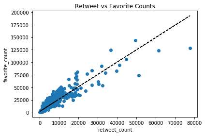

```python
%matplotlib inline

x=df_master_clean['retweet_count']
y=df_master_clean['favorite_count']

# regression line
fit = np.polyfit(x,y,1)
fit_fn = np.poly1d(fit)

plt.plot(x, y, "o", x, fit_fn(x), "--k")
plt.title('Retweet vs Favorite Counts')
plt.xlabel('retweet_count')
plt.ylabel('favorite_count')
plt.tight_layout()
plt.savefig('retweet_vs_favorite.png', dpi=200)
```

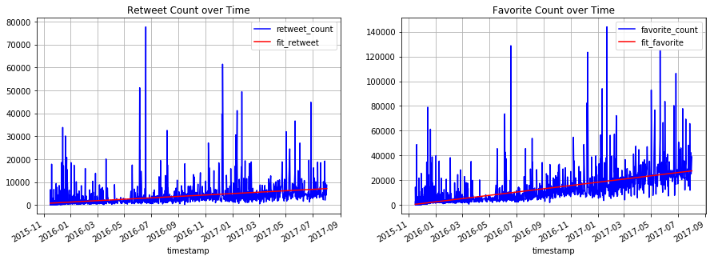

```python
#convert timestamp to a representative number
ts = (df_master_clean['timestamp'] - np.datetime64('1970-01-01T00:00:00Z')) / np.timedelta64(1, 's')

# create linear regression
fit_retweet = np.polyfit(ts,df_master_clean.retweet_count,1)
fit_favorite = np.polyfit(ts,df_master_clean.favorite_count,1)
fit_retweet_fn = np.poly1d(fit_retweet)
fit_favorite_fn = np.poly1d(fit_favorite)

# store regression lines
df_master_clean['fit_retweet'] = fit_retweet_fn(ts)
df_master_clean['fit_favorite'] = fit_favorite_fn(ts)


fig, axes = plt.subplots(nrows=1, ncols=2, figsize=(15,5), sharex=True)

# Plot retweet_count and regression line
df_master_clean.plot(kind='line', color='Blue', x='timestamp', y='retweet_count', ax=axes[0], title='Retweet Count over Time')
df_master_clean.plot(kind='line', color='Red', x='timestamp', y='fit_retweet', ax=axes[0], grid=True)

# Plot favorite_count and regression line
df_master_clean.plot(kind='line', color='Blue', x='timestamp', y='favorite_count', ax=axes[1], title='Favorite Count over Time')
df_master_clean.plot(kind='line', color='Red', x='timestamp', y='fit_favorite', ax=axes[1], grid=True)

#plt.tight_layout()
plt.savefig('retweet_favorite_subplot.png', dpi=200)
plt.show()
```

Each tweet is associated with ratings that have denominators and numerators. The denominators are mostly 10, but there are few with different values. The numerators can be any value but mostly they are between 10 and 13. The plot below highlights Rating Ratio over time. Few tweets were dramatically high in rate. At early time, the ratings were generally low (less than one). As time passes, the ratings were apparently increasing. This can be due to increase of account popularity.

```python
df_master_clean['rating_denominator'].value_counts()
```

```
10.0     1960
50.0     2
80.0     2
150.0    1
120.0    1
110.0    1
40.0     1
90.0     1
170.0    1
70.0     1
Name: rating_denominator, dtype: int64
```

```python
df_master_clean['rating_numerator'].value_counts()
```

```
12.00      446
10.00      418
11.00      394
13.00      254
9.00       150
8.00       95
7.00       51
14.00      34
6.00       32
5.00       32
3.00       19
4.00       15
2.00       9
1.00       4
60.00      1
84.00      1
99.00      1
1776.00    1
13.50      1
11.27      1
165.00     1
11.26      1
0.00       1
9.75       1
45.00      1
88.00      1
144.00     1
44.00      1
121.00     1
204.00     1
80.00      1
420.00     1
Name: rating_numerator, dtype: int64
```

```python
df_master_clean['rating_ratio'].value_counts()
```

```
1.200      450
1.000      419
1.100      399
1.300      254
0.900      151
0.800      95
0.700      51
1.400      34
0.500      32
0.600      32
0.300      19
0.400      15
0.200      9
0.100      4
1.127      1
1.350      1
1.126      1
0.975      1
42.000     1
177.600    1
0.000      1
Name: rating_ratio, dtype: int64
```

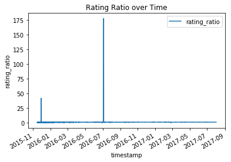

```python
# Plot Rating Ratio over Time
df_master_clean.plot(kind='line', x='timestamp', y='rating_ratio')
plt.title('Rating Ratio over Time')
plt.xlabel('timestamp')
plt.ylabel('rating_ratio')
plt.show()
```

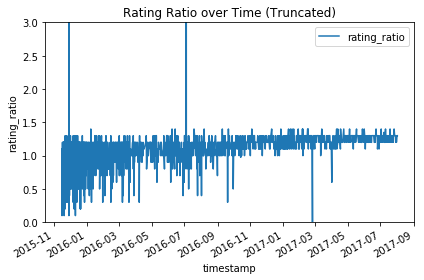

```python
# Plot Rating Ratio over Time, remove ratios beyond a threshold
df_master_clean.plot(kind='line', x='timestamp', y='rating_ratio')
plt.title('Rating Ratio over Time (Truncated)')
plt.xlabel('timestamp')
plt.ylabel('rating_ratio')
plt.ylim(0, 3)
plt.tight_layout()
plt.savefig('rating_ratio_over_time_truncated.png', dpi=200)
plt.show()
```

Dog stage information was mentioned in about 300 tweet's text, including: Pupper, Doggo, Puppo and Floofer. Below pie chart show that Pupper dogs are the most famous with about 67% appearance, Doggo came second by 21%. Four tweets had both doggo and pupper dogs.

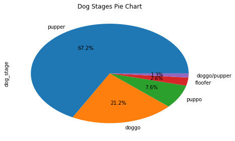

```python
df_master_clean['dog_stage'].value_counts().plot(kind='pie', autopct='%1.1f%%', startangle=0)
plt.title('Dog Stages Pie Chart')
plt.tight_layout()
plt.savefig('dog_stages.png', dpi=200)
```

```python
df_master_clean['dog_stage'].value_counts()
```

```
pupper          203
doggo           64
puppo           23
floofer         8
doggo/pupper    4
Name: dog_stage, dtype: int64
```

A neural network prediction algorithm results was provided for WeRateDogs tweets. Results include top three predictions weather an image is dog or not. If yes, the dog breed was presented along with confidence level. Below, is the top dog breed prediction among three choices with corresponding confidence level for each tweet. 1666 out of 1971 was successfully classified to a dog breed, and the rest where not properly predicted. In below figure, top 10 dog breeds prediction are shown. Golden Retriever and Labrador Retriever are the most common breeds.

```python
print("{} out of {} was successfully classified to a dog breed.".format(df_master_clean.prediction_type.notnull().sum(), df_master_clean.shape[0]))
```

```
1666 out of 1971 was successfully classified to a dog breed.
```

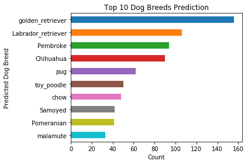

```python
df_master_clean['prediction_type'].value_counts()[0:10].plot(kind = 'barh')
plt.gca().invert_yaxis()
plt.title('Top 10 Dog Breeds Prediction')
plt.xlabel('Count')
plt.ylabel('Predicted Dog Breed')
plt.tight_layout()
plt.savefig('top_10_dog_breed_predictions.png', dpi=200)
```

```python
i = 101
print("Tweet {}'s Text: {}".format(i, df_master_clean['text'][i]))
print("Dog Breed Prediction: ", df_master_clean['prediction_type'][i],
      ", Confidence Level: ", df_master_clean['prediction_confidence'][i])
Image(url= df_master_clean['jpg_url'][i])
```

```
Tweet 101's Text: Here's a h*ckin peaceful boy. Unbothered by the comings and goings. 13/10 please reveal your wise ways https://t.co/yeaH8Ej5eM
Dog Breed Prediction:  Labrador_retriever , Confidence Level:  0.868107
```

[figure not shown]

```python
#Tweet with the highest favorite_count
df_master_clean.loc[df_master_clean.favorite_count==df_master_clean.favorite_count.max(),['text', 'favorite_count','retweet_count']]
```

|  | text | favorite_count | retweet_count |
| --- | --- | --- | --- |
| 306 | Here's a super supportive puppo participating in the Toronto #WomensMarch today. 13/10 https://t.co/nTz3FtorBc | 143931 | 49399 |

```python
#Tweet with the highest retweet_count
df_master_clean.loc[df_master_clean.retweet_count==df_master_clean.retweet_count.max(),['text', 'favorite_count','retweet_count']]
```

|  | text | favorite_count | retweet_count |
| --- | --- | --- | --- |
| 769 | Here's a doggo realizing you can stand in a pool. 13/10 enlightened af (vid by Tina Conrad) https://t.co/7wE9LTEXC4 | 128732 | 77712 |